# ИПС для портфеля акций MOEX: риск-ядро, корпоративные признаки и as-of проверка

Этот ноутбук относится к практической части курсового проекта по ИПС. В работе акции MOEX рассматриваются как набор объектов, для которых сначала описываются рыночные риски, а затем добавляется слой корпоративных характеристик.

Общая логика такая: собирается ценовая панель, рассчитываются логарифмические доходности, изучаются ковариации и корреляции, после этого строится PCA/МГК и несколько оценок матрицы риска. Корпоративные признаки подключаются отдельно и только по правилу as-of. На последнем этапе формируются портфели и проверяются на 2024--2025 годах.

В работе сохраняются несколько важных ограничений. Train-период — 2019--2023, внешний test — 2024--2025. Корпоративная отчётность попадает в расчёт только после даты `available_from`. Портфели являются long-only, поэтому короткие позиции не используются, а отдельные бумаги могут получить нулевой вес.

В качестве риск-ядра используется `MinVar_LW`, то есть портфель минимальной дисперсии на ковариационной матрице Ledoit--Wolf. `CorpTilt_MV` рассматривается как отдельный корпоративный наклон поверх этого ядра. `Final_Recommended_Portfolio` выбирается внутри train по нескольким validation-окнам, а внешний test не участвует в выборе.

Таким образом, ноутбук связывает многомерный анализ доходностей, корпоративные признаки и портфельную оптимизацию. Корреляции и ковариации описывают общий рыночный риск, PCA показывает основные направления совместного движения, корпоративный блок задаёт дополнительный слой релевантности, а итоговые стратегии сравниваются в статическом и rolling out-of-sample режимах.

```python
# Базовые библиотеки
from __future__ import annotations

import os
import json
import math
import time
import warnings
from pathlib import Path
from typing import Dict, Iterable, List, Tuple, Optional

import numpy as np
import pandas as pd
import matplotlib.pyplot as plt

from IPython.display import display, Markdown

warnings.filterwarnings('ignore')
pd.set_option('display.max_columns', 120)
pd.set_option('display.width', 180)
pd.set_option('display.float_format', lambda x: f'{x:,.6f}')

# Проверяем необязательные библиотеки.
try:
    import requests
except ImportError as e:
    raise ImportError('Установите requests: pip install requests') from e

try:
    from sklearn.covariance import LedoitWolf
    from sklearn.linear_model import RidgeCV, LinearRegression
    from sklearn.metrics import r2_score
    SKLEARN_OK = True
except Exception:
    SKLEARN_OK = False
    print('sklearn не найден: LedoitWolf/Ridge будут заменены упрощенными процедурами.')

try:
    from scipy.optimize import minimize
    SCIPY_OK = True
except Exception:
    SCIPY_OK = False
    print('scipy не найден: оптимизация портфелей будет ограничена равными весами.')
```

```python
# =============================
# 1. Конфигурация исследования
# =============================

PROJECT_DIR = Path.cwd()
OUTPUT_DIR = PROJECT_DIR / 'moex_adaptive_ips_outputs'
CACHE_DIR = OUTPUT_DIR / 'moex_cache'
FIG_DIR = OUTPUT_DIR / 'figures'
for p in [OUTPUT_DIR, CACHE_DIR, FIG_DIR]:
    p.mkdir(parents=True, exist_ok=True)

# Ценовой период расширен: train 2019--2023, test 2024--2025.
START_DATE = '2019-01-03'
END_DATE = '2025-12-30'

# Основное разбиение: train 2019--2023, test 2024--2025.
TRAIN_START = '2019-01-03'
TRAIN_END = '2023-12-29'
TEST_START = '2024-01-03'
TEST_END = '2025-12-30'
PORTFOLIO_FORMATION_DATE = TEST_START

ANNUALIZATION = 252
COVERAGE_THRESHOLD = 0.95
MAX_SINGLE_WEIGHT = 0.25       # верхний cap; нижняя граница веса всегда 0%
LOW_LIQUIDITY_MAX_WEIGHT = 0.05
LIQUIDITY_CAP_QUANTILE = 0.33
ALLOW_ZERO_WEIGHTS = True      # бумаги могут получать 0%, если они неэффективны
LONG_ONLY = True               # запрет коротких позиций
RISK_FREE_RATE = 0.0
CVaR_BETA = 0.95
PCA_VARIANCE_THRESHOLD = 0.70
FIXED_K_FACTORS = None

# Rolling-window проверка: каждый квартал обновляются train и веса.
USE_ROLLING_WINDOW = True
ROLLING_MIN_TEST_START = TEST_START
ROLLING_TEST_DAYS = 63
ROLLING_STEP_DAYS = 63
MIN_ROLLING_TRAIN_OBS = 756
TURNOVER_SMOOTHING = 0.10      # 0 = без сглаживания; 0.10 = мягкий штраф на перестройку


# Выбор итогового портфеля: параметры берутся только из train, без test-leakage.
VALIDATION_DAYS = 252
MIN_VALIDATION_DAYS = 126
TARGET_EXCESS_RETURN_OVER_EQUAL = 0.03
HYBRID_SELECTION_WEIGHTS = {
    'sharpe': 0.45,
    'ann_return': 0.25,
    'max_drawdown': 0.20,
    'HHI': 0.10,
}


# Служебное имя ниже оставлено для совместимости с ранними выгрузками.
# Рекомендуемый портфель хранится как отдельная стратегия.
ADAPTIVE_FRAMEWORK_NAME = 'Adaptive_Hybrid_LW_PCA_Corp'
META_FRAMEWORK_PORTFOLIO_NAME = ADAPTIVE_FRAMEWORK_NAME
FINAL_PORTFOLIO_NAME = 'Final_Recommended_Portfolio'

# Multi-window validation внутри train. Эти годы используются как псевдо-test,
# чтобы не подбирать итоговый вариант по одному короткому отрезку.
INTERNAL_VALIDATION_YEARS = [2021, 2022, 2023]
MIN_INTERNAL_VALIDATION_TRAIN_OBS = 252
MIN_INTERNAL_VALIDATION_TEST_OBS = 40
ADAPTIVE_SELECTOR_MIN_SCORE_IMPROVEMENT = 1e-12
ADAPTIVE_SELECTOR_FORCE_CORPTILT_IF_BEATS_LW = True
EXPECTED_STATIC_CORP_YEARS = {2019, 2020, 2021, 2022}
FORCE_CORPTILT_IF_IT_BEATS_LW_ON_INTERNAL_VALIDATION = ADAPTIVE_SELECTOR_FORCE_CORPTILT_IF_BEATS_LW

# Индексы для внешнего сравнения
INDEX_BENCHMARKS = {
    'IMOEX': 'Индекс МосБиржи',
    'MOEXBMI': 'Индекс широкого рынка МосБиржи',
}

# Корпоративный блок: annual CSV с фактической датой доступности отчетности.
CORP_FEATURES_ANNUAL_PATH = PROJECT_DIR / 'corporate_features_annual_2019_2024_asof.csv'
CORP_PANEL_START_YEAR = 2019
CORP_PANEL_END_YEAR = 2024     # 2024 нужен для тестовых окон второй половины 2025 года
REPORT_AVAILABILITY_MONTH = 7  # консервативно: годовой отчет Y доступен с 1 июля Y+1
REPORT_AVAILABILITY_DAY = 1
MIN_CORP_FEATURE_COVERAGE = 0.20
CORP_RAW_FEATURE_COLUMNS = ['market_cap', 'pe', 'pb', 'roe', 'debt_equity', 'netdebt_ebitda', 'dividend_yield', 'free_float']
# Берём признаки с приемлемым покрытием; market_cap используется как log_market_cap.
CORP_MODEL_FEATURE_COLUMNS = ['log_market_cap', 'pe', 'pb', 'roe', 'debt_equity', 'netdebt_ebitda', 'dividend_yield', 'free_float']

# Для финальной курсовой False: не подменяем фундаментальные данные рыночными прокси.
ALLOW_MARKET_PROXY_Z = False

CANDIDATE_TICKERS = [
    'SBER', 'VTBR', 'MOEX',
    'GAZP', 'LKOH', 'ROSN', 'NVTK', 'TATN', 'SNGS',
    'GMKN', 'PLZL', 'ALRS', 'NLMK', 'MAGN', 'CHMF', 'RUAL',
    'IRAO', 'HYDR', 'FEES',
    'MTSS', 'RTKM', 'AFKS',
    'MGNT', 'AFLT',
    'PHOR'
]
# Порядок тикеров зафиксирован, чтобы все выводы кода были идентичны тексту КР
REFERENCE_TICKER_ORDER = ['AFKS', 'MAGN', 'SNGS', 'SBER', 'RTKM', 'ROSN', 'NLMK', 'AFLT', 'MGNT', 'MOEX', 'LKOH', 'HYDR', 'GAZP', 'CHMF', 'ALRS', 'MTSS', 'IRAO', 'PHOR', 'TATN', 'GMKN', 'NVTK', 'RUAL', 'VTBR', 'PLZL', 'FEES']


SECTOR_MAP = {
    'SBER': 'Банки/финансы', 'VTBR': 'Банки/финансы', 'MOEX': 'Банки/финансы',
    'GAZP': 'Нефть и газ', 'LKOH': 'Нефть и газ', 'ROSN': 'Нефть и газ', 'NVTK': 'Нефть и газ', 'TATN': 'Нефть и газ', 'SNGS': 'Нефть и газ',
    'GMKN': 'Металлы/добыча', 'PLZL': 'Металлы/добыча', 'ALRS': 'Металлы/добыча', 'NLMK': 'Металлы/добыча', 'MAGN': 'Металлы/добыча', 'CHMF': 'Металлы/добыча', 'RUAL': 'Металлы/добыча',
    'IRAO': 'Электроэнергетика', 'HYDR': 'Электроэнергетика', 'FEES': 'Электроэнергетика',
    'MTSS': 'Телеком/холдинги', 'RTKM': 'Телеком/холдинги', 'AFKS': 'Телеком/холдинги',
    'MGNT': 'Потребление/транспорт', 'AFLT': 'Потребление/транспорт',
    'PHOR': 'Химия'
}

print(f'Кандидатный пул: {len(CANDIDATE_TICKERS)} тикеров')
print(f'Период цен: {START_DATE} -- {END_DATE}')
print(f'Основное обучение: {TRAIN_START} -- {TRAIN_END}')
print(f'Основной test / out-of-sample: {TEST_START} -- {TEST_END}')
print(f'Дата формирования статического портфеля: {PORTFOLIO_FORMATION_DATE}')
print(f'Корпоративный CSV: {CORP_FEATURES_ANNUAL_PATH.name}')
print(f'Правило as-of: отчетность за год Y доступна с {REPORT_AVAILABILITY_DAY:02d}.{REPORT_AVAILABILITY_MONTH:02d}.Y+1, если available_from не задан вручную')
print(f'Нулевые веса разрешены: {ALLOW_ZERO_WEIGHTS}')
print(f'Rolling-window включен: {USE_ROLLING_WINDOW}; test-окна начинаются не раньше {ROLLING_MIN_TEST_START}')
print(f'Папка выходов: {OUTPUT_DIR.resolve()}')
```

```
Кандидатный пул: 25 тикеров
Период цен: 2019-01-03 -- 2025-12-30
Основное обучение: 2019-01-03 -- 2023-12-29
Основной test / out-of-sample: 2024-01-03 -- 2025-12-30
Дата формирования статического портфеля: 2024-01-03
Корпоративный CSV: corporate_features_annual_2019_2024_asof.csv
Правило as-of: отчетность за год Y доступна с 01.07.Y+1, если available_from не задан вручную
Нулевые веса разрешены: True
Rolling-window включен: True; test-окна начинаются не раньше 2024-01-03
Папка выходов: E:\Users\ermoi\iCloudDrive\Жизнь\Учеба\2 курс предметы\ИПС\moex_adaptive_ips_outputs
```

## 2. Загрузка дневных OHLCV с MOEX ISS

В этом блоке загружаются дневные свечи MOEX ISS по выбранным тикерам. На выходе получается длинная таблица с датой, тикером, OHLC-ценами, объёмом и денежным оборотом.

Период цен взят с 2019 года до конца 2025 года. Это нужно, чтобы отдельно держать train-период 2019--2023 и внешний test 2024--2025. Для повторных запусков используется локальный кэш по тикерам: после первой загрузки данные можно пересчитывать без обращения к MOEX ISS.

```python
def _normalize_moex_candles(df: pd.DataFrame, ticker: str) -> pd.DataFrame:
    """Приводит ответ MOEX candles к единому виду."""
    if df.empty:
        return df
    df = df.copy()
    df.columns = [c.lower() for c in df.columns]
    date_col = 'begin' if 'begin' in df.columns else ('date' if 'date' in df.columns else None)
    if date_col is None:
        raise ValueError(f'В ответе MOEX по {ticker} не найден столбец даты')
    df['date'] = pd.to_datetime(df[date_col]).dt.normalize()
    keep = ['date', 'open', 'high', 'low', 'close', 'volume', 'value']
    existing = [c for c in keep if c in df.columns]
    df = df[existing]
    df['ticker'] = ticker
    for c in ['open', 'high', 'low', 'close', 'volume', 'value']:
        if c in df.columns:
            df[c] = pd.to_numeric(df[c], errors='coerce')
    return df[['date', 'ticker'] + [c for c in ['open', 'high', 'low', 'close', 'volume', 'value'] if c in df.columns]]


def fetch_moex_daily_candles(ticker: str, start_date: str, end_date: str, pause: float = 0.15) -> pd.DataFrame:
    """Загружает дневные свечи по тикеру с учетом пагинации MOEX ISS."""
    rows = []
    start = 0
    session = requests.Session()
    base_url = f'https://iss.moex.com/iss/engines/stock/markets/shares/securities/{ticker}/candles.json'
    while True:
        params = {
            'from': start_date,
            'till': end_date,
            'interval': 24,
            'start': start,
            'iss.meta': 'off'
        }
        r = session.get(base_url, params=params, timeout=30)
        r.raise_for_status()
        data = r.json()
        candles = data.get('candles', {})
        columns = candles.get('columns', [])
        values = candles.get('data', [])
        if not values:
            break
        part = pd.DataFrame(values, columns=columns)
        rows.append(part)
        start += len(part)
        # обычно MOEX отдает порциями; если пришло меньше 500, вероятно, конец
        if len(part) < 500:
            break
        time.sleep(pause)
    if not rows:
        return pd.DataFrame()
    out = pd.concat(rows, ignore_index=True)
    out = _normalize_moex_candles(out, ticker)
    out = out.drop_duplicates(['date', 'ticker']).sort_values('date')
    return out


def load_or_download_ticker(ticker: str, start_date: str, end_date: str, force_download: bool = False) -> pd.DataFrame:
    cache_path = CACHE_DIR / f'{ticker}_daily.csv'
    if cache_path.exists() and not force_download:
        df = pd.read_csv(cache_path, parse_dates=['date'])
        return df
    df = fetch_moex_daily_candles(ticker, start_date, end_date)
    if df.empty:
        print(f'Предупреждение: по {ticker} не получены данные')
        return df
    df.to_csv(cache_path, index=False)
    return df


def load_moex_universe(tickers: List[str], force_download: bool = False) -> pd.DataFrame:
    frames = []
    failed = []
    for i, ticker in enumerate(tickers, 1):
        try:
            df = load_or_download_ticker(ticker, START_DATE, END_DATE, force_download=force_download)
            if df.empty:
                failed.append(ticker)
            else:
                frames.append(df)
                print(f'{i:02d}/{len(tickers)} {ticker}: {len(df)} строк')
        except Exception as e:
            failed.append(ticker)
            print(f'{i:02d}/{len(tickers)} {ticker}: ошибка загрузки: {e}')
    if not frames:
        raise RuntimeError('Не удалось загрузить ни одного тикера. Проверьте интернет или локальный кэш.')
    raw = pd.concat(frames, ignore_index=True)
    raw = raw.drop_duplicates(['date', 'ticker']).sort_values(['ticker', 'date'])
    raw.to_csv(OUTPUT_DIR / 'moex_ohlcv_long_raw.csv', index=False)
    if failed:
        pd.Series(failed, name='failed_ticker').to_csv(OUTPUT_DIR / 'failed_tickers.csv', index=False)
        print('Не загружены тикеры:', ', '.join(failed))
    return raw
```

```python
# Запуск загрузки.
# force_download=False означает: использовать кэш, если он уже есть.

raw_ohlcv = load_moex_universe(CANDIDATE_TICKERS, force_download=False)
print(raw_ohlcv.shape)
display(raw_ohlcv.head())
```

```
01/25 SBER: 1819 строк
02/25 VTBR: 1815 строк
03/25 MOEX: 1819 строк
04/25 GAZP: 1819 строк
05/25 LKOH: 1819 строк
06/25 ROSN: 1819 строк
07/25 NVTK: 1815 строк
08/25 TATN: 1817 строк
09/25 SNGS: 1819 строк
10/25 GMKN: 1815 строк
11/25 PLZL: 1812 строк
12/25 ALRS: 1819 строк
13/25 NLMK: 1819 строк
14/25 MAGN: 1819 строк
15/25 CHMF: 1819 строк
16/25 RUAL: 1815 строк
17/25 IRAO: 1817 строк
18/25 HYDR: 1819 строк
19/25 FEES: 1805 строк
20/25 MTSS: 1818 строк
21/25 RTKM: 1819 строк
22/25 AFKS: 1819 строк
23/25 MGNT: 1819 строк
24/25 AFLT: 1819 строк
25/25 PHOR: 1817 строк
(45431, 8)
```

|  | date | ticker | open | high | low | close | volume | value |
| --- | --- | --- | --- | --- | --- | --- | --- | --- |
| 38157 | 2019-01-03 | AFKS | 8.030000 | 8.049000 | 7.961000 | 8.043000 | 4068900 | 32,593,754.400000 |
| 38158 | 2019-01-04 | AFKS | 8.043000 | 8.240000 | 8.022000 | 8.240000 | 5785000 | 47,043,900.400000 |
| 38159 | 2019-01-08 | AFKS | 8.245000 | 8.270000 | 8.160000 | 8.182000 | 4758800 | 39,005,411.000000 |
| 38160 | 2019-01-09 | AFKS | 8.207000 | 8.348000 | 8.184000 | 8.301000 | 8995100 | 74,525,599.600000 |
| 38161 | 2019-01-10 | AFKS | 8.301000 | 8.355000 | 8.200000 | 8.326000 | 7499400 | 62,142,663.100000 |

## 3. Фильтрация покрытия и матрица доходностей

Дальше проверяется полнота ценовых рядов. Бумага остаётся в выборке, если по ней есть не менее 95% дат относительно общего торгового календаря. После этого цены синхронизируются по датам, и по ним рассчитываются логарифмические доходности.

Этот шаг важен для всей дальнейшей части: ковариации, корреляции, PCA и портфельные веса должны строиться на одной и той же согласованной матрице доходностей.

```python
def build_close_matrix(raw: pd.DataFrame, coverage_threshold: float = 0.95) -> Tuple[pd.DataFrame, pd.DataFrame]:
    close = raw.pivot_table(index='date', columns='ticker', values='close', aggfunc='last').sort_index()
    close = close.loc[(close.index >= pd.to_datetime(START_DATE)) & (close.index <= pd.to_datetime(END_DATE))]
    coverage = close.notna().mean().rename('coverage').to_frame()
    coverage['sector'] = coverage.index.map(SECTOR_MAP)
    coverage['n_obs'] = close.notna().sum()

    eligible = coverage.index[coverage['coverage'] >= coverage_threshold].tolist()
    preferred = [t for t in REFERENCE_TICKER_ORDER if t in eligible]
    rest = [t for t in eligible if t not in preferred]
    keep = preferred + rest

    coverage = coverage.loc[keep + [t for t in coverage.index if t not in keep]].copy()
    close_keep = close[keep].copy()
    rows_before = len(close_keep)
    close_keep = close_keep.dropna(how='any')
    rows_after = len(close_keep)
    print(f'Тикеров до фильтра: {close.shape[1]}')
    print(f'Тикеров после фильтра покрытия >= {coverage_threshold:.0%}: {len(keep)}')
    print(f'Дат до синхронизации: {rows_before}; после удаления строк с пропусками: {rows_after}')
    coverage.to_csv(OUTPUT_DIR / 'coverage_by_ticker.csv')
    close_keep.to_csv(OUTPUT_DIR / 'close_matrix.csv')
    return close_keep, coverage


def compute_log_returns(close: pd.DataFrame) -> pd.DataFrame:
    rets = np.log(close / close.shift(1)).dropna(how='any')
    rets.to_csv(OUTPUT_DIR / 'log_returns.csv')
    return rets

close = None
coverage = None
returns = None
close, coverage = build_close_matrix(raw_ohlcv, COVERAGE_THRESHOLD)
returns = compute_log_returns(close)

# Разбиение на train 2019--2023 и test 2024--2025.
train_returns = returns.loc[
    (returns.index >= pd.to_datetime(TRAIN_START)) &
    (returns.index <= pd.to_datetime(TRAIN_END))
].copy()

test_returns = returns.loc[
    (returns.index >= pd.to_datetime(TEST_START)) &
    (returns.index <= pd.to_datetime(TEST_END))
].copy()

summary = pd.DataFrame({
    'metric': [
        'tickers_after_filter', 'price_dates', 'return_dates',
        'train_observations', 'test_observations',
        'price_start_date', 'price_end_date',
        'train_start', 'train_end', 'test_start', 'test_end'
    ],
    'value': [
        returns.shape[1], close.shape[0], returns.shape[0],
        train_returns.shape[0], test_returns.shape[0],
        str(returns.index.min().date()), str(returns.index.max().date()),
        TRAIN_START, TRAIN_END, TEST_START, TEST_END
    ]
})
summary.to_csv(OUTPUT_DIR / 'data_summary.csv', index=False, encoding='utf-8-sig')

display(summary)
display(coverage.head(30))

if train_returns.empty or test_returns.empty:
    raise ValueError('Train или test выборка пуста. Проверьте START_DATE/END_DATE/TRAIN_START/TRAIN_END/TEST_START/TEST_END и загруженные цены.')
```

```
Тикеров до фильтра: 25
Тикеров после фильтра покрытия >= 95%: 25
Дат до синхронизации: 1819; после удаления строк с пропусками: 1777
```

|  | metric | value |
| --- | --- | --- |
| 0 | tickers_after_filter | 25 |
| 1 | price_dates | 1777 |
| 2 | return_dates | 1776 |
| 3 | train_observations | 1226 |
| 4 | test_observations | 550 |
| 5 | price_start_date | 2019-01-04 |
| 6 | price_end_date | 2025-12-30 |
| 7 | train_start | 2019-01-03 |
| 8 | train_end | 2023-12-29 |
| 9 | test_start | 2024-01-03 |
| 10 | test_end | 2025-12-30 |

| ticker | coverage | sector | n_obs |
| --- | --- | --- | --- |
| AFKS | 1.000000 | Телеком/холдинги | 1819 |
| MAGN | 1.000000 | Металлы/добыча | 1819 |
| SNGS | 1.000000 | Нефть и газ | 1819 |
| SBER | 1.000000 | Банки/финансы | 1819 |
| RTKM | 1.000000 | Телеком/холдинги | 1819 |
| ROSN | 1.000000 | Нефть и газ | 1819 |
| NLMK | 1.000000 | Металлы/добыча | 1819 |
| AFLT | 1.000000 | Потребление/транспорт | 1819 |
| MGNT | 1.000000 | Потребление/транспорт | 1819 |
| MOEX | 1.000000 | Банки/финансы | 1819 |
| LKOH | 1.000000 | Нефть и газ | 1819 |
| HYDR | 1.000000 | Электроэнергетика | 1819 |
| GAZP | 1.000000 | Нефть и газ | 1819 |
| CHMF | 1.000000 | Металлы/добыча | 1819 |
| ALRS | 1.000000 | Металлы/добыча | 1819 |
| MTSS | 0.999450 | Телеком/холдинги | 1818 |
| IRAO | 0.998900 | Электроэнергетика | 1817 |
| PHOR | 0.998900 | Химия | 1817 |
| TATN | 0.998900 | Нефть и газ | 1817 |
| GMKN | 0.997801 | Металлы/добыча | 1815 |
| NVTK | 0.997801 | Нефть и газ | 1815 |
| RUAL | 0.997801 | Металлы/добыча | 1815 |
| VTBR | 0.997801 | Банки/финансы | 1815 |
| PLZL | 0.996152 | Металлы/добыча | 1812 |
| FEES | 0.992303 | Электроэнергетика | 1805 |

```python
# Проверка: для большой финальной выборки желательно 20--30 бумаг.
if returns.shape[1] < 20:
    print('ВНИМАНИЕ: после фильтра осталось меньше 20 бумаг. Для финального текста лучше проверить загрузку/порог покрытия/тикерный список.')
else:
    print('Размер выборки соответствует целевому диапазону 20--30 бумаг.')
```

```
Размер выборки соответствует целевому диапазону 20--30 бумаг.
```

### Интерпретация

Фильтр покрытия не сократил исходный пул: в расчётах осталось 25 бумаг из 25. После синхронизации сформировано 1777 дат цен и 1776 дневных доходностей. Обучающее окно содержит 1226 наблюдений, тестовое — 550.

Такого объёма достаточно для дальнейшего анализа ковариационной структуры, PCA и портфельных весов, хотя оценки риска всё равно остаются чувствительными к рыночному периоду.

## 4. Описательная статистика доходностей

Здесь рассчитываются базовые характеристики доходностей: годовая средняя доходность, годовая волатильность, минимальный и максимальный дневной результат, асимметрия, эксцесс, дневные VaR и ES.

Эта таблица нужна как первичная проверка данных до оптимизации портфелей. Её не следует читать как прогноз: высокая доходность или высокая волатильность в прошлом не означает, что бумага будет вести себя так же в будущем.

```python
def historical_var_es(x: pd.Series, beta: float = 0.95) -> Tuple[float, float]:
    losses = -x.dropna()
    if len(losses) == 0:
        return np.nan, np.nan
    var = np.quantile(losses, beta)
    tail = losses[losses >= var]
    es = tail.mean() if len(tail) else np.nan
    return var, es


def descriptive_stats(rets: pd.DataFrame) -> pd.DataFrame:
    rows = []
    for t in rets.columns:
        s = rets[t].dropna()
        var95, es95 = historical_var_es(s, 0.95)
        rows.append({
            'ticker': t,
            'sector': SECTOR_MAP.get(t, 'NA'),
            'mean_ann': s.mean() * ANNUALIZATION,
            'vol_ann': s.std(ddof=1) * np.sqrt(ANNUALIZATION),
            'min_day': s.min(),
            'max_day': s.max(),
            'skew': s.skew(),
            'excess_kurtosis': s.kurt(),
            'VaR95_day': var95,
            'ES95_day': es95,
            'n_obs': len(s)
        })
    out = pd.DataFrame(rows).sort_values('vol_ann', ascending=False)
    return out

stats_all = descriptive_stats(returns)
stats_train = descriptive_stats(train_returns)
stats_test = descriptive_stats(test_returns)

stats_all.to_csv(OUTPUT_DIR / 'descriptive_stats_all.csv', index=False)
stats_train.to_csv(OUTPUT_DIR / 'descriptive_stats_train.csv', index=False)
stats_test.to_csv(OUTPUT_DIR / 'descriptive_stats_test.csv', index=False)

display(stats_all.head(15).style.format({
    'mean_ann': '{:.2%}', 'vol_ann': '{:.2%}', 'min_day': '{:.2%}', 'max_day': '{:.2%}',
    'VaR95_day': '{:.2%}', 'ES95_day': '{:.2%}', 'skew': '{:.2f}', 'excess_kurtosis': '{:.2f}'
}))
```

|  | ticker | sector | mean_ann | vol_ann | min_day | max_day | skew | excess_kurtosis | VaR95_day | ES95_day | n_obs |
| --- | --- | --- | --- | --- | --- | --- | --- | --- | --- | --- | --- |
| 22 | VTBR | Банки/финансы | -12.23% | 41.34% | -53.19% | 14.34% | -5.22 | 106.66 | 3.26% | 5.89% | 1776 |
| 12 | GAZP | Нефть и газ | -3.13% | 39.32% | -36.32% | 22.28% | -2.53 | 46.81 | 3.05% | 5.70% | 1776 |
| 7 | AFLT | Потребление/транспорт | -7.95% | 39.09% | -32.72% | 22.09% | -1.39 | 29.27 | 3.38% | 5.73% | 1776 |
| 0 | AFKS | Телеком/холдинги | 7.07% | 39.08% | -33.99% | 11.86% | -1.72 | 23.97 | 3.54% | 5.87% | 1776 |
| 2 | SNGS | Нефть и газ | -2.98% | 38.80% | -34.22% | 17.54% | -1.20 | 29.68 | 3.28% | 5.37% | 1776 |
| 18 | TATN | Нефть и газ | -3.28% | 37.48% | -35.45% | 18.33% | -1.99 | 39.31 | 3.03% | 5.45% | 1776 |
| 20 | NVTK | Нефть и газ | 0.86% | 37.19% | -30.17% | 16.96% | -0.86 | 20.83 | 3.23% | 5.19% | 1776 |
| 21 | RUAL | Металлы/добыча | 1.48% | 36.85% | -17.06% | 14.68% | -0.20 | 6.39 | 3.42% | 5.32% | 1776 |
| 16 | IRAO | Электроэнергетика | -3.55% | 36.60% | -47.14% | 23.30% | -4.03 | 112.12 | 2.72% | 5.16% | 1776 |
| 5 | ROSN | Нефть и газ | -0.57% | 36.44% | -45.11% | 15.67% | -4.56 | 91.47 | 2.89% | 5.22% | 1776 |
| 3 | SBER | Банки/финансы | 6.70% | 36.07% | -45.59% | 12.13% | -5.14 | 98.89 | 2.74% | 5.38% | 1776 |
| 24 | FEES | Электроэнергетика | -10.36% | 35.51% | -32.13% | 16.52% | -1.73 | 31.14 | 3.00% | 5.18% | 1776 |
| 23 | PLZL | Металлы/добыча | 21.42% | 34.52% | -28.26% | 14.56% | -0.97 | 20.14 | 2.95% | 4.73% | 1776 |
| 13 | CHMF | Металлы/добыча | 0.42% | 34.06% | -24.99% | 10.83% | -1.65 | 17.12 | 3.04% | 5.15% | 1776 |
| 8 | MGNT | Потребление/транспорт | -2.44% | 34.05% | -32.85% | 12.40% | -2.26 | 36.44 | 2.87% | 4.91% | 1776 |

### Интерпретация

Описательная статистика показывает заметные различия между бумагами по риску. В верхней части таблицы находятся активы с высокой годовой волатильностью; у части из них также заметны крупные отрицательные дневные наблюдения и асимметрия.

Это объясняет, почему простое равновесное распределение весов используется только как базовый ориентир, а не как единственный вариант портфеля.

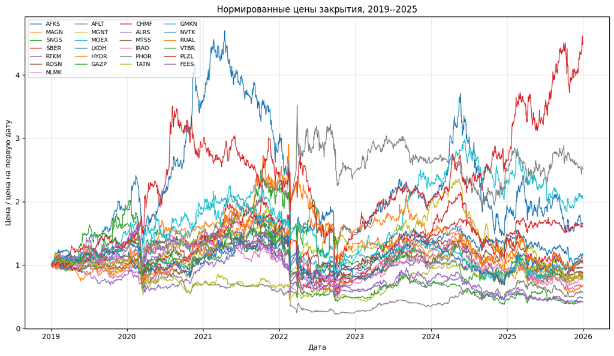

```python
# Нормированные цены закрытия: картинка для текста
norm_close = close / close.iloc[0]
plt.figure(figsize=(12, 7))
for col in norm_close.columns:
    plt.plot(norm_close.index, norm_close[col], linewidth=1.0, label=col)
plt.title('Нормированные цены закрытия, 2019--2025')
plt.xlabel('Дата')
plt.ylabel('Цена / цена на первую дату')
plt.legend(ncol=4, fontsize=8)
plt.grid(True, alpha=0.3)
plt.tight_layout()
plt.savefig(FIG_DIR / 'fig_norm_prices_big.png', dpi=200)
plt.show()
```

## 5. Ковариации, корреляции и МГК/PCA

В этом блоке строятся выборочная ковариационная матрица, корреляционная матрица и PCA на обучающем окне. Все расчёты выполняются только на train-периоде, чтобы не подмешивать информацию из 2024--2025 годов.

В коде PCA/МГК считается через спектральное разложение ковариационной матрицы: используются собственные значения и собственные векторы (`np.linalg.eigh`). Теоретически это связано со стандартным PCA/SVD-представлением для центрированных данных, но явный SVD в практической реализации здесь не вызывается.

Для финансовой интерпретации первая компонента обычно соответствует общему рыночному движению, а следующие компоненты могут отражать более узкие отраслевые или специфические различия.

|  | metric | value |
| --- | --- | --- |
| 0 | mean_pairwise_corr | 0.483715 |
| 1 | median_pairwise_corr | 0.492513 |
| 2 | min_pairwise_corr | 0.078182 |
| 3 | max_pairwise_corr | 0.794343 |

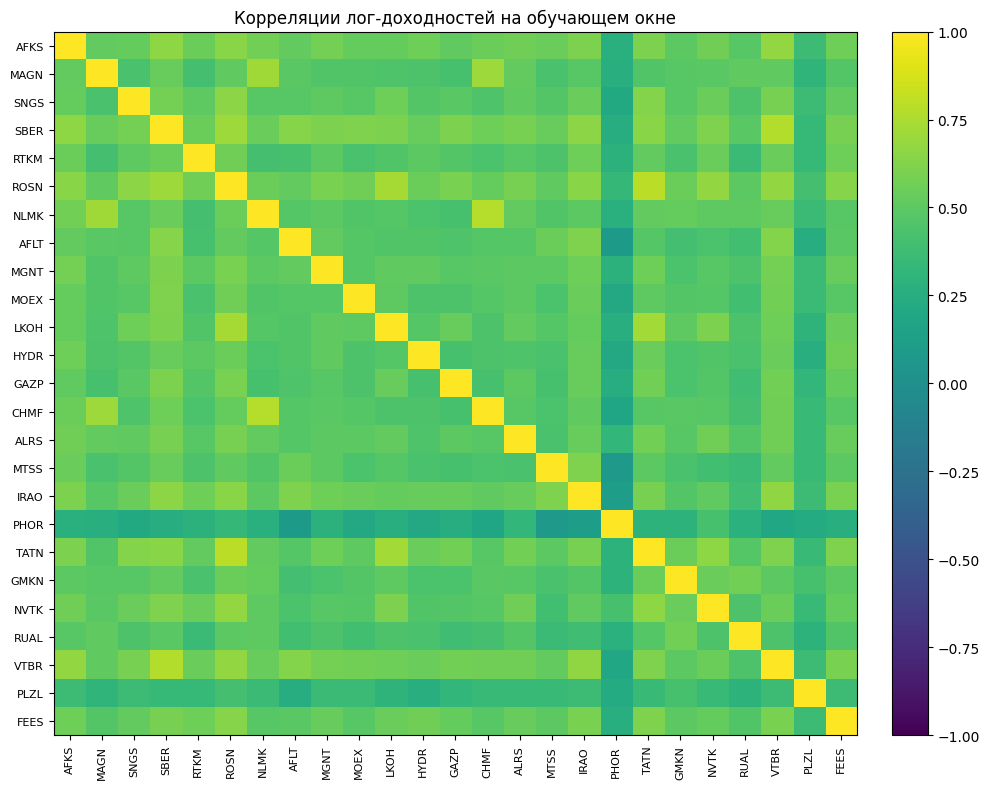

```python
def covariance_and_correlation(rets: pd.DataFrame) -> Tuple[pd.DataFrame, pd.DataFrame]:
    cov = rets.cov()
    corr = rets.corr()
    cov.to_csv(OUTPUT_DIR / 'covariance_train.csv')
    corr.to_csv(OUTPUT_DIR / 'correlation_train.csv')
    return cov, corr

cov_train, corr_train = covariance_and_correlation(train_returns)

# Сводные характеристики корреляций без диагонали
corr_values = corr_train.values[np.triu_indices_from(corr_train.values, k=1)]
corr_summary = pd.DataFrame({
    'metric': ['mean_pairwise_corr', 'median_pairwise_corr', 'min_pairwise_corr', 'max_pairwise_corr'],
    'value': [np.nanmean(corr_values), np.nanmedian(corr_values), np.nanmin(corr_values), np.nanmax(corr_values)]
})
corr_summary.to_csv(OUTPUT_DIR / 'correlation_summary.csv', index=False)
display(corr_summary)

plt.figure(figsize=(10, 8))
im = plt.imshow(corr_train.values, vmin=-1, vmax=1, aspect='auto')
plt.colorbar(im, fraction=0.046, pad=0.04)
plt.xticks(range(len(corr_train.columns)), corr_train.columns, rotation=90, fontsize=8)
plt.yticks(range(len(corr_train.index)), corr_train.index, fontsize=8)
plt.title('Корреляции лог-доходностей на обучающем окне')
plt.tight_layout()
plt.savefig(FIG_DIR / 'fig_corr_heatmap_big.png', dpi=200)
plt.show()
```

```
Выбрано факторов K = 6
```

|  | component | eigenvalue | explained_share | cumulative_share |
| --- | --- | --- | --- | --- |
| 0 | PC1 | 0.00696593 | 53.17% | 53.17% |
| 1 | PC2 | 0.00061719 | 4.71% | 57.88% |
| 2 | PC3 | 0.00058293 | 4.45% | 62.32% |
| 3 | PC4 | 0.00044149 | 3.37% | 65.69% |
| 4 | PC5 | 0.00037781 | 2.88% | 68.58% |
| 5 | PC6 | 0.00035496 | 2.71% | 71.29% |
| 6 | PC7 | 0.00034329 | 2.62% | 73.91% |
| 7 | PC8 | 0.00031903 | 2.43% | 76.34% |
| 8 | PC9 | 0.00028589 | 2.18% | 78.52% |
| 9 | PC10 | 0.00026796 | 2.05% | 80.57% |

| ticker | PC1 | PC2 | PC3 | PC4 | PC5 | PC6 |
| --- | --- | --- | --- | --- | --- | --- |
| AFKS | 0.229530 | 0.050886 | -0.074821 | -0.003778 | 0.058292 | -0.103685 |
| MAGN | 0.171605 | -0.050416 | -0.441508 | 0.144591 | 0.086274 | -0.100158 |
| SNGS | 0.236425 | -0.073331 | 0.201985 | -0.106330 | -0.519220 | 0.007982 |
| SBER | 0.257421 | 0.159252 | 0.052210 | 0.121694 | 0.132948 | -0.026915 |
| RTKM | 0.134032 | -0.008109 | 0.059300 | -0.066419 | 0.025062 | -0.053422 |

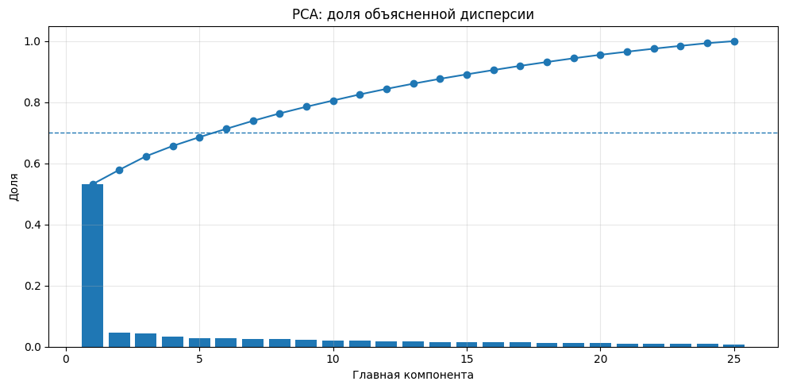

```python
def pca_from_cov(rets: pd.DataFrame, variance_threshold: float = 0.70, fixed_k: Optional[int] = None):
    X = rets - rets.mean(axis=0)
    S = X.cov().values
    eigvals, eigvecs = np.linalg.eigh(S)
    order = np.argsort(eigvals)[::-1]
    eigvals = eigvals[order]
    eigvecs = eigvecs[:, order]
    explained = eigvals / eigvals.sum()
    cumulative = np.cumsum(explained)
    if fixed_k is None:
        k = int(np.searchsorted(cumulative, variance_threshold) + 1)
    else:
        k = int(fixed_k)
    k = max(1, min(k, rets.shape[1]))
    V_k = eigvecs[:, :k].copy()
    pc_cols = [f'PC{i+1}' for i in range(k)]

    # У PCA знак компоненты не уникален; фиксируем его для совпадения графиков с текстовой версией КР.
    sign_ref = {'PC1': 1, 'PC2': 1, 'PC3': -1, 'PC4': -1, 'PC5': 1, 'PC6': -1}
    if 'AFKS' in rets.columns:
        anchor = list(rets.columns).index('AFKS')
        for j, pc in enumerate(pc_cols):
            target = sign_ref.get(pc)
            current = np.sign(V_k[anchor, j])
            if target is not None and current != 0 and current != target:
                V_k[:, j] *= -1

    factors = pd.DataFrame(X.values @ V_k, index=rets.index, columns=pc_cols)
    explained_df = pd.DataFrame({
        'component': [f'PC{i+1}' for i in range(len(eigvals))],
        'eigenvalue': eigvals,
        'explained_share': explained,
        'cumulative_share': cumulative
    })
    loadings = pd.DataFrame(V_k, index=rets.columns, columns=pc_cols)
    # Регрессионные нагрузки B: X = F B^T + E
    F = factors.values
    B_T = np.linalg.pinv(F) @ X.values
    B = pd.DataFrame(B_T.T, index=rets.columns, columns=pc_cols)
    return explained_df, loadings, factors, B, eigvals, eigvecs, k

pca_explained, pca_vectors, factor_returns, factor_loadings_B, eigvals, eigvecs, K_FACTORS = pca_from_cov(
    train_returns, PCA_VARIANCE_THRESHOLD, FIXED_K_FACTORS
)

pca_explained.to_csv(OUTPUT_DIR / 'pca_explained_train.csv', index=False)
pca_vectors.to_csv(OUTPUT_DIR / 'pca_eigenvectors_train.csv')
factor_returns.to_csv(OUTPUT_DIR / 'pca_factor_returns_train.csv')
factor_loadings_B.to_csv(OUTPUT_DIR / 'factor_loadings_B_train.csv')

print(f'Выбрано факторов K = {K_FACTORS}')
display(pca_explained.head(10).style.format({'explained_share': '{:.2%}', 'cumulative_share': '{:.2%}', 'eigenvalue': '{:.8f}'}))
display(factor_loadings_B.head())

plt.figure(figsize=(10, 5))
plt.bar(range(1, len(pca_explained) + 1), pca_explained['explained_share'])
plt.plot(range(1, len(pca_explained) + 1), pca_explained['cumulative_share'], marker='o')
plt.axhline(PCA_VARIANCE_THRESHOLD, linestyle='--', linewidth=1)
plt.title('PCA: доля объясненной дисперсии')
plt.xlabel('Главная компонента')
plt.ylabel('Доля')
plt.grid(True, alpha=0.3)
plt.tight_layout()
plt.savefig(FIG_DIR / 'fig_pca_explained_big.png', dpi=200)
plt.show()
```

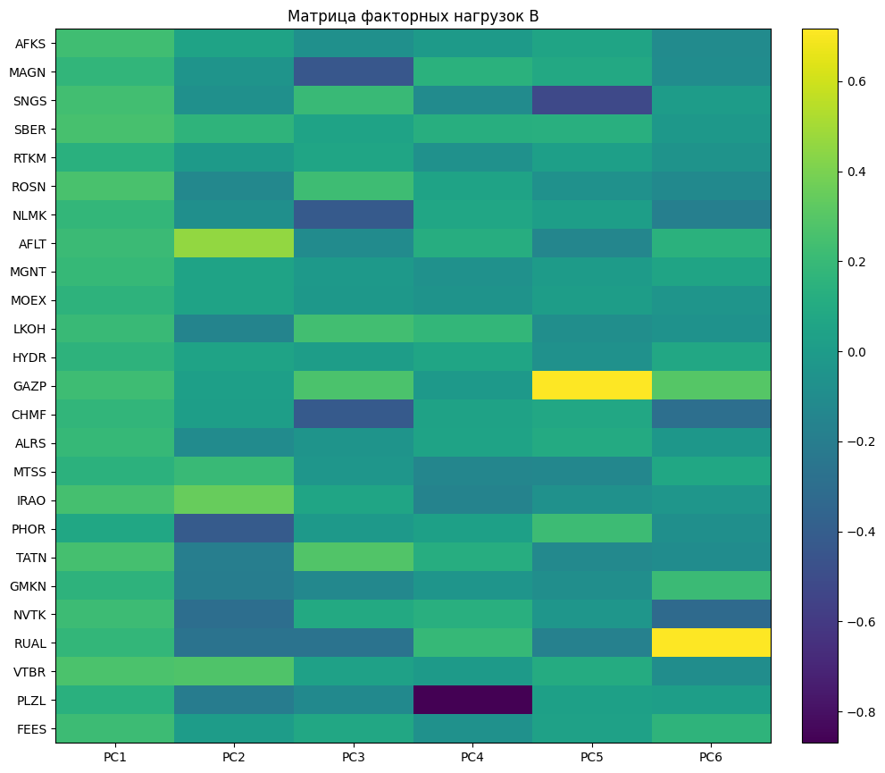

```python
# Тепловая карта регрессионных факторных нагрузок B
plt.figure(figsize=(10, max(5, 0.35 * len(factor_loadings_B))))
im = plt.imshow(factor_loadings_B.values, aspect='auto')
plt.colorbar(im, fraction=0.046, pad=0.04)
plt.xticks(range(factor_loadings_B.shape[1]), factor_loadings_B.columns)
plt.yticks(range(factor_loadings_B.shape[0]), factor_loadings_B.index)
plt.title('Матрица факторных нагрузок B')
plt.tight_layout()
plt.savefig(FIG_DIR / 'fig_factor_loadings_B_big.png', dpi=200)
plt.show()
```

### Интерпретация

Корреляционная структура достаточно плотная: средняя попарная корреляция равна 0.484, медианная — 0.493. Первая PCA-компонента объясняет 53.17% дисперсии доходностей, а первые 6 компонент — 71.29%.

Это говорит о сильном общем рыночном факторе. При этом оставшаяся часть дисперсии важна для портфельной задачи, потому что она связана с различиями между отдельными бумагами и секторами.

## 6. Факторная ковариация и shrinkage Ledoit--Wolf

Здесь сравниваются три оценки матрицы риска: выборочная ковариация, факторная аппроксимация через первые `K` PCA-компонент и ковариация Ledoit--Wolf со shrinkage.

Факторная аппроксимация нужна, чтобы отделить основные направления совместного движения от остаточного шума. Ledoit--Wolf используется как более сглаженная ковариационная оценка по сравнению с чистой sample-матрицей.

Относительная ошибка Фробениуса считается относительно выборочной ковариации train-окна. Это не значит, что sample-матрица является «истинной»; она просто берётся как базовая точка сравнения для текущего набора данных.

```python
def pca_covariance_approx(rets: pd.DataFrame, eigvals: np.ndarray, eigvecs: np.ndarray, k: int) -> pd.DataFrame:
    S = rets.cov().values
    V_k = eigvecs[:, :k]
    Lambda_k = np.diag(eigvals[:k])
    low_rank = V_k @ Lambda_k @ V_k.T
    resid = S - low_rank
    D_eps = np.diag(np.maximum(np.diag(resid), 1e-12))
    S_factor = low_rank + D_eps
    return pd.DataFrame(S_factor, index=rets.columns, columns=rets.columns)


def frobenius_relative_error(A: np.ndarray, B: np.ndarray) -> float:
    return float(np.linalg.norm(A - B, ord='fro') / np.linalg.norm(A, ord='fro'))

cov_factor = pca_covariance_approx(train_returns, eigvals, eigvecs, K_FACTORS)
err_factor = frobenius_relative_error(cov_train.values, cov_factor.values)

if SKLEARN_OK:
    lw = LedoitWolf().fit(train_returns.values)
    cov_lw = pd.DataFrame(lw.covariance_, index=train_returns.columns, columns=train_returns.columns)
    lw_shrinkage = float(lw.shrinkage_)
else:
    # Запасной вариант: 10% сжатие к диагонали.
    S = cov_train.values
    target = np.diag(np.diag(S))
    lw_shrinkage = 0.10
    cov_lw = pd.DataFrame((1 - lw_shrinkage) * S + lw_shrinkage * target, index=train_returns.columns, columns=train_returns.columns)

err_lw = frobenius_relative_error(cov_train.values, cov_lw.values)

cov_factor.to_csv(OUTPUT_DIR / 'covariance_factor_train.csv')
cov_lw.to_csv(OUTPUT_DIR / 'covariance_ledoit_wolf_train.csv')

cov_summary = pd.DataFrame({
    'estimator': ['sample', f'factor_PCA_K{K_FACTORS}', 'Ledoit_Wolf'],
    'relative_frobenius_error_vs_sample': [0.0, err_factor, err_lw],
    'shrinkage': [np.nan, np.nan, lw_shrinkage]
})
cov_summary.to_csv(OUTPUT_DIR / 'covariance_estimators_summary.csv', index=False)
display(cov_summary.style.format({'relative_frobenius_error_vs_sample': '{:.4f}', 'shrinkage': '{:.4f}'}))
```

|  | estimator | relative_frobenius_error_vs_sample | shrinkage |
| --- | --- | --- | --- |
| 0 | sample | 0.0000 | nan |
| 1 | factor_PCA_K6 | 0.0641 | nan |
| 2 | Ledoit_Wolf | 0.0936 | 0.1000 |

### Интерпретация

Факторная аппроксимация через 6 PCA-компонент и оценка Ledoit--Wolf дают более структурированные варианты ковариационной матрицы по сравнению с чистой sample-оценкой.

Ошибка Фробениуса в таблице считается относительно sample covariance, поэтому её нельзя трактовать как ошибку относительно неизвестной истинной матрицы риска. Это скорее техническое сравнение трёх оценок внутри одного train-набора.

## 7. Корпоративные признаки: annual panel и правило as-of

Корпоративные данные берутся из файла `corporate_features_annual_2019_2024_asof.csv`. Ключевая колонка — `available_from`: она задаёт дату, начиная с которой годовая отчётность считается доступной модели.

Если `available_from` не заполнена, отчётность за год `Y` считается доступной с 1 июля `Y+1`. Поэтому при формировании статического портфеля на начало 2024 года модель не использует отчётность за 2023 год, если она ещё не была доступна. В rolling-режиме новые годовые данные подключаются только после наступления соответствующей даты.

В корпоративный блок входят `market_cap`, `pe`, `pb`, `roe`, `netdebt_ebitda`, `dividend_yield`, `free_float`. Капитализация переводится в `log_market_cap`, затем признаки винзоризируются, дозаполняются медианами и стандартизируются. `debt_equity` сохраняется как совместимая колонка, но не используется, если показатель плохо сопоставим между компаниями.

```python
def _read_existing_csv(path: Path, required: bool = True) -> pd.DataFrame:
    """Читает CSV рядом с notebook или из /mnt/data."""
    candidates = [path, Path('/mnt/data') / path.name]
    for p in candidates:
        if p.exists():
            return pd.read_csv(p)
    if required:
        raise FileNotFoundError(
            f'Не найден {path.name}. Положите файл рядом с notebook или укажите CORP_FEATURES_ANNUAL_PATH.'
        )
    return pd.DataFrame()


def default_available_from(year: int) -> pd.Timestamp:
    """Консервативная дата доступности годовой отчетности: 1 июля следующего года."""
    return pd.Timestamp(year=int(year) + 1, month=REPORT_AVAILABILITY_MONTH, day=REPORT_AVAILABILITY_DAY)


def create_corporate_template(path: Path, tickers: List[str]) -> None:
    rows = []
    for t in tickers:
        for y in range(CORP_PANEL_START_YEAR, CORP_PANEL_END_YEAR + 1):
            rows.append({
                'ticker': t,
                'year': y,
                'sector': SECTOR_MAP.get(t, 'NA'),
                'report_date': f'{y}-12-31',
                'available_from': default_available_from(y).date().isoformat(),
                'market_cap': np.nan,
                'pe': np.nan,
                'pb': np.nan,
                'roe': np.nan,
                'debt_equity': np.nan,
                'netdebt_ebitda': np.nan,
                'dividend_yield': np.nan,
                'free_float': np.nan,
                'source_main_url': '',
                'source_metric_urls': '',
                'data_quality_note': 'Заполните из годовой отчетности/проверенного источника.'
            })
    pd.DataFrame(rows).to_csv(path, index=False, encoding='utf-8-sig')
    print(f'Создан шаблон корпоративных данных: {path.resolve()}')


def load_corporate_annual_panel(tickers: List[str]) -> pd.DataFrame:
    if not CORP_FEATURES_ANNUAL_PATH.exists() and not (Path('/mnt/data') / CORP_FEATURES_ANNUAL_PATH.name).exists():
        create_corporate_template(CORP_FEATURES_ANNUAL_PATH, tickers)
    df = _read_existing_csv(CORP_FEATURES_ANNUAL_PATH, required=True).copy()
    df.columns = [c.strip() for c in df.columns]
    if 'ticker' not in df.columns:
        raise ValueError('В корпоративном файле должна быть колонка ticker.')
    df['ticker'] = df['ticker'].astype(str).str.upper().str.strip()
    if 'year' not in df.columns:
        if 'report_date' not in df.columns:
            raise ValueError('В корпоративном файле должна быть колонка year или report_date.')
        df['year'] = pd.to_datetime(df['report_date']).dt.year
    df['year'] = pd.to_numeric(df['year'], errors='coerce').astype('Int64')
    df = df.dropna(subset=['year']).copy()
    df['year'] = df['year'].astype(int)
    if 'report_date' in df.columns:
        df['report_date'] = pd.to_datetime(df['report_date'], errors='coerce')
    else:
        df['report_date'] = pd.to_datetime(df['year'].astype(str) + '-12-31')
    if 'available_from' in df.columns:
        # Записываем fallback-даты только там, где available_from пуст.
        df['available_from'] = pd.to_datetime(df['available_from'], errors='coerce')
    else:
        df['available_from'] = pd.Series(pd.NaT, index=df.index, dtype='datetime64[ns]')
    missing_available = df['available_from'].isna()
    if missing_available.any():
        fallback_available = pd.to_datetime(
            df.loc[missing_available, 'year'].astype(int).map(default_available_from),
            errors='coerce'
        )
        df.loc[missing_available, 'available_from'] = fallback_available.to_numpy()

    for col in CORP_RAW_FEATURE_COLUMNS:
        if col not in df.columns:
            df[col] = np.nan
        df[col] = pd.to_numeric(df[col], errors='coerce')
    if 'sector' not in df.columns:
        df['sector'] = df['ticker'].map(SECTOR_MAP)
    if 'source_main_url' not in df.columns:
        df['source_main_url'] = ''
    if 'source_metric_urls' not in df.columns:
        df['source_metric_urls'] = ''
    if 'data_quality_note' not in df.columns:
        df['data_quality_note'] = ''
    for text_col in ['source_main_url', 'source_metric_urls', 'data_quality_note']:
        df[text_col] = df[text_col].fillna('').astype(str)

    df = df[df['ticker'].isin(tickers)].copy()
    df = df[(df['year'] >= CORP_PANEL_START_YEAR) & (df['year'] <= CORP_PANEL_END_YEAR)].copy()
    df['feature_nonmissing_count'] = df[CORP_RAW_FEATURE_COLUMNS].notna().sum(axis=1)
    df = df.sort_values(['ticker', 'year']).reset_index(drop=True)
    return df


def available_corporate_panel(decision_date: str | pd.Timestamp,
                              tickers: Optional[List[str]] = None,
                              require_any_feature: bool = True) -> pd.DataFrame:
    """Возвращает только те корпоративные строки, которые были доступны на дату решения."""
    if 'corp_annual_raw' not in globals() or corp_annual_raw.empty:
        return pd.DataFrame()
    d = pd.to_datetime(decision_date)
    tickers = list(tickers) if tickers is not None else CANDIDATE_TICKERS
    df = corp_annual_raw[
        (corp_annual_raw['ticker'].isin(tickers)) &
        (corp_annual_raw['available_from'] <= d)
    ].copy()
    if require_any_feature:
        df = df[df['feature_nonmissing_count'] > 0].copy()
    return df.sort_values(['ticker', 'year'])


def _winsorize_series(s: pd.Series, lower: float = 0.01, upper: float = 0.99) -> pd.Series:
    s = s.astype(float)
    if s.notna().sum() < 5:
        return s
    lo, hi = s.quantile([lower, upper])
    return s.clip(lo, hi)


def _raw_model_feature_frame(raw: pd.DataFrame, feature_columns: Optional[List[str]] = None) -> pd.DataFrame:
    """Готовит корпоративные признаки для стандартизации."""
    feature_columns = list(feature_columns) if feature_columns is not None else list(CORP_MODEL_FEATURE_COLUMNS)
    work = pd.DataFrame(index=raw.index)
    if 'log_market_cap' in feature_columns:
        if 'market_cap' in raw.columns:
            work['log_market_cap'] = np.log1p(pd.to_numeric(raw['market_cap'], errors='coerce').clip(lower=0))
        else:
            work['log_market_cap'] = np.nan
    for col in feature_columns:
        if col == 'log_market_cap':
            continue
        work[col] = pd.to_numeric(raw[col], errors='coerce') if col in raw.columns else np.nan
    return work.replace([np.inf, -np.inf], np.nan)
```

```python
def _standardize_feature_frame(work: pd.DataFrame) -> pd.DataFrame:
    coverage = work.notna().mean(axis=0)
    keep_cols = coverage[coverage >= MIN_CORP_FEATURE_COVERAGE].index.tolist()
    work = work[keep_cols].copy()
    if work.empty:
        return work
    med = work.median(axis=0, skipna=True)
    work = work.fillna(med)
    work = work.apply(_winsorize_series, axis=0)
    std = work.std(axis=0, ddof=0).replace(0, np.nan)
    Z_local = (work - work.mean(axis=0)) / std
    Z_local = Z_local.dropna(axis=1, how='all').fillna(0.0)
    return Z_local


def _feature_matrix_from_raw(snapshot: pd.DataFrame) -> pd.DataFrame:
    if snapshot.empty:
        return pd.DataFrame()
    raw = snapshot.set_index('ticker').copy()
    work = _raw_model_feature_frame(raw)
    return _standardize_feature_frame(work)


def build_corporate_panel_Z(corp_annual: pd.DataFrame,
                            tickers: List[str],
                            years: Iterable[int]) -> pd.DataFrame:
    """Строит MultiIndex-матрицу (ticker, year) x features для доступной корпоративной панели."""
    if corp_annual.empty:
        return pd.DataFrame()
    years = sorted({int(y) for y in years})
    panel = corp_annual[
        corp_annual['ticker'].isin(tickers) & corp_annual['year'].isin(years) &
        (corp_annual['feature_nonmissing_count'] > 0)
    ].copy()
    if panel.empty:
        return pd.DataFrame()

    rows = []
    for _, row in panel.iterrows():
        rec = {'ticker': row['ticker'], 'year': int(row['year'])}
        for f in CORP_MODEL_FEATURE_COLUMNS:
            if f == 'log_market_cap':
                rec[f] = np.log1p(max(row.get('market_cap', np.nan), 0)) if pd.notna(row.get('market_cap', np.nan)) else np.nan
            else:
                rec[f] = row.get(f, np.nan)
        rows.append(rec)

    model_panel = pd.DataFrame(rows)
    features = [c for c in CORP_MODEL_FEATURE_COLUMNS if c in model_panel.columns]
    for c in features:
        model_panel[c] = pd.to_numeric(model_panel[c], errors='coerce')

    coverage = model_panel[features].notna().mean(axis=0)
    features = coverage[coverage >= MIN_CORP_FEATURE_COVERAGE].index.tolist()
    if not features:
        return pd.DataFrame()

    global_median = model_panel[features].median(axis=0, skipna=True)
    standardized_parts = []
    for y, part in model_panel.groupby('year', sort=True):
        part = part.copy()
        for f in features:
            med = part[f].median(skipna=True)
            if pd.isna(med):
                med = global_median.get(f, 0.0)
            part[f] = part[f].fillna(med)
            part[f] = _winsorize_series(part[f])
            sd = part[f].std(ddof=0)
            if sd == 0 or pd.isna(sd):
                part[f] = 0.0
            else:
                part[f] = (part[f] - part[f].mean()) / sd
        standardized_parts.append(part[['ticker', 'year'] + features])

    Z_panel = pd.concat(standardized_parts, ignore_index=True)
    Z_panel = Z_panel.set_index(['ticker', 'year']).sort_index()
    Z_panel = Z_panel.replace([np.inf, -np.inf], np.nan).fillna(0.0)
    return Z_panel


def get_corporate_snapshot_for_date(decision_date: str | pd.Timestamp,
                                    tickers: Optional[List[str]] = None) -> Tuple[pd.DataFrame, pd.DataFrame]:
    """Возвращает latest available raw snapshot и стандартизованную Z-матрицу на дату решения."""
    tickers = list(tickers) if tickers is not None else list(train_returns.columns if 'train_returns' in globals() else CANDIDATE_TICKERS)
    df = available_corporate_panel(decision_date, tickers=tickers, require_any_feature=True)
    if df.empty:
        return pd.DataFrame(), pd.DataFrame()
    idx = df.sort_values(['ticker', 'year']).groupby('ticker')['year'].idxmax()
    snapshot = df.loc[idx].copy().sort_values('ticker')
    order = {t: i for i, t in enumerate(tickers)}
    snapshot['_order'] = snapshot['ticker'].map(order)
    snapshot = snapshot.sort_values('_order').drop(columns=['_order'])
    Z_local = _feature_matrix_from_raw(snapshot)
    return snapshot, Z_local


def max_available_corp_year(decision_date: str | pd.Timestamp,
                            tickers: Optional[List[str]] = None) -> Optional[int]:
    df = available_corporate_panel(decision_date, tickers=tickers, require_any_feature=True)
    if df.empty:
        return None
    return int(df['year'].max())


corp_annual_raw = load_corporate_annual_panel(list(train_returns.columns))
corp_annual_raw.to_csv(OUTPUT_DIR / 'corporate_features_annual_loaded_asof.csv', index=False, encoding='utf-8-sig')

# Проверка пропусков в исходных корпоративных данных.
missing_records = []
for idx, row in corp_annual_raw.iterrows():
    for col in CORP_RAW_FEATURE_COLUMNS:
        if pd.isna(row.get(col, np.nan)):
            missing_records.append({
                'row_in_csv_if_header_row_1': int(idx) + 2,
                'ticker': row['ticker'],
                'year': int(row['year']),
                'column': col,
                'available_from': row['available_from']
            })
corp_missing_cells = pd.DataFrame(missing_records)
corp_missing_by_column = corp_annual_raw[CORP_RAW_FEATURE_COLUMNS].isna().sum().sort_values(ascending=False).rename('missing_count').to_frame()
corp_missing_cells.to_csv(OUTPUT_DIR / 'corporate_missing_cells_asof.csv', index=False, encoding='utf-8-sig')
corp_missing_by_column.to_csv(OUTPUT_DIR / 'corporate_missing_by_column_asof.csv', encoding='utf-8-sig')

main_available_corp = available_corporate_panel(PORTFOLIO_FORMATION_DATE, tickers=list(train_returns.columns))
CORP_TRAIN_YEARS_AVAILABLE_MAIN = sorted(main_available_corp['year'].unique().tolist()) if not main_available_corp.empty else []

# Learning panel и scoring snapshot разделены.
# Первая часть обучает веса признаков, вторая даёт текущий score.
corp_panel_for_learning_static = main_available_corp.copy()

if pd.to_datetime(PORTFOLIO_FORMATION_DATE).normalize() == pd.Timestamp(TEST_START).normalize():
    actual_static_years = set(int(y) for y in CORP_TRAIN_YEARS_AVAILABLE_MAIN)
    missing_static_years = EXPECTED_STATIC_CORP_YEARS - actual_static_years
    if missing_static_years:
        raise ValueError(
            'Corporate panel is incomplete for static formation date. '
            f'Missing available corporate years: {sorted(missing_static_years)}. '
            'Check corporate_features_annual_2019_2024_asof.csv, feature values and available_from.'
        )
```

```python
corp_panel_Z = build_corporate_panel_Z(corp_panel_for_learning_static, list(train_returns.columns), CORP_TRAIN_YEARS_AVAILABLE_MAIN)
corp_panel_Z.to_csv(OUTPUT_DIR / 'corporate_Z_panel_standardized_available_at_static_formation.csv', encoding='utf-8-sig')

corp_current_raw, Z = get_corporate_snapshot_for_date(PORTFOLIO_FORMATION_DATE, tickers=list(train_returns.columns))
corp_snapshot_for_scoring_static = corp_current_raw.copy()
corp_current_raw.to_csv(OUTPUT_DIR / f'corporate_features_snapshot_asof_{PORTFOLIO_FORMATION_DATE}.csv', index=False, encoding='utf-8-sig')
Z.to_csv(OUTPUT_DIR / f'corporate_Z_snapshot_asof_{PORTFOLIO_FORMATION_DATE}.csv', encoding='utf-8-sig')
Z.to_csv(OUTPUT_DIR / 'corporate_Z_standardized.csv', encoding='utf-8-sig')

print('Годовая корпоративная таблица:', corp_annual_raw.shape)
print('Corporate learning panel, доступная на дату статического формирования:', corp_panel_for_learning_static.shape)
print('Доступные corporate years на дату статического формирования:', CORP_TRAIN_YEARS_AVAILABLE_MAIN)
print('Корпоративная панель Z на дату статического формирования:', corp_panel_Z.shape)
print('Corporate scoring snapshot для статического test 2024--2025:', corp_snapshot_for_scoring_static.shape)
print('Матрица Z snapshot:', Z.shape)
print('Пропуски по колонкам:')
display(corp_missing_by_column)

if not corp_current_raw.empty:
    display(Markdown(f'### Корпоративные характеристики, snapshot as-of {PORTFOLIO_FORMATION_DATE}'))
    cols_show = ['ticker', 'year', 'available_from', 'sector', 'market_cap', 'pe', 'pb', 'roe', 'netdebt_ebitda', 'dividend_yield', 'free_float']
    display(corp_current_raw[[c for c in cols_show if c in corp_current_raw.columns]].style.format({
        'market_cap': '{:,.1f}', 'pe': '{:.2f}', 'pb': '{:.2f}', 'roe': '{:.1f}',
        'netdebt_ebitda': '{:.2f}', 'dividend_yield': '{:.1f}', 'free_float': '{:.1f}'
    }))
else:
    print('Корпоративный snapshot пуст: проверьте CSV и даты available_from.')

if not Z.empty:
    display(Markdown('### Стандартизованная snapshot-матрица Z'))
    display(Z.style.format('{:+.3f}'))
```

```
Годовая корпоративная таблица: (150, 17)
Corporate learning panel, доступная на дату статического формирования: (100, 17)
Доступные corporate years на дату статического формирования: [2019, 2020, 2021, 2022]
Корпоративная панель Z на дату статического формирования: (100, 7)
Corporate scoring snapshot для статического test 2024--2025: (25, 17)
Матрица Z snapshot: (25, 7)
Пропуски по колонкам:
```

|  | missing_count |
| --- | --- |
| debt_equity | 150 |
| netdebt_ebitda | 15 |
| pe | 2 |
| pb | 2 |
| roe | 2 |
| market_cap | 0 |
| dividend_yield | 0 |
| free_float | 0 |

Корпоративные характеристики, snapshot as-of 2024-01-03

|  | ticker | year | available_from | sector | market_cap | pe | pb | roe | netdebt_ebitda | dividend_yield | free_float |
| --- | --- | --- | --- | --- | --- | --- | --- | --- | --- | --- | --- |
| 3 | AFKS | 2022 | 2023-07-01 00:00:00 | Телеком/холдинги | 114.5 | 5.90 | -0.74 | 18.5 | 3.41 | 3.5 | 33.0 |
| 63 | MAGN | 2022 | 2023-07-01 00:00:00 | Металлы/добыча | 368.3 | 5.25 | 0.69 | 13.1 | -0.46 | 5.3 | 20.0 |
| 135 | SNGS | 2022 | 2023-07-01 00:00:00 | Нефть и газ | 974.8 | 1.05 | 0.20 | 18.7 | -9.39 | 3.7 | 27.0 |
| 129 | SBER | 2022 | 2023-07-01 00:00:00 | Банки/финансы | 3,189.0 | 11.80 | 0.55 | 5.2 | nan | 17.7 | 48.0 |
| 117 | RTKM | 2022 | 2023-07-01 00:00:00 | Телеком/холдинги | 195.5 | 6.30 | 4.11 | 15.5 | 1.60 | 9.7 | 29.0 |
| 111 | ROSN | 2022 | 2023-07-01 00:00:00 | Нефть и газ | 3,856.0 | 4.74 | 0.69 | 15.1 | 0.90 | 10.5 | 11.0 |
| 87 | NLMK | 2022 | 2023-07-01 00:00:00 | Металлы/добыча | 702.4 | 4.23 | 1.18 | 26.6 | -0.04 | 14.2 | 21.0 |
| 9 | AFLT | 2022 | 2023-07-01 00:00:00 | Потребление/транспорт | 97.7 | -2.36 | -1.04 | 45.3 | 4.46 | 0.0 | 25.0 |
| 69 | MGNT | 2022 | 2023-07-01 00:00:00 | Потребление/транспорт | 443.1 | 13.00 | 3.45 | 16.4 | 0.66 | 5.9 | 63.4 |
| 75 | MOEX | 2022 | 2023-07-01 00:00:00 | Банки/финансы | 216.1 | 5.95 | 1.51 | 20.5 | -2.16 | 9.2 | 65.0 |
| 57 | LKOH | 2022 | 2023-07-01 00:00:00 | Нефть и газ | 2,820.0 | 3.57 | 0.74 | 18.1 | -0.39 | 17.0 | 55.0 |
| 45 | HYDR | 2022 | 2023-07-01 00:00:00 | Электроэнергетика | 338.3 | 7.57 | 0.55 | 7.3 | 1.97 | 6.6 | 15.0 |
| 33 | GAZP | 2022 | 2023-07-01 00:00:00 | Нефть и газ | 3,853.0 | 3.14 | 0.25 | 7.8 | 1.07 | 31.4 | 47.0 |
| 21 | CHMF | 2022 | 2023-07-01 00:00:00 | Металлы/добыча | 753.8 | 6.96 | 1.84 | 25.4 | -0.39 | 0.0 | 23.0 |
| 15 | ALRS | 2022 | 2023-07-01 00:00:00 | Металлы/добыча | 433.1 | 4.32 | 1.35 | 31.1 | 0.07 | 0.0 | 34.0 |
| 81 | MTSS | 2022 | 2023-07-01 00:00:00 | Телеком/холдинги | 470.8 | 14.50 | -2.70 | -347.6 | 1.88 | 14.6 | 41.0 |
| 51 | IRAO | 2022 | 2023-07-01 00:00:00 | Электроэнергетика | 355.0 | 3.02 | 0.48 | 14.8 | -2.46 | 8.3 | 32.0 |
| 99 | PHOR | 2022 | 2023-07-01 00:00:00 | Химия | 828.5 | 4.54 | 4.24 | 92.3 | 0.69 | 18.3 | 26.0 |
| 141 | TATN | 2022 | 2023-07-01 00:00:00 | Нефть и газ | 809.3 | 2.84 | 0.74 | 26.0 | -0.34 | 19.3 | 32.0 |
| 39 | GMKN | 2022 | 2023-07-01 00:00:00 | Металлы/добыча | 2,337.0 | 5.82 | 4.87 | 80.2 | 1.09 | 5.7 | 33.0 |
| 93 | NVTK | 2022 | 2023-07-01 00:00:00 | Нефть и газ | 3,258.0 | 9.63 | 1.72 | 17.9 | 0.01 | 9.8 | 21.0 |
| 123 | RUAL | 2022 | 2023-07-01 00:00:00 | Металлы/добыча | 609.5 | 12.30 | 0.89 | 5.7 | 3.17 | 3.0 | 17.6 |
| 147 | VTBR | 2022 | 2023-07-01 00:00:00 | Банки/финансы | 967.4 | -1.45 | 0.65 | 22.3 | nan | 0.0 | 50.0 |
| 105 | PLZL | 2022 | 2023-07-01 00:00:00 | Металлы/добыча | 1,025.0 | 9.17 | 2.85 | 30.0 | 0.85 | 10.7 | 22.3 |
| 27 | FEES | 2022 | 2023-07-01 00:00:00 | Электроэнергетика | 183.7 | 1.44 | 0.15 | 10.3 | 0.73 | 0.0 | 18.2 |

Стандартизованная snapshot-матрица Z

| ticker | log_market_cap | pe | pb | roe | netdebt_ebitda | dividend_yield | free_float |
| --- | --- | --- | --- | --- | --- | --- | --- |
| AFKS | -1.684 | +0.043 | -1.186 | +0.097 | +1.363 | -0.739 | +0.041 |
| MAGN | -0.586 | -0.115 | -0.302 | +0.006 | -0.383 | -0.491 | -0.857 |
| SNGS | +0.333 | -1.135 | -0.605 | +0.100 | -3.660 | -0.711 | -0.373 |
| SBER | +1.452 | +1.476 | -0.389 | -0.126 | +0.136 | +1.218 | +1.078 |
| RTKM | -1.182 | +0.140 | +1.812 | +0.046 | +0.546 | +0.116 | -0.235 |
| ROSN | +1.632 | -0.239 | -0.302 | +0.040 | +0.231 | +0.226 | -1.413 |
| NLMK | +0.023 | -0.363 | +0.001 | +0.232 | -0.193 | +0.736 | -0.788 |
| AFLT | -1.797 | -1.911 | -1.372 | +0.546 | +1.723 | -1.221 | -0.512 |
| MGNT | -0.411 | +1.768 | +1.404 | +0.061 | +0.122 | -0.408 | +2.142 |
| MOEX | -1.088 | +0.055 | +0.205 | +0.130 | -1.150 | +0.047 | +2.226 |
| LKOH | +1.336 | -0.523 | -0.271 | +0.090 | -0.351 | +1.122 | +1.562 |
| HYDR | -0.666 | +0.449 | -0.389 | -0.091 | +0.713 | -0.311 | -1.203 |
| GAZP | +1.631 | -0.628 | -0.574 | -0.083 | +0.307 | +2.706 | +1.009 |
| CHMF | +0.090 | +0.300 | +0.409 | +0.212 | -0.351 | -1.221 | -0.650 |
| ALRS | -0.433 | -0.341 | +0.106 | +0.308 | -0.144 | -1.221 | +0.110 |
| MTSS | -0.354 | +2.044 | -2.151 | -4.617 | +0.673 | +0.791 | +0.594 |
| IRAO | -0.620 | -0.657 | -0.432 | +0.035 | -1.285 | -0.077 | -0.028 |
| PHOR | +0.179 | -0.287 | +1.892 | +1.284 | +0.136 | +1.301 | -0.442 |
| TATN | +0.157 | -0.700 | -0.271 | +0.222 | -0.329 | +1.439 | -0.028 |
| GMKN | +1.159 | +0.023 | +2.188 | +1.130 | +0.316 | -0.435 | +0.041 |
| NVTK | +1.472 | +0.949 | +0.335 | +0.087 | -0.171 | +0.130 | -0.788 |
| RUAL | -0.110 | +1.597 | -0.178 | -0.118 | +1.254 | -0.808 | -1.023 |
| VTBR | +0.326 | -1.743 | -0.327 | +0.160 | +0.136 | -1.221 | +1.216 |
| PLZL | +0.380 | +0.837 | +1.033 | +0.289 | +0.208 | +0.254 | -0.698 |
| FEES | -1.240 | -1.041 | -0.636 | -0.041 | +0.154 | -1.221 | -0.981 |

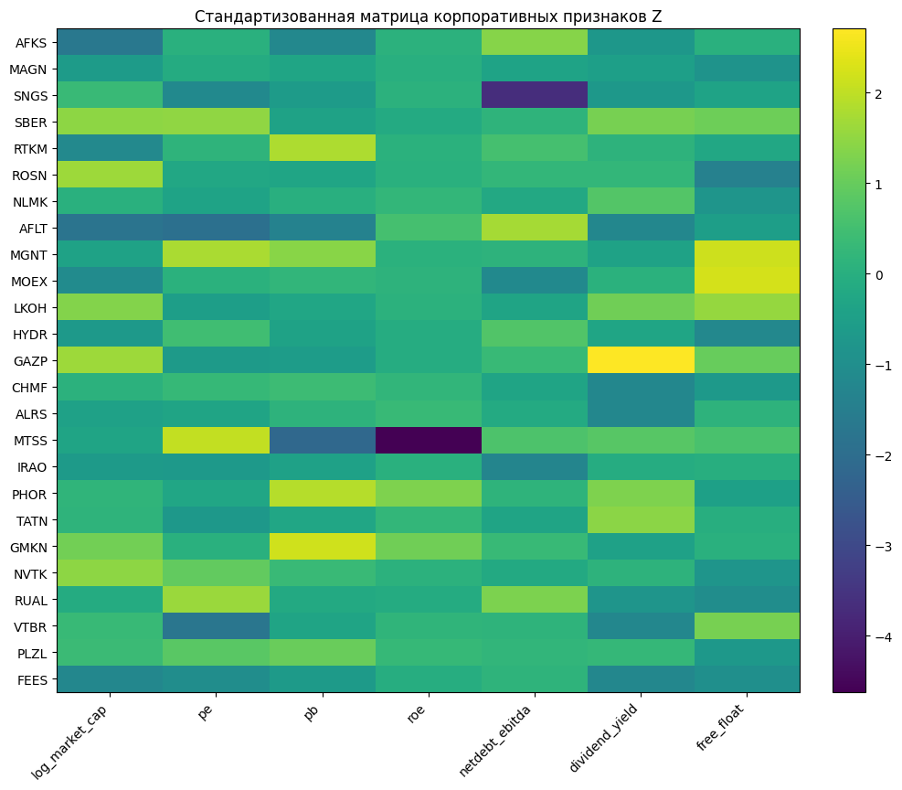

```python
# Визуализация стандартизованных корпоративных признаков
if Z.shape[1] > 0:
    plt.figure(figsize=(10, max(5, 0.35 * len(Z))))
    im = plt.imshow(Z.values, aspect='auto')
    plt.colorbar(im, fraction=0.046, pad=0.04)
    plt.xticks(range(Z.shape[1]), Z.columns, rotation=45, ha='right')
    plt.yticks(range(Z.shape[0]), Z.index)
    plt.title('Стандартизованная матрица корпоративных признаков Z')
    plt.tight_layout()
    plt.savefig(FIG_DIR / 'fig_corporate_Z_big.png', dpi=200)
    plt.show()
```

### Интерпретация

На дату статического формирования портфеля доступна корпоративная панель за 2019--2022 годы и snapshot из 25 эмитентов.

Это соответствует правилу as-of: отчётность за 2023 год не попадает в январский портфель 2024 года, если она ещё не была доступна по дате публикации.

## 8. Корпоративный блок: веса признаков, МГК и связь с рыночными факторами

Корпоративный блок строится по правилу as-of. Ridge-регрессия, корпоративная PCA/МГК и оценка устойчивости признаков используют только те строки annual panel, которые были доступны на дату принятия решения.

Для статического портфеля на начало 2024 года отчётность за 2023 год исключается, если её `available_from` позже даты формирования. В rolling-режиме набор доступных корпоративных данных обновляется вместе с датой нового окна.

Итоговый корпоративный score трактуется как показатель релевантности эмитента для портфельной задачи. Он не заменяет риск-модель, а задаёт наклон весов поверх риск-ядра `MinVar_LW`.

```python
def _normalize_positive(s: pd.Series) -> pd.Series:
    s = pd.Series(s, dtype=float).replace([np.inf, -np.inf], np.nan).fillna(0.0)
    s = s.clip(lower=0)
    total = s.sum()
    if total <= 0:
        return pd.Series(1 / len(s), index=s.index) if len(s) else s
    return s / total


def _standardize_series(s: pd.Series) -> pd.Series:
    s = pd.Series(s, dtype=float)
    sd = s.std(ddof=0)
    if sd == 0 or np.isnan(sd):
        return s * 0
    return (s - s.mean()) / sd


def annual_returns_by_ticker(train_rets: pd.DataFrame) -> pd.DataFrame:
    tmp = train_rets.copy()
    tmp.index = pd.to_datetime(tmp.index)
    annual_log = tmp.groupby(tmp.index.year).sum()
    annual_simple = np.exp(annual_log) - 1
    annual_simple = annual_simple.loc[
        (annual_simple.index >= pd.to_datetime(TRAIN_START).year) &
        (annual_simple.index <= pd.to_datetime(TRAIN_END).year)
    ]
    annual_simple.index.name = 'year'
    out = annual_simple.reset_index().melt(id_vars='year', var_name='ticker', value_name='annual_return')
    out['year'] = out['year'].astype(int)
    return out


def fit_corporate_expected_return(Z_local: pd.DataFrame,
                                  train_rets: pd.DataFrame) -> Tuple[pd.DataFrame, pd.Series, object]:
    """Запасной вариант: Ridge по одному snapshot."""
    tickers = [t for t in train_rets.columns if t in Z_local.index]
    if len(tickers) < 5 or Z_local.shape[1] == 0:
        return pd.DataFrame(), pd.Series(dtype=float, name='mu_corp_ridge'), None
    X = Z_local.loc[tickers].values
    y = (train_rets[tickers].mean() * ANNUALIZATION).astype(float)
    if SKLEARN_OK:
        alphas = np.logspace(-3, 3, 31)
        model = RidgeCV(alphas=alphas, cv=None).fit(X, y.values)
        pred = pd.Series(model.predict(X), index=tickers, name='mu_corp_ridge')
        coef = pd.Series(model.coef_, index=Z_local.columns, name='ridge_coef')
        alpha = getattr(model, 'alpha_', np.nan)
    else:
        lam = 1e-2
        beta = np.linalg.pinv(X.T @ X + lam * np.eye(X.shape[1])) @ X.T @ y.values
        pred = pd.Series(X @ beta, index=tickers, name='mu_corp_ridge')
        coef = pd.Series(beta, index=Z_local.columns, name='ridge_coef')
        model = None
        alpha = lam
    table = pd.DataFrame({
        'feature': coef.index,
        'ridge_coef': coef.values,
        'ridge_abs_weight': _normalize_positive(coef.abs()).values,
        'ridge_alpha': alpha,
        'ridge_source': 'snapshot_fallback'
    }).set_index('feature')
    fit_quality = pd.DataFrame({
        'ticker': tickers,
        'mu_hist_train': y.reindex(tickers).values,
        'mu_corp_ridge': pred.reindex(tickers).values,
        'ridge_residual': y.reindex(tickers).values - pred.reindex(tickers).values
    }).set_index('ticker')
    fit_quality.to_csv(OUTPUT_DIR / 'corporate_return_ridge_fit_snapshot_fallback.csv', encoding='utf-8-sig')
    return table, pred, model


def fit_corporate_expected_return_panel(Z_panel: pd.DataFrame,
                                        train_rets: pd.DataFrame,
                                        Z_snapshot: Optional[pd.DataFrame] = None) -> Tuple[pd.DataFrame, pd.Series, object, pd.DataFrame]:
    """Ridge-регрессия годовых доходностей на доступную annual-панель корпоративных признаков."""
    if Z_panel.empty or Z_panel.shape[1] == 0:
        return pd.DataFrame(), pd.Series(dtype=float, name='mu_corp_ridge'), None, pd.DataFrame()

    annual_ret = annual_returns_by_ticker(train_rets)
    panel = (
        Z_panel.reset_index()
        .merge(annual_ret, on=['ticker', 'year'], how='inner')
        .dropna(subset=['annual_return'])
        .copy()
    )
    features = list(Z_panel.columns)
    if len(panel) < max(10, len(features) + 2):
        return pd.DataFrame(), pd.Series(dtype=float, name='mu_corp_ridge'), None, panel

    X = panel[features].astype(float).values
    y = panel['annual_return'].astype(float).values

    if SKLEARN_OK:
        alphas = np.logspace(-3, 3, 31)
        model = RidgeCV(alphas=alphas, cv=None).fit(X, y)
        pred_panel = model.predict(X)
        coef = pd.Series(model.coef_, index=features, name='ridge_coef')
        alpha = getattr(model, 'alpha_', np.nan)
    else:
        lam = 1e-2
        beta = np.linalg.pinv(X.T @ X + lam * np.eye(X.shape[1])) @ X.T @ y
        pred_panel = X @ beta
        coef = pd.Series(beta, index=features, name='ridge_coef')
        model = None
        alpha = lam

    table = pd.DataFrame({
        'feature': coef.index,
        'ridge_coef': coef.values,
        'ridge_abs_weight': _normalize_positive(coef.abs()).values,
        'ridge_alpha': alpha,
        'ridge_source': 'available_annual_panel'
    }).set_index('feature')

    fit_quality = panel[['ticker', 'year', 'annual_return']].copy()
    fit_quality['mu_corp_ridge_panel'] = pred_panel
    fit_quality['ridge_residual'] = fit_quality['annual_return'] - fit_quality['mu_corp_ridge_panel']
    fit_quality.to_csv(OUTPUT_DIR / 'corporate_panel_ridge_fit_available_asof.csv', index=False, encoding='utf-8-sig')

    if Z_snapshot is None or Z_snapshot.empty:
        return table, pd.Series(dtype=float, name='mu_corp_ridge'), model, fit_quality

    common = [c for c in features if c in Z_snapshot.columns]
    if not common:
        return table, pd.Series(index=Z_snapshot.index, dtype=float, name='mu_corp_ridge'), model, fit_quality

    raw_pred = pd.Series(
        np.asarray(Z_snapshot[common].values) @ coef.reindex(common).fillna(0.0).values,
        index=Z_snapshot.index,
        name='mu_corp_ridge'
    )
    hist_mu = train_rets.mean() * ANNUALIZATION
    pred = raw_pred.reindex(train_rets.columns)
    if pred.notna().sum() > 1 and pred.std(ddof=0) > 0 and hist_mu.std(ddof=0) > 0:
        pred = ((pred - pred.mean()) / pred.std(ddof=0)) * hist_mu.std(ddof=0) + hist_mu.mean()
    else:
        pred = pd.Series(hist_mu.mean(), index=train_rets.columns, name='mu_corp_ridge')
    pred.name = 'mu_corp_ridge'
    return table, pred, model, fit_quality
```

```python
def corporate_pca_from_Z(Z_local: pd.DataFrame, max_components: int = 5) -> Tuple[pd.DataFrame, pd.DataFrame, pd.DataFrame]:
    if Z_local.empty or Z_local.shape[1] == 0:
        return pd.DataFrame(), pd.DataFrame(), pd.DataFrame()
    X = Z_local - Z_local.mean(axis=0)
    S = np.cov(X.values, rowvar=False)
    if np.ndim(S) == 0:
        S = np.array([[float(S)]])
    eigvals, eigvecs = np.linalg.eigh(S)
    order = np.argsort(eigvals)[::-1]
    eigvals, eigvecs = eigvals[order], eigvecs[:, order]
    explained = eigvals / eigvals.sum() if eigvals.sum() > 0 else np.zeros_like(eigvals)
    k = min(max_components, len(eigvals))
    comp_names = [f'CorpPC{i+1}' for i in range(k)]
    loadings = pd.DataFrame(eigvecs[:, :k], index=Z_local.columns, columns=comp_names)
    scores = pd.DataFrame(X.values @ eigvecs[:, :k], index=Z_local.index, columns=comp_names)
    explained_df = pd.DataFrame({
        'component': comp_names,
        'eigenvalue': eigvals[:k],
        'explained_share': explained[:k],
        'cumulative_share': np.cumsum(explained[:k])
    })
    return scores, loadings, explained_df


def regress_loadings_on_Z(B: pd.DataFrame, Z_local: pd.DataFrame) -> Tuple[pd.DataFrame, pd.DataFrame]:
    tickers = [t for t in B.index if t in Z_local.index]
    if len(tickers) < 5 or Z_local.shape[1] == 0:
        return pd.DataFrame(), pd.DataFrame()
    X = Z_local.loc[tickers].values
    coef_rows = []
    r2_rows = []
    for pc in B.columns:
        y = B.loc[tickers, pc].values
        if SKLEARN_OK:
            model = RidgeCV(alphas=np.logspace(-3, 3, 31), cv=None).fit(X, y)
            pred = model.predict(X)
            coef = model.coef_
            alpha = getattr(model, 'alpha_', np.nan)
        else:
            lam = 1e-2
            coef = np.linalg.pinv(X.T @ X + lam * np.eye(X.shape[1])) @ X.T @ y
            pred = X @ coef
            alpha = lam
        ss_res = np.sum((y - pred) ** 2)
        ss_tot = np.sum((y - y.mean()) ** 2)
        r2 = 1 - ss_res / ss_tot if ss_tot > 0 else np.nan
        r2_rows.append({'pc': pc, 'r2': r2, 'alpha': alpha})
        for feature, c in zip(Z_local.columns, coef):
            coef_rows.append({'pc': pc, 'feature': feature, 'coef': c})
    coef_df = pd.DataFrame(coef_rows).pivot(index='feature', columns='pc', values='coef')
    r2_df = pd.DataFrame(r2_rows).set_index('pc')
    return coef_df, r2_df


def build_temporal_stability_weights(corp_annual: pd.DataFrame, model_features: List[str]) -> pd.Series:
    if corp_annual.empty:
        return pd.Series(1 / len(model_features), index=model_features) if model_features else pd.Series(dtype=float)
    rows = []
    for _, row in corp_annual.iterrows():
        rec = {'ticker': row['ticker'], 'year': row['year']}
        for f in model_features:
            if f == 'log_market_cap':
                rec[f] = np.log1p(max(row.get('market_cap', np.nan), 0)) if pd.notna(row.get('market_cap', np.nan)) else np.nan
            else:
                rec[f] = row.get(f, np.nan)
        rows.append(rec)
    panel = pd.DataFrame(rows)
    stability = {}
    for f in model_features:
        if f not in panel.columns:
            stability[f] = 0.0
            continue
        tmp = panel[['ticker', 'year', f]].copy()
        tmp[f] = pd.to_numeric(tmp[f], errors='coerce')
        tmp[f] = tmp.groupby('year')[f].transform(lambda s: s.fillna(s.median()))
        tmp[f] = tmp.groupby('year')[f].transform(_standardize_series)
        st = tmp.groupby('ticker')[f].std(ddof=0).median()
        stability[f] = 1 / (1 + (0 if pd.isna(st) else st))
    return _normalize_positive(pd.Series(stability))


def build_corporate_feature_weights(ridge_table: pd.DataFrame,
                                    corp_pca_loadings: pd.DataFrame,
                                    corp_pca_explained: pd.DataFrame,
                                    corp_annual: pd.DataFrame,
                                    features: Optional[List[str]] = None) -> pd.DataFrame:
    if features is None:
        if 'Z' in globals() and not Z.empty:
            features = list(Z.columns)
        elif not corp_pca_loadings.empty:
            features = list(corp_pca_loadings.index)
        elif not ridge_table.empty:
            features = list(ridge_table.index)
        else:
            features = []
    features = list(features)
    if not features:
        return pd.DataFrame()

    ridge_w = ridge_table['ridge_abs_weight'].reindex(features).fillna(0) if not ridge_table.empty else pd.Series(0, index=features)
    if not corp_pca_loadings.empty and not corp_pca_explained.empty:
        exp = corp_pca_explained.set_index('component')['explained_share'].reindex(corp_pca_loadings.columns).fillna(0)
        pca_w = (corp_pca_loadings.abs() * exp).sum(axis=1)
        pca_w = _normalize_positive(pca_w.reindex(features).fillna(0))
    else:
        pca_w = pd.Series(0, index=features)
    stability_w = build_temporal_stability_weights(corp_annual, features).reindex(features).fillna(0)

    # Сводим Ridge, PCA и устойчивость признаков в один набор весов.
    final = _normalize_positive(0.45 * ridge_w + 0.35 * pca_w + 0.20 * stability_w)
    sign_default = pd.Series({
        'log_market_cap': 1, 'pe': -1, 'pb': -1, 'roe': 1,
        'debt_equity': -1, 'netdebt_ebitda': -1, 'dividend_yield': 1, 'free_float': 1
    })
    ridge_coef = ridge_table['ridge_coef'].reindex(features).fillna(0) if not ridge_table.empty else pd.Series(0, index=features)
    sign = np.sign(ridge_coef)
    sign = sign.mask(sign == 0, sign_default.reindex(features).fillna(1))
    out = pd.DataFrame({
        'ridge_coef': ridge_coef,
        'ridge_abs_weight': ridge_w,
        'corp_pca_weight': pca_w,
        'temporal_stability_weight': stability_w,
        'final_feature_weight': final,
        'sign_for_score': sign.astype(float)
    })
    return out.sort_values('final_feature_weight', ascending=False)


# Основной корпоративный расчет по доступной на дату формирования annual-панели.
corp_return_model, mu_corp_ridge, corp_ridge_model, corp_panel_fit_quality = fit_corporate_expected_return_panel(
    corp_panel_Z,
    train_returns,
    Z_snapshot=Z
)
```

```python
if corp_return_model.empty:
    corp_return_model, mu_corp_ridge, corp_ridge_model = fit_corporate_expected_return(Z, train_returns)
    corp_panel_fit_quality = pd.DataFrame()

corp_pca_base = corp_panel_Z if not corp_panel_Z.empty else Z
corp_pca_scores, corp_pca_loadings, corp_pca_explained = corporate_pca_from_Z(
    corp_pca_base,
    max_components=min(5, max(1, corp_pca_base.shape[1])) if not corp_pca_base.empty else 1
)
corp_loading_coef, corp_loading_r2 = regress_loadings_on_Z(factor_loadings_B, Z)
corp_feature_weights = build_corporate_feature_weights(
    corp_return_model,
    corp_pca_loadings,
    corp_pca_explained,
    corp_annual_raw,
    features=list(Z.columns) if not Z.empty else None
)

# Итоговый корпоративный скоринг компании на as-of snapshot для test 2024--2025.
if not Z.empty and not corp_feature_weights.empty:
    score_vector = (corp_feature_weights['final_feature_weight'] * corp_feature_weights['sign_for_score']).reindex(Z.columns).fillna(0)
    corp_score = (Z @ score_vector).rename('corp_score')
    corp_score = _standardize_series(corp_score)
else:
    corp_score = pd.Series(dtype=float, name='corp_score')

mu_hist_train = (train_returns.mean() * ANNUALIZATION).rename('mu_hist_train')
mu_corp_ridge = mu_corp_ridge.reindex(train_returns.columns) if not mu_corp_ridge.empty else pd.Series(index=train_returns.columns, dtype=float, name='mu_corp_ridge')
mu_corp_score = (mu_hist_train.mean() + corp_score.reindex(train_returns.columns).fillna(0) * mu_hist_train.std(ddof=0)).rename('mu_corp_score')

expected_returns_signals = pd.DataFrame({
    'mu_hist_train': mu_hist_train,
    'mu_corp_ridge': mu_corp_ridge,
    'corp_score': corp_score.reindex(train_returns.columns),
    'mu_corp_score': mu_corp_score,
})
expected_returns_signals['mu_combined_eta_0_5'] = 0.50 * expected_returns_signals['mu_hist_train'] + 0.50 * expected_returns_signals['mu_corp_ridge'].fillna(expected_returns_signals['mu_corp_score'])
expected_returns_signals['mu_combined_eta_stat'] = 0.40 * expected_returns_signals['mu_hist_train'] + 0.35 * expected_returns_signals['mu_corp_ridge'].fillna(expected_returns_signals['mu_corp_score']) + 0.25 * expected_returns_signals['mu_corp_score']

corp_return_model.to_csv(OUTPUT_DIR / 'corporate_ridge_feature_weights_panel_available_asof.csv', encoding='utf-8-sig')
corp_return_model.to_csv(OUTPUT_DIR / 'corporate_ridge_feature_weights.csv', encoding='utf-8-sig')
corp_pca_scores.to_csv(OUTPUT_DIR / 'corporate_pca_scores_panel_available_asof.csv', encoding='utf-8-sig')
corp_pca_loadings.to_csv(OUTPUT_DIR / 'corporate_pca_loadings.csv', encoding='utf-8-sig')
corp_pca_explained.to_csv(OUTPUT_DIR / 'corporate_pca_explained.csv', index=False, encoding='utf-8-sig')
corp_loading_coef.to_csv(OUTPUT_DIR / 'corporate_regression_factor_loadings_coef.csv', encoding='utf-8-sig')
corp_loading_r2.to_csv(OUTPUT_DIR / 'corporate_regression_factor_loadings_r2.csv', encoding='utf-8-sig')
corp_feature_weights.to_csv(OUTPUT_DIR / 'corporate_feature_weights_final.csv', encoding='utf-8-sig')
expected_returns_signals.to_csv(OUTPUT_DIR / 'expected_returns_market_corp_signals.csv', encoding='utf-8-sig')

print('Корпоративные веса признаков рассчитаны:', corp_feature_weights.shape)
print('Ожидаемые доходности/скоринги:', expected_returns_signals.shape)
print('Ridge-оценка признаков основана на панели:', 'Да' if not corp_panel_fit_quality.empty else 'Нет, использован запасной snapshot')
```

```
Корпоративные веса признаков рассчитаны: (7, 6)
Ожидаемые доходности/скоринги: (25, 6)
Ridge-оценка признаков основана на панели: Да
```

```python
display(Markdown('### Итоговые веса корпоративных признаков'))
if corp_feature_weights.empty:
    display(Markdown('Корпоративные веса не рассчитаны: матрица Z пуста.'))
else:
    display(corp_feature_weights.style.format({
        'ridge_coef': '{:+.4f}',
        'ridge_abs_weight': '{:.2%}',
        'corp_pca_weight': '{:.2%}',
        'temporal_stability_weight': '{:.2%}',
        'final_feature_weight': '{:.2%}',
        'sign_for_score': '{:+.0f}'
    }))

if not corp_pca_explained.empty:
    display(Markdown('### Корпоративная МГК/PCA: объясненная дисперсия'))
    display(corp_pca_explained.style.format({'eigenvalue': '{:.4f}', 'explained_share': '{:.2%}', 'cumulative_share': '{:.2%}'}))

if not corp_loading_r2.empty:
    display(Markdown('### Насколько корпоративные признаки объясняют рыночные PCA-нагрузки'))
    display(corp_loading_r2.style.format({'r2': '{:.2%}', 'alpha': '{:.4g}'}))

if not expected_returns_signals.empty:
    display(Markdown('### Сигналы ожидаемой доходности: рынок + корпоративный блок'))
    display(expected_returns_signals.sort_values('mu_combined_eta_stat', ascending=False).style.format({
        'mu_hist_train': '{:.2%}', 'mu_corp_ridge': '{:.2%}', 'corp_score': '{:+.2f}',
        'mu_corp_score': '{:.2%}', 'mu_combined_eta_0_5': '{:.2%}', 'mu_combined_eta_stat': '{:.2%}'
    }))
```

Итоговые веса корпоративных признаков

|  | ridge_coef | ridge_abs_weight | corp_pca_weight | temporal_stability_weight | final_feature_weight | sign_for_score |
| --- | --- | --- | --- | --- | --- | --- |
| pb | +0.0046 | 29.58% | 13.41% | 14.94% | 20.99% | +1 |
| dividend_yield | +0.0034 | 22.10% | 15.88% | 11.35% | 17.77% | +1 |
| netdebt_ebitda | -0.0029 | 18.63% | 14.39% | 14.23% | 16.27% | -1 |
| log_market_cap | +0.0023 | 15.13% | 11.47% | 15.47% | 13.92% | +1 |
| pe | +0.0012 | 7.42% | 15.36% | 12.01% | 11.12% | +1 |
| free_float | -0.0003 | 2.20% | 16.59% | 17.80% | 10.36% | -1 |
| roe | +0.0008 | 4.93% | 12.90% | 14.21% | 9.58% | +1 |

Корпоративная МГК/PCA: объясненная дисперсия

|  | component | eigenvalue | explained_share | cumulative_share |
| --- | --- | --- | --- | --- |
| 0 | CorpPC1 | 1.7117 | 24.21% | 24.21% |
| 1 | CorpPC2 | 1.3027 | 18.42% | 42.63% |
| 2 | CorpPC3 | 1.0126 | 14.32% | 56.95% |
| 3 | CorpPC4 | 0.8921 | 12.62% | 69.57% |
| 4 | CorpPC5 | 0.8330 | 11.78% | 81.35% |

Насколько корпоративные признаки объясняют рыночные PCA-нагрузки

| pc | r2 | alpha |
| --- | --- | --- |
| PC1 | 39.20% | 25.12 |
| PC2 | 54.60% | 10 |
| PC3 | 32.47% | 15.85 |
| PC4 | 0.42% | 1000 |
| PC5 | 2.17% | 1000 |
| PC6 | 0.71% | 1000 |

Сигналы ожидаемой доходности: рынок + корпоративный блок

| ticker | mu_hist_train | mu_corp_ridge | corp_score | mu_corp_score | mu_combined_eta_0_5 | mu_combined_eta_stat |
| --- | --- | --- | --- | --- | --- | --- |
| PHOR | 19.64% | 18.14% | +1.65 | 18.19% | 18.89% | 18.75% |
| PLZL | 14.39% | 11.22% | +1.02 | 12.60% | 12.80% | 12.83% |
| GMKN | 4.50% | 15.28% | +1.29 | 14.96% | 9.89% | 10.89% |
| MGNT | 13.82% | 8.87% | +0.27 | 5.98% | 11.35% | 10.13% |
| NVTK | 5.53% | 11.25% | +1.12 | 13.50% | 8.39% | 9.52% |
| SBER | 7.61% | 10.50% | +0.77 | 10.34% | 9.06% | 9.31% |
| MOEX | 16.61% | 4.91% | -0.27 | 1.21% | 10.76% | 8.67% |
| LKOH | 6.11% | 9.51% | +0.38 | 6.90% | 7.81% | 7.49% |
| ROSN | 6.81% | 6.49% | +0.62 | 9.10% | 6.65% | 7.27% |
| GAZP | 0.42% | 12.39% | +0.76 | 10.34% | 6.41% | 7.09% |
| CHMF | 8.42% | 3.22% | +0.13 | 4.72% | 5.82% | 5.67% |
| SNGS | 0.08% | 8.84% | +0.67 | 9.49% | 4.46% | 5.50% |
| NLMK | 2.59% | 6.89% | +0.49 | 7.94% | 4.74% | 5.43% |
| TATN | -0.62% | 8.15% | +0.47 | 7.78% | 3.76% | 4.55% |
| RTKM | -1.30% | 8.42% | +0.41 | 7.24% | 3.56% | 4.24% |
| HYDR | 7.74% | -2.26% | -0.39 | 0.17% | 2.74% | 2.35% |
| MAGN | 3.98% | 0.29% | -0.20 | 1.82% | 2.13% | 2.15% |
| IRAO | -0.05% | 2.85% | -0.10 | 2.67% | 1.40% | 1.64% |
| RUAL | 2.17% | -2.01% | -0.28 | 1.15% | 0.08% | 0.45% |
| AFKS | 14.57% | -12.82% | -1.78 | -12.12% | 0.88% | -1.69% |
| ALRS | -7.48% | -1.09% | -0.54 | -1.19% | -4.28% | -3.67% |
| MTSS | 0.67% | -8.20% | -1.61 | -10.59% | -3.76% | -5.25% |
| VTBR | -8.45% | -4.34% | -1.22 | -7.18% | -6.39% | -6.69% |
| FEES | -6.21% | -8.23% | -1.22 | -7.17% | -7.22% | -7.16% |
| AFLT | -21.86% | -18.57% | -2.46 | -18.12% | -20.21% | -19.77% |

### Интерпретация

Наибольшие итоговые веса в корпоративном блоке получили `pb`, `dividend_yield` и `netdebt_ebitda`.

Эти веса не являются самостоятельным прогнозом цены. В данном ноутбуке они используются как слой корпоративной релевантности, который затем соединяется с риск-ядром. Связь с рыночными PCA-факторами читается как статистическая взаимосвязь, а не как доказанный причинный эффект.

## 9. Портфельные стратегии и итоговая модель

В этом блоке строятся портфельные стратегии, которые затем сравниваются между собой. Корпоративная релевантность используется вместе с риск-моделью, но не должна механически ухудшать результат относительно риск-ядра.

Сначала задаются ограничения на веса и базовые риск-стратегии: `Equal`, `MinVar_sample`, `MinVar_LW`, `MinVar_factor`, `MinCVaR`. Затем добавляются корпоративные варианты `CorpSignal_Top` и `CorpTilt_MV`. Отдельно строятся гибридные кандидаты, включая `Hybrid_MV_PCA_Corp` и `Ensemble_StatPriority`.

`CorpTilt_MV` является multiplicative tilt поверх `MinVar_LW`. `Final_Recommended_Portfolio` выбирается по внутренним validation-окнам внутри train; внешний test 2024--2025 при выборе не используется.

Нулевые веса разрешены, короткие позиции запрещены. Поэтому итоговые веса отражают одновременно оценку риска, корпоративную релевантность и заданные ограничения.

```python
def _as_cap_series(index: List[str], max_weight: Optional[float | pd.Series | Dict[str, float]] = MAX_SINGLE_WEIGHT) -> pd.Series:
    """Верхние ограничения по весам. Нижняя граница веса всегда 0%."""
    if max_weight is None:
        caps = pd.Series(1.0, index=index, dtype=float)
    elif isinstance(max_weight, (pd.Series, dict)):
        caps = pd.Series(max_weight, dtype=float).reindex(index).fillna(MAX_SINGLE_WEIGHT)
    else:
        caps = pd.Series(float(max_weight), index=index, dtype=float)
    caps = caps.clip(lower=0.0, upper=1.0)
    if caps.sum() < 1 - 1e-10:
        # Если лимиты в сумме меньше 100%, расширяем их пропорционально.
        caps = caps / caps.sum()
    return caps


def _project_capped_simplex(raw: pd.Series,
                            max_weight: Optional[float | pd.Series | Dict[str, float]] = MAX_SINGLE_WEIGHT,
                            max_iter: int = 200) -> pd.Series:
    """Приводит веса к long-only портфелю с верхними ограничениями."""
    w = pd.Series(raw, dtype=float).replace([np.inf, -np.inf], np.nan).fillna(0.0).clip(lower=0.0)
    idx = list(w.index)
    n = len(idx)
    if n == 0:
        return w
    caps = _as_cap_series(idx, max_weight)
    if w.sum() <= 1e-14:
        w = pd.Series(1.0 / n, index=idx)
    else:
        w = w / w.sum()

    # Обрезаем веса выше лимита и распределяем остаток.
    w = w.clip(lower=0.0)
    for _ in range(max_iter):
        over = w > caps + 1e-12
        if not over.any():
            break
        excess = float((w[over] - caps[over]).sum())
        w[over] = caps[over]
        free = ~over
        room = (caps[free] - w[free]).clip(lower=0.0)
        if room.sum() <= 1e-14:
            break
        w[free] += excess * room / room.sum()

    # Если сумма немного отличается от 1, добираем или сокращаем веса.
    for _ in range(max_iter):
        diff = 1.0 - float(w.sum())
        if abs(diff) <= 1e-10:
            break
        if diff > 0:
            room = (caps - w).clip(lower=0.0)
            if room.sum() <= 1e-14:
                break
            w += diff * room / room.sum()
        else:
            positive = w.clip(lower=0.0)
            if positive.sum() <= 1e-14:
                break
            w += diff * positive / positive.sum()
            w = w.clip(lower=0.0)
    w = w.clip(lower=0.0, upper=caps)
    if w.sum() > 0:
        # Проверяем, что нормализация не нарушила верхние ограничения.
        w = w / w.sum()
        if (w > caps + 1e-8).any():
            return _project_capped_simplex(w.clip(upper=caps), max_weight=caps, max_iter=max_iter)
    return w.rename(raw.name)


def _clean_weights(w: pd.Series, max_weight: Optional[float | pd.Series | Dict[str, float]] = MAX_SINGLE_WEIGHT) -> pd.Series:
    """Нормализует long-only веса с верхними ограничениями."""
    return _project_capped_simplex(pd.Series(w, dtype=float), max_weight=max_weight)


def equal_weights(tickers: List[str]) -> pd.Series:
    return pd.Series(1 / len(tickers), index=tickers, name='Equal')


def compute_liquidity_caps(train_rets: pd.DataFrame,
                           tickers: List[str],
                           default_cap: float = MAX_SINGLE_WEIGHT,
                           low_cap: float = LOW_LIQUIDITY_MAX_WEIGHT) -> pd.Series:
    """Задаёт более низкий cap для бумаг с меньшим оборотом."""
    caps = pd.Series(default_cap, index=tickers, dtype=float)
    if 'raw_ohlcv' not in globals() or raw_ohlcv is None or raw_ohlcv.empty or 'value' not in raw_ohlcv.columns:
        return caps
    start_d, end_d = pd.to_datetime(train_rets.index.min()), pd.to_datetime(train_rets.index.max())
    tmp = raw_ohlcv.copy()
    tmp['date'] = pd.to_datetime(tmp['date'])
    tmp = tmp[(tmp['date'] >= start_d) & (tmp['date'] <= end_d) & (tmp['ticker'].isin(tickers))]
    adv = tmp.groupby('ticker')['value'].mean().reindex(tickers)
    if adv.notna().sum() < max(5, len(tickers) // 3):
        return caps
    threshold = adv.quantile(LIQUIDITY_CAP_QUANTILE)
    caps.loc[adv <= threshold] = low_cap
    # cap не должен делать условие sum(w)=1 невыполнимым.
    if caps.sum() < 1:
        caps = caps / caps.sum()
    return caps.clip(lower=0.0, upper=default_cap)


def _solve_slsqp_portfolio(objective_func,
                           tickers: List[str],
                           max_weight: Optional[float | pd.Series | Dict[str, float]] = MAX_SINGLE_WEIGHT,
                           x0: Optional[pd.Series] = None,
                           maxiter: int = 700) -> pd.Series:
    """Общий оптимизатор весов."""
    n = len(tickers)
    caps = _as_cap_series(tickers, max_weight)
    if x0 is None:
        x = _project_capped_simplex(pd.Series(1.0 / n, index=tickers), max_weight=caps).values
    else:
        x = _project_capped_simplex(x0.reindex(tickers).fillna(0.0), max_weight=caps).values
    if not SCIPY_OK:
        return pd.Series(x, index=tickers)
    bounds = [(0.0, float(caps.loc[t])) for t in tickers]
    constraints = ({'type': 'eq', 'fun': lambda w: np.sum(w) - 1.0},)
    try:
        res = minimize(objective_func, x, method='SLSQP', bounds=bounds, constraints=constraints,
                       options={'maxiter': maxiter, 'ftol': 1e-12, 'disp': False})
        if not res.success or not np.isfinite(res.x).all():
            return pd.Series(x, index=tickers)
        return _clean_weights(pd.Series(res.x, index=tickers), max_weight=caps)
    except Exception:
        return pd.Series(x, index=tickers)


def min_variance_weights(cov: pd.DataFrame, max_weight: Optional[float | pd.Series | Dict[str, float]] = MAX_SINGLE_WEIGHT) -> pd.Series:
    """Минимальная дисперсия с long-only и cap-ограничениями."""
    tickers = list(cov.columns)
    n = len(tickers)
    Sigma = cov.values.astype(float)
    Sigma = (Sigma + Sigma.T) / 2
    ridge = 1e-6 * np.trace(Sigma) / max(n, 1)
    Sigma = Sigma + ridge * np.eye(n)
    ones = np.ones(n)
    try:
        inv = np.linalg.pinv(Sigma)
        raw = inv @ ones
        denom = ones @ raw
        x0 = pd.Series(raw / denom if abs(denom) > 1e-12 else np.repeat(1 / n, n), index=tickers)
    except Exception:
        x0 = pd.Series(1 / n, index=tickers)
    def obj(w):
        return float(w @ Sigma @ w)
    out = _solve_slsqp_portfolio(obj, tickers, max_weight=max_weight, x0=x0)
    out.name = 'MinVar'
    return out
```

```python
def min_cvar_weights(train_rets: pd.DataFrame, beta: float = 0.95, max_weight: Optional[float | pd.Series | Dict[str, float]] = MAX_SINGLE_WEIGHT) -> pd.Series:
    """Ищет портфель с меньшим историческим CVaR среди набора кандидатов."""
    tickers = list(train_rets.columns)
    n = len(tickers)
    R = train_rets.values
    caps = _as_cap_series(tickers, max_weight)
    def cvar_of(w):
        losses = -R @ np.asarray(w)
        q = np.quantile(losses, beta)
        tail = losses[losses >= q]
        return float(tail.mean() if len(tail) else q)
    candidates = [equal_weights(tickers)]
    vol = train_rets.std(ddof=1).replace(0, np.nan)
    inv_vol = (1 / vol).replace([np.inf, -np.inf], np.nan).fillna(0)
    if inv_vol.sum() > 0:
        candidates.append(_clean_weights(inv_vol / inv_vol.sum(), max_weight=caps))
    candidates.append(min_variance_weights(train_rets.cov(), max_weight=caps))
    rng = np.random.default_rng(42)
    for _ in range(900):
        raw = rng.dirichlet(np.ones(n))
        candidates.append(_clean_weights(pd.Series(raw, index=tickers), max_weight=caps))
    scores = [cvar_of(c.reindex(tickers).values) for c in candidates]
    best = candidates[int(np.argmin(scores))]
    best = _clean_weights(best.reindex(tickers), max_weight=caps)
    best.name = 'MinCVaR'
    return best


def _signal_to_expected_return(signal: pd.Series, hist_mu: pd.Series, shrink: float = 0.35) -> pd.Series:
    """Переводит стандартизованный сигнал в годовой масштаб доходности."""
    tickers = list(hist_mu.index)
    z = _standardize_series(signal.reindex(tickers).astype(float).fillna(signal.median() if signal.notna().any() else 0.0))
    scale = hist_mu.std(ddof=0)
    if not np.isfinite(scale) or scale <= 1e-12:
        scale = max(abs(hist_mu.mean()), 0.05)
    return (hist_mu.mean() + shrink * z * scale).rename('mu_from_signal')


def mean_variance_tilt_weights(cov: pd.DataFrame,
                               mu: pd.Series,
                               risk_aversion: float = 8.0,
                               max_weight: Optional[float | pd.Series | Dict[str, float]] = MAX_SINGLE_WEIGHT,
                               anchor: Optional[pd.Series] = None) -> pd.Series:
    """Mean-variance tilt с годовыми доходностями."""
    tickers = list(cov.columns)
    n = len(tickers)
    Sigma_ann = cov.values.astype(float) * ANNUALIZATION
    Sigma_ann = (Sigma_ann + Sigma_ann.T) / 2
    ridge = 1e-5 * np.trace(Sigma_ann) / max(n, 1)
    Sigma_ann = Sigma_ann + ridge * np.eye(n)
    mu_ann = mu.reindex(tickers).astype(float)
    mu_ann = mu_ann.fillna(mu_ann.median() if mu_ann.notna().any() else 0.0).values
    if anchor is None:
        anchor = min_variance_weights(cov, max_weight=max_weight)
    def obj(w):
        return float(0.5 * risk_aversion * (w @ Sigma_ann @ w) - mu_ann @ w)
    out = _solve_slsqp_portfolio(obj, tickers, max_weight=max_weight, x0=anchor)
    out.name = 'MV_Tilt'
    return out


def score_rank_weights(score: pd.Series,
                       tickers: List[str],
                       max_weight: Optional[float | pd.Series | Dict[str, float]] = MAX_SINGLE_WEIGHT,
                       top_n: int = 10,
                       power: float = 1.0) -> pd.Series:
    s = score.reindex(tickers).astype(float).replace([np.inf, -np.inf], np.nan)
    s = s.fillna(s.median() if s.notna().any() else 0.0)
    top_n = min(max(1, int(top_n)), len(tickers))
    selected = s.rank(ascending=False, method='first') <= top_n
    raw = s.where(selected, np.nan)
    raw = raw - raw[selected].min() + 1e-6
    raw = raw.clip(lower=0).fillna(0) ** power
    if raw.sum() <= 0:
        raw[selected] = 1
    out = _clean_weights(raw, max_weight=max_weight)
    out.name = 'CorpSignal_Top'
    return out


def anchored_signal_tilt_weights(base: pd.Series,
                                 signal: pd.Series,
                                 intensity: float = 0.45,
                                 zero_bottom_frac: float = 0.20,
                                 max_weight: Optional[float | pd.Series | Dict[str, float]] = MAX_SINGLE_WEIGHT) -> pd.Series:
    """Корпоративный наклон поверх MinVar_LW."""
    idx = list(base.index)
    z = _standardize_series(signal.reindex(idx).fillna(signal.median() if signal.notna().any() else 0.0))
    multiplier = np.exp(float(intensity) * z).clip(lower=np.exp(-2.0), upper=np.exp(2.0))
    raw = base.reindex(idx).fillna(0.0) * multiplier
    if zero_bottom_frac > 0 and ALLOW_ZERO_WEIGHTS:
        keep_n = max(5, int(math.ceil((1 - zero_bottom_frac) * len(idx))))
        keep = z.rank(ascending=False, method='first') <= keep_n
        raw.loc[~keep] = 0.0
    out = _clean_weights(raw, max_weight=max_weight)
    out.name = 'CorpTilt_MV'
    return out


def blend_weights(components: Dict[str, pd.Series],
                  mix: Dict[str, float],
                  max_weight: Optional[float | pd.Series | Dict[str, float]] = MAX_SINGLE_WEIGHT,
                  name: str = 'blend') -> pd.Series:
    keys = [k for k, v in mix.items() if v > 0 and k in components]
    if not keys:
        first = next(iter(components.values()))
        return _clean_weights(first, max_weight=max_weight).rename(name)
    idx = list(next(iter(components.values())).index)
    total = sum(float(mix[k]) for k in keys)
    raw = pd.Series(0.0, index=idx)
    for k in keys:
        raw = raw + (float(mix[k]) / total) * components[k].reindex(idx).fillna(0.0)
    out = _clean_weights(raw, max_weight=max_weight)
    out.name = name
    return out


def apply_turnover_smoothing(target: pd.Series,
                             previous: Optional[pd.Series],
                             strength: float = TURNOVER_SMOOTHING,
                             max_weight: Optional[float | pd.Series | Dict[str, float]] = MAX_SINGLE_WEIGHT) -> pd.Series:
    if previous is None or strength <= 0:
        return _clean_weights(target, max_weight=max_weight)
    idx = list(target.index)
    prev = previous.reindex(idx).fillna(0.0)
    blended = (1 - strength) * target.reindex(idx).fillna(0.0) + strength * prev
    return _clean_weights(blended, max_weight=max_weight)
```

```python
def portfolio_return_series(rets: pd.DataFrame, weights: pd.Series) -> pd.Series:
    w = weights.reindex(rets.columns).fillna(0)
    return rets @ w


def max_drawdown(cum: pd.Series) -> float:
    peak = cum.cummax()
    dd = cum / peak - 1
    return float(dd.min())


def evaluate_return_series(r: pd.Series, beta: float = 0.95) -> Dict[str, float]:
    r = r.dropna()
    if len(r) == 0:
        return {}
    ann_return = float(np.exp(r.mean() * ANNUALIZATION) - 1)
    ann_vol = float(r.std(ddof=1) * np.sqrt(ANNUALIZATION))
    sharpe = float((ann_return - RISK_FREE_RATE) / ann_vol) if ann_vol > 0 else np.nan
    losses = -r
    var = float(np.quantile(losses, beta))
    es = float(losses[losses >= var].mean())
    cum = np.exp(r.cumsum())
    mdd = max_drawdown(cum)
    return {
        'ann_return': ann_return,
        'ann_vol': ann_vol,
        'sharpe': sharpe,
        'VaR95_day': var,
        'ES95_day': es,
        'max_drawdown': mdd,
        'mean_day': float(r.mean()),
        'n_obs': len(r)
    }


def evaluate_portfolios(rets: pd.DataFrame, weights_df: pd.DataFrame) -> pd.DataFrame:
    rows = []
    for strategy in weights_df.columns:
        r = portfolio_return_series(rets, weights_df[strategy])
        row = evaluate_return_series(r, beta=CVaR_BETA)
        row['strategy'] = strategy
        row['max_weight'] = float(weights_df[strategy].max())
        row['zero_weight_count'] = int((weights_df[strategy].abs() < 1e-10).sum())
        row['HHI'] = float((weights_df[strategy] ** 2).sum())
        rows.append(row)
    return pd.DataFrame(rows).set_index('strategy')


def _rank_metric(s: pd.Series, high_good: bool = True) -> pd.Series:
    s = pd.Series(s, dtype=float).replace([np.inf, -np.inf], np.nan)
    if not high_good:
        s = -s
    s = s.fillna(s.median() if s.notna().any() else 0.0)
    if s.nunique() <= 1:
        return pd.Series(0.5, index=s.index)
    return s.rank(pct=True)


def hybrid_selection_score(metrics: pd.DataFrame) -> pd.Series:
    if metrics.empty:
        return pd.Series(dtype=float)
    return (
        HYBRID_SELECTION_WEIGHTS.get('sharpe', 0.45) * _rank_metric(metrics['sharpe'], True) +
        HYBRID_SELECTION_WEIGHTS.get('ann_return', 0.25) * _rank_metric(metrics['ann_return'], True) +
        HYBRID_SELECTION_WEIGHTS.get('max_drawdown', 0.20) * _rank_metric(metrics['max_drawdown'], True) +
        HYBRID_SELECTION_WEIGHTS.get('HHI', 0.10) * _rank_metric(metrics['HHI'], False)
    ).rename('validation_selection_score')


def _local_risk_models(local_rets: pd.DataFrame) -> Tuple[pd.DataFrame, pd.DataFrame, pd.DataFrame, int]:
    tickers = list(local_rets.columns)
    cov_sample = local_rets.cov()
    if SKLEARN_OK:
        lw_local = LedoitWolf().fit(local_rets.values)
        cov_lw_local = pd.DataFrame(lw_local.covariance_, index=tickers, columns=tickers)
    else:
        cov_lw_local = cov_sample.copy()
    _, _, _, _, vals, evecs, k = pca_from_cov(local_rets, PCA_VARIANCE_THRESHOLD, FIXED_K_FACTORS)
    cov_factor_local = pca_covariance_approx(local_rets, vals, evecs, k)
    return cov_sample, cov_lw_local, cov_factor_local, k


def _candidate_components(train_rets: pd.DataFrame,
                          cov_lw: pd.DataFrame,
                          cov_factor: pd.DataFrame,
                          hist_mu: pd.Series,
                          mu_corp: pd.Series,
                          corp_score: pd.Series,
                          liquidity_caps: pd.Series) -> Dict[str, pd.Series]:
    tickers = list(train_rets.columns)
    core_lw = min_variance_weights(cov_lw, max_weight=liquidity_caps).rename('core_lw')
    pca_guard = min_variance_weights(cov_factor, max_weight=liquidity_caps).rename('pca_guard')
    cvar_guard = min_cvar_weights(train_rets, beta=CVaR_BETA, max_weight=liquidity_caps).rename('cvar_guard')
    score = corp_score.reindex(tickers).fillna(0.0)
    relevance = _standardize_series(0.65 * score + 0.35 * _standardize_series(hist_mu.reindex(tickers).fillna(hist_mu.median())))
    corp_rank = score_rank_weights(relevance, tickers, max_weight=liquidity_caps, top_n=max(5, int(math.ceil(0.65 * len(tickers)))), power=1.25).rename('corp_rank')
    corp_tilt = anchored_signal_tilt_weights(core_lw, relevance, intensity=0.50, zero_bottom_frac=0.20, max_weight=liquidity_caps).rename('corp_tilt')
    mu_from_relevance = _signal_to_expected_return(relevance, hist_mu, shrink=0.45)
    mu_corp_filled = mu_corp.reindex(tickers).fillna(mu_from_relevance)
    mu_hybrid = (0.55 * hist_mu.reindex(tickers).fillna(hist_mu.mean()) +
                 0.20 * mu_corp_filled +
                 0.25 * mu_from_relevance).rename('mu_hybrid')
    mv_tilt = mean_variance_tilt_weights(cov_lw, mu_hybrid, risk_aversion=7.0, max_weight=liquidity_caps, anchor=core_lw).rename('mv_tilt')
    return {
        'LW': core_lw,
        'PCA': pca_guard,
        'CVaR': cvar_guard,
        'CorpRank': corp_rank,
        'CorpTilt': corp_tilt,
        'MV': mv_tilt,
    }


def _hybrid_candidate_grid(components: Dict[str, pd.Series],
                           liquidity_caps: pd.Series) -> Tuple[pd.DataFrame, pd.DataFrame]:
    """Набор кандидатов для выбора итогового портфеля внутри train."""
    mixes = {
        'MinVar_LW': {'LW': 1.00},
        'MinCVaR': {'CVaR': 1.00},
        'MinVar_factor': {'PCA': 1.00},
        'CorpTilt_MV': {'CorpTilt': 1.00},
        'Hybrid_MV_PCA_Corp': {'LW': 0.55, 'PCA': 0.15, 'CVaR': 0.10, 'CorpTilt': 0.10, 'MV': 0.10},
        'LW85_Corp15': {'LW': 0.85, 'CorpTilt': 0.15},
        'LW75_Corp25': {'LW': 0.75, 'CorpTilt': 0.25},
        'LW65_Corp35': {'LW': 0.65, 'CorpTilt': 0.35},
        'LW85_CVaR15': {'LW': 0.85, 'CVaR': 0.15},
        'LW80_PCA20': {'LW': 0.80, 'PCA': 0.20},
        'LW70_MV30': {'LW': 0.70, 'MV': 0.30},
        'LW60_MV20_Corp20': {'LW': 0.60, 'MV': 0.20, 'CorpTilt': 0.20},
    }
    weights = {}
    mix_rows = []
    for name, mix in mixes.items():
        weights[name] = blend_weights(components, mix, max_weight=liquidity_caps, name=name)
        row = {'candidate': name}
        for k in ['LW', 'PCA', 'CVaR', 'CorpRank', 'CorpTilt', 'MV']:
            row[k + '_component_weight'] = float(mix.get(k, 0.0))
        row['direct_candidate'] = name in ['MinVar_LW', 'MinCVaR', 'MinVar_factor', 'CorpTilt_MV', 'Hybrid_MV_PCA_Corp']
        mix_rows.append(row)
    return pd.DataFrame(weights), pd.DataFrame(mix_rows).set_index('candidate')
```

```python
def build_adaptive_candidate_grid_for_decision(train_rets: pd.DataFrame,
                                               decision_date: str | pd.Timestamp,
                                               liquidity_caps: Optional[pd.Series] = None) -> Tuple[pd.DataFrame, pd.DataFrame, Dict[str, object]]:
    """Собирает кандидатов на заданную дату решения без вызова build_portfolios."""
    tickers = list(train_rets.columns)
    caps = liquidity_caps.reindex(tickers) if liquidity_caps is not None else compute_liquidity_caps(train_rets, tickers)
    _, cov_lw_local, cov_factor_local, _ = _local_risk_models(train_rets)
    hist_mu = train_rets.mean() * ANNUALIZATION

    corp_panel_for_learning = available_corporate_panel(decision_date, tickers=tickers, require_any_feature=True)
    learning_years = sorted(corp_panel_for_learning['year'].unique().tolist()) if not corp_panel_for_learning.empty else []
    corp_snapshot_for_scoring, Z_local = get_corporate_snapshot_for_date(decision_date, tickers=tickers)
    corp_panel_local = build_corporate_panel_Z(corp_panel_for_learning, tickers, learning_years)

    ridge_table_local, mu_corp_local, _, _fit_local = fit_corporate_expected_return_panel(
        corp_panel_local,
        train_rets,
        Z_snapshot=Z_local
    )
    if ridge_table_local.empty:
        ridge_table_local, mu_corp_local, _ = fit_corporate_expected_return(Z_local, train_rets)

    if not Z_local.empty:
        pca_base_local = corp_panel_local if not corp_panel_local.empty else Z_local
        _, local_pca_loadings, local_pca_explained = corporate_pca_from_Z(
            pca_base_local,
            max_components=min(5, max(1, pca_base_local.shape[1]))
        )
        local_feature_weights = build_corporate_feature_weights(
            ridge_table_local,
            local_pca_loadings,
            local_pca_explained,
            corp_panel_for_learning,
            features=list(Z_local.columns)
        )
    else:
        local_feature_weights = pd.DataFrame()

    if not Z_local.empty and not local_feature_weights.empty:
        score_vector = (local_feature_weights['final_feature_weight'] * local_feature_weights['sign_for_score']).reindex(Z_local.columns).fillna(0)
        score = _standardize_series(Z_local @ score_vector).rename('corp_score')
    else:
        score = pd.Series(0.0, index=tickers, name='corp_score')

    mu_corp_score_local = _signal_to_expected_return(score.reindex(tickers).fillna(0), hist_mu, shrink=0.35).rename('mu_corp_score')
    mu_corp_local = mu_corp_local.reindex(tickers).fillna(mu_corp_score_local)
    components = _candidate_components(train_rets, cov_lw_local, cov_factor_local, hist_mu, mu_corp_local, score, caps)
    candidates, mix_table = _hybrid_candidate_grid(components, caps)
    aux = {
        'corp_panel_for_learning': corp_panel_for_learning,
        'corp_snapshot_for_scoring': corp_snapshot_for_scoring,
        'corp_panel_Z': corp_panel_local,
        'Z_snapshot': Z_local,
        'feature_weights': local_feature_weights,
        'corp_score': score,
        'mu_corp': mu_corp_local,
        'hist_mu': hist_mu,
        'learning_years': learning_years,
        'liquidity_caps': caps,
    }
    return candidates, mix_table, aux


def internal_walk_forward_validation_windows(train_rets: pd.DataFrame,
                                             years: Iterable[int] = INTERNAL_VALIDATION_YEARS) -> List[Dict[str, object]]:
    """Формирует несколько внутренних validation-окон внутри train."""
    out = []
    idx = pd.to_datetime(train_rets.index)
    for y in years:
        y = int(y)
        val = train_rets[(idx >= pd.Timestamp(y, 1, 1)) & (idx <= pd.Timestamp(y, 12, 31))].copy()
        if val.empty:
            continue
        decision_date = pd.to_datetime(val.index.min())
        est = train_rets[train_rets.index < decision_date].copy()
        if len(est) < MIN_INTERNAL_VALIDATION_TRAIN_OBS or len(val) < MIN_INTERNAL_VALIDATION_TEST_OBS:
            continue
        out.append({
            'validation_year': y,
            'decision_date': decision_date,
            'estimation_start': est.index.min(),
            'estimation_end': est.index.max(),
            'validation_start': val.index.min(),
            'validation_end': val.index.max(),
            'estimation_returns': est,
            'validation_returns': val,
        })
    return out


def select_adaptive_hybrid_by_validation(train_rets: pd.DataFrame,
                                         cov_lw_full: pd.DataFrame,
                                         cov_factor_full: pd.DataFrame,
                                         hist_mu_full: pd.Series,
                                         mu_corp_full: pd.Series,
                                         corp_score: pd.Series,
                                         previous: Optional[pd.Series] = None,
                                         liquidity_caps: Optional[pd.Series] = None,
                                         decision_date: str | pd.Timestamp = PORTFOLIO_FORMATION_DATE) -> Tuple[pd.Series, pd.DataFrame, pd.DataFrame, pd.DataFrame]:
    """Выбирает итоговый портфель по внутренним validation-окнам train."""
    tickers = list(train_rets.columns)
    caps = liquidity_caps.reindex(tickers) if liquidity_caps is not None else pd.Series(MAX_SINGLE_WEIGHT, index=tickers)

    full_candidates, full_mix_table, _full_aux = build_adaptive_candidate_grid_for_decision(
        train_rets,
        decision_date=decision_date,
        liquidity_caps=caps
    )

    fold_rows = []
    folds = internal_walk_forward_validation_windows(train_rets, INTERNAL_VALIDATION_YEARS)

    if folds:
        for fold in folds:
            est = fold['estimation_returns']
            val = fold['validation_returns']
            try:
                fold_caps = compute_liquidity_caps(est, list(est.columns))
                candidates_fold, mix_table_fold, aux_fold = build_adaptive_candidate_grid_for_decision(
                    est,
                    decision_date=fold['decision_date'],
                    liquidity_caps=fold_caps
                )
                val_metrics = evaluate_portfolios(val, candidates_fold)
                val_metrics['validation_selection_score'] = hybrid_selection_score(val_metrics)
                val_metrics['validation_year'] = fold['validation_year']
                val_metrics['decision_date'] = fold['decision_date']
                val_metrics['estimation_start'] = fold['estimation_start']
                val_metrics['estimation_end'] = fold['estimation_end']
                val_metrics['validation_start'] = fold['validation_start']
                val_metrics['validation_end'] = fold['validation_end']
                val_metrics['corp_learning_years'] = ', '.join(map(str, aux_fold.get('learning_years', [])))
                fold_rows.append(val_metrics.reset_index().rename(columns={'strategy': 'candidate'}))
            except Exception as e:
                print(f'Internal validation fold {fold.get("validation_year")}: skipped because {e}')
```

```python
    if fold_rows:
        fold_diag = pd.concat(fold_rows, ignore_index=True)
        diag = fold_diag.groupby('candidate').agg(
            ann_return=('ann_return', 'mean'),
            ann_vol=('ann_vol', 'mean'),
            sharpe=('sharpe', 'mean'),
            max_drawdown=('max_drawdown', 'mean'),
            ES95_day=('ES95_day', 'mean'),
            HHI=('HHI', 'mean'),
            validation_selection_score=('validation_selection_score', 'mean'),
            validation_window_count=('validation_selection_score', 'count')
        )
        diag = diag.join(full_mix_table, how='left')
        selected_name = str(diag['validation_selection_score'].idxmax())
        selector_rule = 'best_mean_internal_walkforward_score'
        # Если CorpTilt_MV не хуже MinVar_LW на внутренней validation,
        # итоговый портфель берём из CorpTilt_MV.
        if (FORCE_CORPTILT_IF_IT_BEATS_LW_ON_INTERNAL_VALIDATION and
            'CorpTilt_MV' in diag.index and 'MinVar_LW' in diag.index and
            pd.notna(diag.loc['CorpTilt_MV', 'validation_selection_score']) and
            pd.notna(diag.loc['MinVar_LW', 'validation_selection_score']) and
            diag.loc['CorpTilt_MV', 'validation_selection_score'] >= diag.loc['MinVar_LW', 'validation_selection_score'] - ADAPTIVE_SELECTOR_MIN_SCORE_IMPROVEMENT):
            selected_name = 'CorpTilt_MV'
            selector_rule = 'CorpTilt_MV_beats_or_matches_MinVar_LW_on_internal_walkforward'
    else:
        val_days = min(VALIDATION_DAYS, max(MIN_VALIDATION_DAYS, len(train_rets) // 5))
        est = train_rets.iloc[:-val_days].copy()
        val = train_rets.iloc[-val_days:].copy()
        if len(est) >= 126 and len(val) >= 40:
            candidates_est, mix_table_est, _ = build_adaptive_candidate_grid_for_decision(
                est,
                decision_date=val.index.min(),
                liquidity_caps=compute_liquidity_caps(est, list(est.columns))
            )
            val_metrics = evaluate_portfolios(val, candidates_est)
            val_metrics['validation_selection_score'] = hybrid_selection_score(val_metrics)
            val_metrics['validation_window_count'] = 1
            diag = val_metrics.join(full_mix_table, how='left')
            selected_name = str(diag['validation_selection_score'].idxmax())
            selector_rule = 'trailing_validation_fallback_best_score'
            if (FORCE_CORPTILT_IF_IT_BEATS_LW_ON_INTERNAL_VALIDATION and
                'CorpTilt_MV' in diag.index and 'MinVar_LW' in diag.index and
                pd.notna(diag.loc['CorpTilt_MV', 'validation_selection_score']) and
                pd.notna(diag.loc['MinVar_LW', 'validation_selection_score']) and
                diag.loc['CorpTilt_MV', 'validation_selection_score'] >= diag.loc['MinVar_LW', 'validation_selection_score'] - ADAPTIVE_SELECTOR_MIN_SCORE_IMPROVEMENT):
                selected_name = 'CorpTilt_MV'
                selector_rule = 'CorpTilt_MV_beats_or_matches_MinVar_LW_on_trailing_validation'
            fold_diag = val_metrics.reset_index().rename(columns={'strategy': 'candidate'})
        else:
            selected_name = 'MinVar_LW'
            selector_rule = 'fallback_no_validation_windows_MinVar_LW'
            diag = pd.DataFrame(index=full_candidates.columns)
            diag['validation_selection_score'] = np.nan
            diag['validation_window_count'] = 0
            diag = diag.join(full_mix_table, how='left')
            fold_diag = pd.DataFrame()

    if selected_name not in full_candidates.columns:
        selected_name = 'MinVar_LW' if 'MinVar_LW' in full_candidates.columns else full_candidates.columns[0]
        selector_rule = str(locals().get('selector_rule', 'candidate_missing_fallback')) + '__candidate_missing_fallback'

    selected = full_candidates[selected_name]
    selected = apply_turnover_smoothing(selected, previous=previous, strength=TURNOVER_SMOOTHING, max_weight=caps)
    selected.name = FINAL_PORTFOLIO_NAME

    diag['selected'] = diag.index == selected_name
    diag['selection_rule'] = selector_rule if 'selector_rule' in locals() else 'not_recorded'
    selected_mix = full_mix_table.loc[[selected_name]].copy() if selected_name in full_mix_table.index else pd.DataFrame(index=[selected_name])
    selected_mix['selected_candidate'] = selected_name
    selected_mix['final_portfolio_name'] = FINAL_PORTFOLIO_NAME
    selected_mix['validation_method'] = 'internal_walk_forward' if fold_rows else 'trailing_validation_fallback'
    selected_mix['selector_rule'] = selector_rule
    selected_mix['validation_window_count'] = int(diag.loc[selected_name, 'validation_window_count']) if selected_name in diag.index and 'validation_window_count' in diag.columns and pd.notna(diag.loc[selected_name, 'validation_window_count']) else 0
    return selected, diag, selected_mix, fold_diag


def make_strategy_priorities(metrics: pd.DataFrame) -> pd.Series:
    """Статистические приоритеты стратегий по train-метрикам; test не используется."""
    if metrics.empty:
        return pd.Series(dtype=float)
    score = (
        0.40 * _rank_metric(metrics['sharpe'], high_good=True) +
        0.20 * _rank_metric(metrics['ann_return'], high_good=True) +
        0.20 * _rank_metric(metrics['ES95_day'], high_good=False) +
        0.10 * _rank_metric(metrics['max_drawdown'], high_good=True) +
        0.10 * _rank_metric(metrics['HHI'], high_good=False)
    )
    z = (score - score.mean()) / (score.std(ddof=0) if score.std(ddof=0) > 0 else 1)
    p = np.exp(1.5 * z)
    return pd.Series(p / p.sum(), index=metrics.index, name='strategy_priority')


def build_portfolios(train_rets: pd.DataFrame,
                     decision_date: str | pd.Timestamp = PORTFOLIO_FORMATION_DATE,
                     save_artifacts: bool = True,
                     artifact_suffix: str = 'train',
                     previous_weights_df: Optional[pd.DataFrame] = None) -> pd.DataFrame:
    """Строит портфели на переданном train-окне и корпоративных данных, доступных на decision_date."""
    tickers = list(train_rets.columns)
    liquidity_caps = compute_liquidity_caps(train_rets, tickers)
```

```python
    cov_sample, cov_lw_local, cov_factor_local, k_local = _local_risk_models(train_rets)

    # Строго as-of: корпоративная информация фильтруется по available_from <= decision_date.
    # Learning panel обучает веса признаков; snapshot формирует текущий score.
    corp_panel_for_learning = available_corporate_panel(decision_date, tickers=tickers, require_any_feature=True)
    local_years = sorted(corp_panel_for_learning['year'].unique().tolist()) if not corp_panel_for_learning.empty else []
    corp_snapshot_for_scoring, Z_local = get_corporate_snapshot_for_date(decision_date, tickers=tickers)
    corp_panel_local = build_corporate_panel_Z(corp_panel_for_learning, tickers, local_years)
    local_available = corp_panel_for_learning
    local_raw = corp_snapshot_for_scoring

    ridge_table_local, mu_corp_local, _, _fit_local = fit_corporate_expected_return_panel(
        corp_panel_local,
        train_rets,
        Z_snapshot=Z_local
    )
    if ridge_table_local.empty:
        ridge_table_local, mu_corp_local, _ = fit_corporate_expected_return(Z_local, train_rets)

    hist_mu = train_rets.mean() * ANNUALIZATION

    if not Z_local.empty:
        pca_base_local = corp_panel_local if not corp_panel_local.empty else Z_local
        _, local_pca_loadings, local_pca_explained = corporate_pca_from_Z(
            pca_base_local,
            max_components=min(5, max(1, pca_base_local.shape[1]))
        )
        local_feature_weights = build_corporate_feature_weights(
            ridge_table_local,
            local_pca_loadings,
            local_pca_explained,
            local_available,
            features=list(Z_local.columns)
        )
    else:
        local_feature_weights = pd.DataFrame()

    if not Z_local.empty and not local_feature_weights.empty:
        score_vector = (local_feature_weights['final_feature_weight'] * local_feature_weights['sign_for_score']).reindex(Z_local.columns).fillna(0)
        score = _standardize_series(Z_local @ score_vector).rename('corp_score')
    else:
        score = pd.Series(0.0, index=tickers, name='corp_score')

    mu_corp_score_local = _signal_to_expected_return(score.reindex(tickers).fillna(0), hist_mu, shrink=0.35).rename('mu_corp_score')
    mu_corp_local = mu_corp_local.reindex(tickers).fillna(mu_corp_score_local)
    relevance = _standardize_series(0.65 * score.reindex(tickers).fillna(0) + 0.35 * _standardize_series(hist_mu.reindex(tickers).fillna(hist_mu.median())))
    mu_hybrid = 0.55 * hist_mu + 0.20 * mu_corp_local + 0.25 * _signal_to_expected_return(relevance, hist_mu, shrink=0.45)

    weights = {}
    weights['Equal'] = equal_weights(tickers)
    weights['MinVar_sample'] = min_variance_weights(cov_sample, max_weight=liquidity_caps)
    weights['MinVar_LW'] = min_variance_weights(cov_lw_local, max_weight=liquidity_caps)
    weights['MinVar_factor'] = min_variance_weights(cov_factor_local, max_weight=liquidity_caps)
    weights['MinCVaR'] = min_cvar_weights(train_rets, beta=CVaR_BETA, max_weight=liquidity_caps)
    weights['CorpSignal_Top'] = score_rank_weights(relevance, tickers, max_weight=liquidity_caps, top_n=max(5, len(tickers)//3), power=1.25)
    weights['CorpTilt_MV'] = anchored_signal_tilt_weights(weights['MinVar_LW'], relevance, intensity=0.55, zero_bottom_frac=0.20, max_weight=liquidity_caps)
    mv_diagnostic = mean_variance_tilt_weights(cov_lw_local, mu_hybrid, risk_aversion=7.0, max_weight=liquidity_caps, anchor=weights['MinVar_LW'])
    weights['Hybrid_MV_PCA_Corp'] = blend_weights(
        {'LW': weights['MinVar_LW'], 'PCA': weights['MinVar_factor'], 'CVaR': weights['MinCVaR'], 'CorpTilt': weights['CorpTilt_MV'], 'MV': mv_diagnostic},
        {'LW': 0.55, 'PCA': 0.15, 'CVaR': 0.10, 'CorpTilt': 0.10, 'MV': 0.10},
        max_weight=liquidity_caps,
        name='Hybrid_MV_PCA_Corp'
    )

    base = pd.DataFrame(weights).fillna(0)
    base_train_metrics = evaluate_portfolios(train_rets, base)
    priorities = make_strategy_priorities(base_train_metrics)
    ensemble = (base * priorities.reindex(base.columns).fillna(0)).sum(axis=1)
    weights['Ensemble_StatPriority'] = _clean_weights(ensemble, max_weight=liquidity_caps)

    previous_final = None
    if previous_weights_df is not None:
        if FINAL_PORTFOLIO_NAME in previous_weights_df.columns:
            previous_final = previous_weights_df[FINAL_PORTFOLIO_NAME]
        elif META_FRAMEWORK_PORTFOLIO_NAME in previous_weights_df.columns:
            previous_final = previous_weights_df[META_FRAMEWORK_PORTFOLIO_NAME]

    final_weights, validation_diag, selected_mix, validation_fold_diag = select_adaptive_hybrid_by_validation(
        train_rets=train_rets,
        cov_lw_full=cov_lw_local,
        cov_factor_full=cov_factor_local,
        hist_mu_full=hist_mu,
        mu_corp_full=mu_corp_local,
        corp_score=score,
        previous=previous_final,
        liquidity_caps=liquidity_caps,
        decision_date=decision_date
    )
    weights[FINAL_PORTFOLIO_NAME] = final_weights

    out = pd.DataFrame(weights).fillna(0)
    priority_table = pd.DataFrame({'strategy_priority': priorities}).join(base_train_metrics, how='left')

    # Диагностика различий между CorpTilt и Hybrid.
    pairwise_distance = pd.DataFrame(index=out.columns, columns=out.columns, dtype=float)
    for a in out.columns:
        for b in out.columns:
            pairwise_distance.loc[a, b] = float((out[a] - out[b]).abs().sum())

    if save_artifacts:
        priority_table.to_csv(OUTPUT_DIR / f'strategy_priority_{artifact_suffix}.csv', encoding='utf-8-sig')
        liquidity_caps.rename('max_weight_cap').to_csv(OUTPUT_DIR / f'liquidity_caps_{artifact_suffix}.csv', encoding='utf-8-sig')
        pairwise_distance.to_csv(OUTPUT_DIR / f'portfolio_weight_l1_distances_{artifact_suffix}.csv', encoding='utf-8-sig')
        validation_diag.to_csv(OUTPUT_DIR / f'final_selector_validation_candidates_{artifact_suffix}.csv', encoding='utf-8-sig')
        validation_fold_diag.to_csv(OUTPUT_DIR / f'final_selector_validation_fold_metrics_{artifact_suffix}.csv', index=False, encoding='utf-8-sig')
        validation_diag.to_csv(OUTPUT_DIR / f'adaptive_hybrid_validation_candidates_{artifact_suffix}.csv', encoding='utf-8-sig')
        selected_mix.to_csv(OUTPUT_DIR / f'final_selector_selected_mix_{artifact_suffix}.csv', encoding='utf-8-sig')
        selected_mix.to_csv(OUTPUT_DIR / f'adaptive_hybrid_selected_mix_{artifact_suffix}.csv', encoding='utf-8-sig')
        if not local_feature_weights.empty:
            local_feature_weights.to_csv(OUTPUT_DIR / f'corporate_feature_weights_used_for_portfolio_{artifact_suffix}.csv', encoding='utf-8-sig')
        if not corp_panel_local.empty:
            corp_panel_local.to_csv(OUTPUT_DIR / f'corporate_Z_panel_used_for_portfolio_{artifact_suffix}.csv', encoding='utf-8-sig')
        if not local_raw.empty:
            local_raw.to_csv(OUTPUT_DIR / f'corporate_snapshot_used_for_portfolio_{artifact_suffix}.csv', index=False, encoding='utf-8-sig')
```

|  | Equal | MinVar_sample | MinVar_LW | MinVar_factor | MinCVaR | CorpSignal_Top | CorpTilt_MV | Hybrid_MV_PCA_Corp | Ensemble_StatPriority | Final_Recommended_Portfolio |
| --- | --- | --- | --- | --- | --- | --- | --- | --- | --- | --- |
| AFKS | 4.00% | 0.00% | 0.00% | 0.00% | 0.00% | 0.48% | 0.10% | 0.01% | 0.05% | 0.00% |
| MAGN | 4.00% | 6.55% | 6.27% | 8.33% | 6.55% | 2.40% | 5.58% | 5.95% | 6.44% | 6.31% |
| SNGS | 4.00% | 0.00% | 0.00% | 0.00% | 0.00% | 2.40% | 0.52% | 0.05% | 0.18% | 0.00% |
| SBER | 4.00% | 0.00% | 0.00% | 0.00% | 0.00% | 8.02% | 0.52% | 0.05% | 0.23% | 0.00% |
| RTKM | 4.00% | 5.00% | 5.00% | 5.00% | 5.00% | 0.48% | 4.65% | 4.96% | 4.86% | 5.00% |
| ROSN | 4.00% | 0.00% | 0.00% | 0.00% | 0.00% | 5.02% | 0.52% | 0.05% | 0.20% | 0.00% |
| NLMK | 4.00% | 0.03% | 1.98% | 0.00% | 0.03% | 2.40% | 2.57% | 1.35% | 1.16% | 1.69% |
| AFLT | 4.00% | 0.00% | 0.00% | 0.00% | 0.00% | 0.48% | 0.10% | 0.01% | 0.05% | 0.00% |
| MGNT | 4.00% | 0.00% | 1.55% | 0.00% | 0.00% | 6.18% | 2.45% | 2.32% | 1.43% | 1.32% |
| MOEX | 4.00% | 20.19% | 17.74% | 19.80% | 20.19% | 2.40% | 19.61% | 19.21% | 19.38% | 18.11% |
| LKOH | 4.00% | 0.00% | 1.43% | 3.94% | 0.00% | 2.40% | 2.06% | 1.86% | 1.96% | 1.21% |
| HYDR | 4.00% | 5.00% | 5.00% | 5.00% | 5.00% | 0.48% | 4.20% | 4.92% | 4.74% | 5.00% |
| GAZP | 4.00% | 0.00% | 0.00% | 0.00% | 0.00% | 2.40% | 0.52% | 0.05% | 0.18% | 0.00% |
| CHMF | 4.00% | 5.61% | 5.72% | 3.46% | 5.61% | 2.40% | 6.39% | 5.73% | 5.37% | 5.70% |
| ALRS | 4.00% | 1.55% | 2.72% | 0.18% | 1.55% | 2.40% | 0.52% | 1.73% | 1.13% | 2.55% |
| MTSS | 4.00% | 22.60% | 19.73% | 22.34% | 22.60% | 2.40% | 0.52% | 16.53% | 14.88% | 20.16% |
| IRAO | 4.00% | 0.00% | 0.00% | 0.00% | 0.00% | 0.48% | 0.10% | 0.01% | 0.05% | 0.00% |
| PHOR | 4.00% | 5.00% | 5.00% | 5.00% | 5.00% | 5.00% | 5.00% | 5.00% | 5.00% | 5.00% |
| TATN | 4.00% | 0.00% | 0.00% | 0.00% | 0.00% | 2.40% | 0.52% | 0.05% | 0.18% | 0.00% |
| GMKN | 4.00% | 13.92% | 12.54% | 15.13% | 13.92% | 13.77% | 19.19% | 14.08% | 15.43% | 12.75% |
| NVTK | 4.00% | 0.00% | 0.00% | 0.00% | 0.00% | 11.87% | 0.52% | 0.05% | 0.26% | 0.00% |
| RUAL | 4.00% | 3.03% | 3.74% | 1.14% | 3.03% | 0.48% | 2.89% | 2.82% | 2.56% | 3.63% |
| VTBR | 4.00% | 0.00% | 0.00% | 0.00% | 0.00% | 2.40% | 0.52% | 0.05% | 0.18% | 0.00% |
| PLZL | 4.00% | 11.52% | 11.59% | 10.69% | 11.52% | 20.40% | 20.27% | 13.14% | 14.05% | 11.57% |
| FEES | 4.00% | 0.00% | 0.00% | 0.00% | 0.00% | 0.48% | 0.10% | 0.01% | 0.05% | 0.00% |

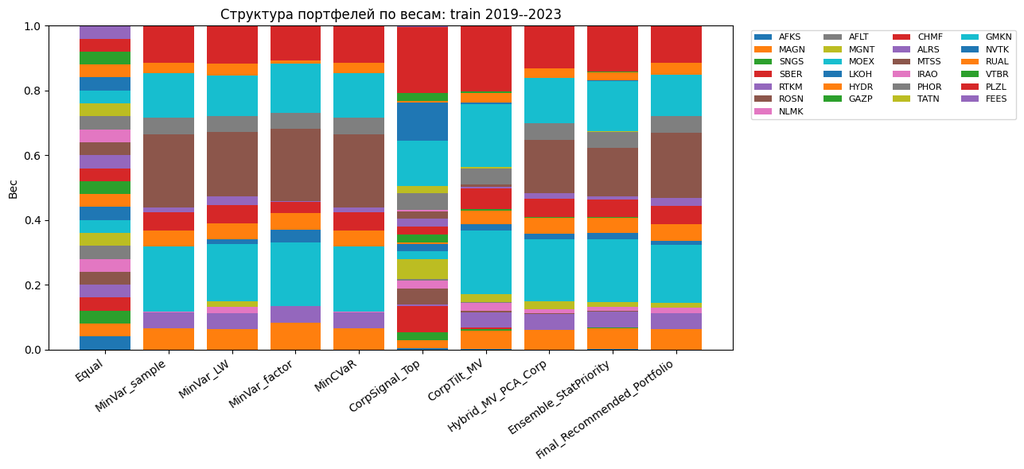

```
L1-distance CorpTilt_MV vs Hybrid_MV_PCA_Corp: 0.3723
```

```python
    # Сохраняем диагностические таблицы для следующих блоков.
    globals()[f'final_selector_validation_diag_{artifact_suffix}'] = validation_diag
    globals()[f'final_selector_validation_fold_diag_{artifact_suffix}'] = validation_fold_diag
    globals()[f'final_selector_selected_mix_{artifact_suffix}'] = selected_mix
    globals()[f'final_selected_candidate_{artifact_suffix}'] = selected_mix.iloc[0]['selected_candidate'] if not selected_mix.empty and 'selected_candidate' in selected_mix.columns else None
    globals()[f'adaptive_validation_diag_{artifact_suffix}'] = validation_diag
    globals()[f'adaptive_validation_fold_diag_{artifact_suffix}'] = validation_fold_diag
    globals()[f'adaptive_selected_mix_{artifact_suffix}'] = selected_mix
    globals()[f'portfolio_weight_l1_distances_{artifact_suffix}'] = pairwise_distance
    return out


portfolio_weights = build_portfolios(
    train_returns,
    decision_date=PORTFOLIO_FORMATION_DATE,
    save_artifacts=True,
    artifact_suffix='static_train_2019_2023'
)
portfolio_weights.to_csv(OUTPUT_DIR / 'portfolio_weights_static_train_2019_2023.csv', encoding='utf-8-sig')
display(portfolio_weights.style.format('{:.2%}'))

plt.figure(figsize=(13, 6))
bottom = np.zeros(portfolio_weights.shape[1])
for ticker in portfolio_weights.index:
    vals = portfolio_weights.loc[ticker].values
    plt.bar(portfolio_weights.columns, vals, bottom=bottom, label=ticker)
    bottom += vals
plt.xticks(rotation=35, ha='right')
plt.ylabel('Вес')
plt.title('Структура портфелей по весам: train 2019--2023')
plt.legend(ncol=4, fontsize=8, bbox_to_anchor=(1.02, 1), loc='upper left')
plt.tight_layout()
plt.savefig(FIG_DIR / 'fig_portfolio_weights_static_2019_2023.png', dpi=200)
plt.show()

# Контроль, что CorpTilt_MV и Hybrid_MV_PCA_Corp не совпадают.
if 'portfolio_weight_l1_distances_static_train_2019_2023' in globals():
    d = portfolio_weight_l1_distances_static_train_2019_2023.loc['CorpTilt_MV', 'Hybrid_MV_PCA_Corp']
    print(f'L1-distance CorpTilt_MV vs Hybrid_MV_PCA_Corp: {d:.4f}')
```

### Интерпретация

Таблица весов показывает, что стратегии по-разному распределяют капитал между бумагами.

`Final_Recommended_Portfolio` сохраняет long-only структуру и допускает нулевые веса, поэтому часть эмитентов исключается из итогового портфеля. Это соответствует логике расчёта: вес получает не каждая бумага, а только те позиции, которые проходят через риск-ограничения и процедуру выбора.

## 10. Static out-of-sample 2024--2025 и эффективность стратегии

В статическом out-of-sample тесте веса оцениваются на train-периоде 2019--2023 и затем фиксируются на 2024--2025. Это консервативная проверка: модель видит всю обучающую историю, но не обновляет веса внутри test-периода.

В этом блоке `Final_Recommended_Portfolio` показывает, какой кандидат был выбран внутренней validation-процедурой на train. Далее стратегии сравниваются по доходности, волатильности, Sharpe, VaR/ES, просадке и концентрации весов.

Отдельно считаются ИПС-метрики `HitRate@K` и `Return@K`. Они проверяют, связана ли корпоративная ранжировка с последующей доходностью верхних позиций.

Выводы по этому блоку относятся только к периоду 2024--2025. Отрицательная доходность стратегии не означает автоматическую ошибку модели, если стратегия при этом снижает потери или риск относительно равновесного портфеля.

```python
def add_efficiency_vs_benchmark(metrics: pd.DataFrame, benchmark: str = 'Equal') -> pd.DataFrame:
    out = metrics.copy()
    if benchmark not in out.index:
        return out
    b = out.loc[benchmark]
    out['excess_ann_return_vs_' + benchmark] = out['ann_return'] - b['ann_return']
    out['sharpe_delta_vs_' + benchmark] = out['sharpe'] - b['sharpe']
    out['vol_reduction_vs_' + benchmark] = b['ann_vol'] - out['ann_vol']
    out['ES95_reduction_vs_' + benchmark] = b['ES95_day'] - out['ES95_day']
    out['mdd_improvement_vs_' + benchmark] = out['max_drawdown'] - b['max_drawdown']
    components = pd.DataFrame(index=out.index)
    for col, high_good in [
        ('excess_ann_return_vs_' + benchmark, True),
        ('sharpe_delta_vs_' + benchmark, True),
        ('vol_reduction_vs_' + benchmark, True),
        ('ES95_reduction_vs_' + benchmark, True),
        ('mdd_improvement_vs_' + benchmark, True),
    ]:
        s = out[col].astype(float).replace([np.inf, -np.inf], np.nan).fillna(0)
        if s.nunique() <= 1:
            components[col] = 0.5
        else:
            components[col] = s.rank(pct=True, ascending=True if high_good else False)
    out['efficiency_score_vs_' + benchmark] = (
        0.30 * components['sharpe_delta_vs_' + benchmark] +
        0.25 * components['excess_ann_return_vs_' + benchmark] +
        0.20 * components['ES95_reduction_vs_' + benchmark] +
        0.15 * components['vol_reduction_vs_' + benchmark] +
        0.10 * components['mdd_improvement_vs_' + benchmark]
    )
    return out


def ranking_quality_at_k(score: pd.Series, future_rets: pd.DataFrame, ks: Iterable[int] = (5, 10)) -> pd.DataFrame:
    """ИПС-метрики качества выдачи: HitRate@K и Return@K."""
    if score.empty or future_rets.empty:
        return pd.DataFrame()
    total_ret = np.exp(future_rets.sum(axis=0)) - 1
    common = [t for t in score.index if t in total_ret.index]
    if not common:
        return pd.DataFrame()
    s = score.reindex(common).astype(float).fillna(score.median() if score.notna().any() else 0.0)
    realized = total_ret.reindex(common)
    median_ret = realized.median()
    rows = []
    for k in ks:
        k = min(int(k), len(common))
        top = s.sort_values(ascending=False).head(k).index
        rows.append({
            'K': k,
            'HitRate@K_vs_median_stock': float((realized.loc[top] > median_ret).mean()),
            'Return@K_equal_weight': float(realized.loc[top].mean()),
            'Universe_equal_weight_return': float(realized.mean()),
            'Excess_Return@K_vs_universe': float(realized.loc[top].mean() - realized.mean()),
            'top_tickers': ', '.join(top)
        })
    return pd.DataFrame(rows)


def cumulative_from_weights(rets: pd.DataFrame, weights_df: pd.DataFrame) -> pd.DataFrame:
    return pd.DataFrame({strategy: np.exp(portfolio_return_series(rets, weights_df[strategy]).cumsum()) for strategy in weights_df.columns})


def drawdown_from_cumulative(cum: pd.DataFrame) -> pd.DataFrame:
    return cum / cum.cummax() - 1


def plot_cumulative_subset(cum: pd.DataFrame, columns: List[str], title: str, filename: str, ylabel: str = 'Индекс накопленной доходности') -> None:
    cols = [c for c in columns if c in cum.columns]
    if not cols:
        print(f'Нет колонок для графика {title}')
        return
    plt.figure(figsize=(11, 5.5))
    for col in cols:
        plt.plot(cum.index, cum[col], label=col, linewidth=2.2 if col == FINAL_PORTFOLIO_NAME else (2.0 if 'Adaptive' in col or col in ['MinVar_LW', 'Equal'] else 1.4))
    plt.title(title)
    plt.xlabel('Дата')
    plt.ylabel(ylabel)
    plt.legend(loc='best')
    plt.grid(True, alpha=0.3)
    plt.tight_layout()
    plt.savefig(FIG_DIR / filename, dpi=220)
    plt.show()


def plot_drawdown_subset(cum: pd.DataFrame, columns: List[str], title: str, filename: str) -> None:
    dd = drawdown_from_cumulative(cum)
    cols = [c for c in columns if c in dd.columns]
    if not cols:
        return
    plt.figure(figsize=(11, 5.5))
    for col in cols:
        plt.plot(dd.index, dd[col], label=col, linewidth=2.2 if col == FINAL_PORTFOLIO_NAME else (2.0 if 'Adaptive' in col or col in ['MinVar_LW', 'Equal'] else 1.4))
    plt.title(title)
    plt.xlabel('Дата')
    plt.ylabel('Просадка')
    plt.legend(loc='best')
    plt.grid(True, alpha=0.3)
    plt.tight_layout()
    plt.savefig(FIG_DIR / filename, dpi=220)
    plt.show()


metrics_train = evaluate_portfolios(train_returns, portfolio_weights)
metrics_test = evaluate_portfolios(test_returns, portfolio_weights)
metrics_test_eff = add_efficiency_vs_benchmark(metrics_test, benchmark='Equal')

metrics_train.to_csv(OUTPUT_DIR / 'portfolio_metrics_train_static.csv', encoding='utf-8-sig')
metrics_test.to_csv(OUTPUT_DIR / 'portfolio_metrics_test_2024_2025_static.csv', encoding='utf-8-sig')
metrics_test_eff.to_csv(OUTPUT_DIR / 'portfolio_efficiency_vs_equal_test_2024_2025_static.csv', encoding='utf-8-sig')

fmt_metrics = {
    'ann_return': '{:.2%}', 'ann_vol': '{:.2%}', 'sharpe': '{:.2f}',
    'VaR95_day': '{:.2%}', 'ES95_day': '{:.2%}', 'max_drawdown': '{:.2%}',
    'mean_day': '{:.4%}', 'max_weight': '{:.2%}', 'zero_weight_count': '{:.0f}', 'HHI': '{:.3f}',
    'excess_ann_return_vs_Equal': '{:+.2%}', 'sharpe_delta_vs_Equal': '{:+.2f}',
    'vol_reduction_vs_Equal': '{:+.2%}', 'ES95_reduction_vs_Equal': '{:+.2%}',
    'mdd_improvement_vs_Equal': '{:+.2%}', 'efficiency_score_vs_Equal': '{:.2f}'
}

display(Markdown('### Метрики на обучающем окне 2019--2023'))
display(metrics_train.sort_values('sharpe', ascending=False).style.format(fmt_metrics))

display(Markdown('### Static test 2024--2025: эффективность относительно Equal'))
display(metrics_test_eff.sort_values('efficiency_score_vs_Equal', ascending=False).style.format(fmt_metrics))

core_strategies = ['Equal', 'MinVar_sample', 'MinVar_LW', 'MinVar_factor', 'MinCVaR']
core_comparison = metrics_test_eff.reindex([c for c in core_strategies if c in metrics_test_eff.index]).copy()
core_comparison['core_rank_by_efficiency'] = core_comparison['efficiency_score_vs_Equal'].rank(ascending=False, method='min')
core_comparison.to_csv(OUTPUT_DIR / 'core_risk_strategy_comparison_static_2024_2025.csv', encoding='utf-8-sig')
display(Markdown('### Почему MinVar_LW выбран риск-ядром'))
display(core_comparison.sort_values('efficiency_score_vs_Equal', ascending=False).style.format(fmt_metrics))
```

```python
if 'final_selector_validation_diag_static_train_2019_2023' in globals():
    display(Markdown('### Выбор итогового портфеля по внутренней validation без доступа к test'))
    diag = final_selector_validation_diag_static_train_2019_2023.copy()
    diag.to_csv(OUTPUT_DIR / 'final_selector_validation_candidates_static_visible.csv', encoding='utf-8-sig')
    cols = [c for c in ['ann_return', 'ann_vol', 'sharpe', 'max_drawdown', 'HHI', 'validation_selection_score', 'validation_window_count', 'selected',
                        'LW_component_weight', 'PCA_component_weight', 'CVaR_component_weight', 'CorpRank_component_weight', 'CorpTilt_component_weight', 'MV_component_weight'] if c in diag.columns]
    display(diag.sort_values('validation_selection_score', ascending=False)[cols].style.format({
        'ann_return': '{:.2%}', 'ann_vol': '{:.2%}', 'sharpe': '{:.2f}', 'max_drawdown': '{:.2%}', 'HHI': '{:.3f}',
        'validation_selection_score': '{:.3f}',
        'LW_component_weight': '{:.0%}', 'PCA_component_weight': '{:.0%}', 'CVaR_component_weight': '{:.0%}',
        'CorpRank_component_weight': '{:.0%}', 'CorpTilt_component_weight': '{:.0%}', 'MV_component_weight': '{:.0%}'
    }))

if 'portfolio_weight_l1_distances_static_train_2019_2023' in globals():
    d_ch = portfolio_weight_l1_distances_static_train_2019_2023.loc['CorpTilt_MV', 'Hybrid_MV_PCA_Corp']
    display(Markdown(f'**Проверка весов:** L1-distance между `CorpTilt_MV` и `Hybrid_MV_PCA_Corp` = `{d_ch:.4f}`. Если значение выше нуля, портфели уже не совпадают.'))

if FINAL_PORTFOLIO_NAME in metrics_test_eff.index:
    final = metrics_test_eff.loc[FINAL_PORTFOLIO_NAME]
    best_eff = metrics_test_eff['efficiency_score_vs_Equal'].idxmax()
    selected_candidate_text = 'н/д'
    if 'final_selector_selected_mix_static_train_2019_2023' in globals() and not final_selector_selected_mix_static_train_2019_2023.empty:
        selected_candidate_text = str(final_selector_selected_mix_static_train_2019_2023.iloc[0].get('selected_candidate', 'н/д'))
    msg = (
        f"**Итоговый рекомендуемый портфель:** `{FINAL_PORTFOLIO_NAME}`. "
        f"Внутренний selector выбрал кандидат `{selected_candidate_text}`. "
        f"Sharpe={final['sharpe']:.3f}, годовая доходность={final['ann_return']:.2%}, "
        f"max drawdown={final['max_drawdown']:.2%}, нулевых весов={int(final['zero_weight_count'])}. "
        f"Лучшая стратегия по интегральной эффективности на test: `{best_eff}`."
    )
    if best_eff != FINAL_PORTFOLIO_NAME:
        msg += ' Это не является test-подгонкой: итоговый портфель выбран только по внутренней validation; test используется для честной оценки.'
    display(Markdown(msg))

# ИПС-метрики по корпоративно-рыночному score.
ranking_score = pd.Series(dtype=float)
if 'expected_returns_signals' in globals() and not expected_returns_signals.empty:
    ranking_score = expected_returns_signals['mu_combined_eta_stat'].copy()
elif 'corp_score' in globals() and not corp_score.empty:
    ranking_score = corp_score.copy()
ranking_metrics = ranking_quality_at_k(ranking_score, test_returns, ks=(5, 10))
ranking_metrics.to_csv(OUTPUT_DIR / 'ranking_quality_at_k_2024_2025_static.csv', index=False, encoding='utf-8-sig')
if not ranking_metrics.empty:
    display(Markdown('### ИПС-метрики ранжирования'))
    display(ranking_metrics.style.format({
        'HitRate@K_vs_median_stock': '{:.2%}',
        'Return@K_equal_weight': '{:.2%}',
        'Universe_equal_weight_return': '{:.2%}',
        'Excess_Return@K_vs_universe': '{:+.2%}'
    }))

# Диагностика корпоративных характеристик: базовый набор vs все признаки с покрытием.
def _feature_set_raw_frame(raw: pd.DataFrame, features: List[str]) -> pd.DataFrame:
    work = pd.DataFrame(index=raw.index)
    for f in features:
        if f == 'log_market_cap':
            work[f] = np.log1p(pd.to_numeric(raw.get('market_cap', np.nan), errors='coerce').clip(lower=0))
        else:
            work[f] = pd.to_numeric(raw.get(f, np.nan), errors='coerce')
    return work.replace([np.inf, -np.inf], np.nan)


def _standardize_by_year_for_features(panel_raw: pd.DataFrame, features: List[str]) -> pd.DataFrame:
    if panel_raw.empty:
        return pd.DataFrame()
    rows = []
    for _, row in panel_raw.iterrows():
        rec = {'ticker': row['ticker'], 'year': int(row['year'])}
        for f in features:
            if f == 'log_market_cap':
                rec[f] = np.log1p(max(row.get('market_cap', np.nan), 0)) if pd.notna(row.get('market_cap', np.nan)) else np.nan
            else:
                rec[f] = row.get(f, np.nan)
        rows.append(rec)
    df = pd.DataFrame(rows)
    coverage = df[features].notna().mean(axis=0)
    features_kept = coverage[coverage >= MIN_CORP_FEATURE_COVERAGE].index.tolist()
    if not features_kept:
        return pd.DataFrame()
    global_median = df[features_kept].median(axis=0, skipna=True)
    parts = []
    for y, part in df.groupby('year'):
        part = part.copy()
        for f in features_kept:
            med = part[f].median(skipna=True)
            if pd.isna(med):
                med = global_median.get(f, 0.0)
            part[f] = part[f].fillna(med)
            part[f] = _winsorize_series(part[f])
            sd = part[f].std(ddof=0)
            part[f] = 0.0 if sd == 0 or pd.isna(sd) else (part[f] - part[f].mean()) / sd
        parts.append(part[['ticker', 'year'] + features_kept])
    return pd.concat(parts).set_index(['ticker', 'year']).sort_index().fillna(0.0)


def _snapshot_Z_for_features(snapshot_raw: pd.DataFrame, features: List[str]) -> pd.DataFrame:
    if snapshot_raw.empty:
        return pd.DataFrame()
    raw = snapshot_raw.set_index('ticker')
    work = _feature_set_raw_frame(raw, features)
    coverage = work.notna().mean(axis=0)
    features_kept = coverage[coverage >= MIN_CORP_FEATURE_COVERAGE].index.tolist()
    if not features_kept:
        return pd.DataFrame()
    work = work[features_kept].copy()
    med = work.median(axis=0, skipna=True)
    work = work.fillna(med)
    work = work.apply(_winsorize_series, axis=0)
    sd = work.std(axis=0, ddof=0).replace(0, np.nan)
    return ((work - work.mean(axis=0)) / sd).fillna(0.0)
```

```python
def diagnose_corporate_feature_sets() -> pd.DataFrame:
    if main_available_corp.empty or corp_current_raw.empty:
        return pd.DataFrame()
    base_7 = ['log_market_cap', 'pe', 'pb', 'roe', 'netdebt_ebitda', 'dividend_yield', 'free_float']
    all_8 = ['log_market_cap', 'pe', 'pb', 'roe', 'debt_equity', 'netdebt_ebitda', 'dividend_yield', 'free_float']
    raw_cov = {}
    for f in all_8:
        raw_col = 'market_cap' if f == 'log_market_cap' else f
        raw_cov[f] = float(main_available_corp[raw_col].notna().mean()) if raw_col in main_available_corp.columns else 0.0
    high_cov = [f for f, c in raw_cov.items() if c >= 0.60]
    feature_sets = {
        'base_7_without_debt_equity': base_7,
        'all_available_8': all_8,
        'high_coverage_60pct': high_cov if high_cov else base_7,
    }
    rows = []
    for name, feats in feature_sets.items():
        Zp = _standardize_by_year_for_features(main_available_corp, feats)
        Zs = _snapshot_Z_for_features(corp_current_raw, feats)
        if Zp.empty or Zs.empty:
            rows.append({'feature_set': name, 'used_features': '', 'n_features': 0, 'note': 'empty Z'})
            continue
        rt, mu_tmp, _, _fitq = fit_corporate_expected_return_panel(Zp, train_returns, Z_snapshot=Zs)
        scores, load, expl = corporate_pca_from_Z(Zp, max_components=min(5, Zp.shape[1]))
        fw = build_corporate_feature_weights(rt, load, expl, main_available_corp, features=list(Zs.columns))
        if fw.empty:
            rows.append({'feature_set': name, 'used_features': ', '.join(Zs.columns), 'n_features': Zs.shape[1], 'note': 'empty weights'})
            continue
        vec = (fw['final_feature_weight'] * fw['sign_for_score']).reindex(Zs.columns).fillna(0)
        sc = _standardize_series(Zs @ vec)
        rank_diag = ranking_quality_at_k(sc, test_returns, ks=(5, 10))
        corp_tilt = anchored_signal_tilt_weights(portfolio_weights['MinVar_LW'], sc, intensity=0.45, zero_bottom_frac=0.20, max_weight=compute_liquidity_caps(train_returns, list(train_returns.columns)))
        ew = pd.DataFrame({'MinVar_LW': portfolio_weights['MinVar_LW'], f'{name}_tilt': corp_tilt})
        perf = evaluate_portfolios(test_returns, ew)
        row = {
            'feature_set': name,
            'used_features': ', '.join(Zs.columns),
            'n_features': int(Zs.shape[1]),
            'tilt_ann_return': perf.loc[f'{name}_tilt', 'ann_return'],
            'tilt_sharpe': perf.loc[f'{name}_tilt', 'sharpe'],
            'tilt_max_drawdown': perf.loc[f'{name}_tilt', 'max_drawdown'],
            'delta_ann_return_vs_MinVar_LW': perf.loc[f'{name}_tilt', 'ann_return'] - perf.loc['MinVar_LW', 'ann_return'],
            'delta_sharpe_vs_MinVar_LW': perf.loc[f'{name}_tilt', 'sharpe'] - perf.loc['MinVar_LW', 'sharpe'],
            'top_feature': fw.index[0],
            'top_feature_weight': fw.iloc[0]['final_feature_weight'],
            'note': 'test diagnostic only; not used for ex-post tuning'
        }
        if not rank_diag.empty:
            for _, rr in rank_diag.iterrows():
                row[f'HitRate@{int(rr.K)}'] = rr['HitRate@K_vs_median_stock']
                row[f'ExcessReturn@{int(rr.K)}'] = rr['Excess_Return@K_vs_universe']
        rows.append(row)
    diag = pd.DataFrame(rows)
    diag.to_csv(OUTPUT_DIR / 'corporate_feature_set_diagnostics_static.csv', index=False, encoding='utf-8-sig')
    pd.Series(raw_cov, name='feature_coverage_available_at_formation').to_csv(OUTPUT_DIR / 'corporate_feature_coverage_available_at_formation.csv', encoding='utf-8-sig')
    return diag


corporate_feature_set_diagnostics = diagnose_corporate_feature_sets()
if not corporate_feature_set_diagnostics.empty:
    display(Markdown('### Какие корпоративные характеристики используются и помогает ли расширение набора'))
    display(corporate_feature_set_diagnostics.style.format({
        'tilt_ann_return': '{:.2%}', 'tilt_sharpe': '{:.2f}', 'tilt_max_drawdown': '{:.2%}',
        'delta_ann_return_vs_MinVar_LW': '{:+.2%}', 'delta_sharpe_vs_MinVar_LW': '{:+.2f}',
        'top_feature_weight': '{:.2%}', 'HitRate@5': '{:.2%}', 'HitRate@10': '{:.2%}',
        'ExcessReturn@5': '{:+.2%}', 'ExcessReturn@10': '{:+.2%}'
    }))

cum_test = cumulative_from_weights(test_returns, portfolio_weights)
cum_test.to_csv(OUTPUT_DIR / 'portfolio_cumulative_test_2024_2025_static.csv', encoding='utf-8-sig')

# Читаемые отдельные графики вместо одного перегруженного графика.
plot_cumulative_subset(
    cum_test,
    ['Equal', 'MinVar_sample', 'MinVar_LW', 'MinVar_factor', 'MinCVaR'],
    'Static test 2024--2025: базовые риск-стратегии',
    'fig_core_risk_strategies_static_2024_2025.png'
)
plot_cumulative_subset(
    cum_test,
    ['Equal', 'MinVar_LW', FINAL_PORTFOLIO_NAME, 'CorpTilt_MV', 'MinCVaR'],
    'Static test 2024--2025: Final portfolio против Equal, MinVar_LW и CorpTilt',
    'fig_final_vs_equal_minvar_static_2024_2025.png'
)
plot_cumulative_subset(
    cum_test,
    ['Equal', 'CorpSignal_Top', 'CorpTilt_MV', 'Hybrid_MV_PCA_Corp', FINAL_PORTFOLIO_NAME],
    'Static test 2024--2025: корпоративные стратегии и Final portfolio',
    'fig_corporate_strategies_static_2024_2025.png'
)
plot_drawdown_subset(
    cum_test,
    ['Equal', 'MinVar_LW', FINAL_PORTFOLIO_NAME, 'CorpTilt_MV', 'MinCVaR'],
    'Static test 2024--2025: просадки ключевых портфелей',
    'fig_key_portfolio_drawdowns_static_2024_2025.png'
)

# Сравнение с индексами российского рынка.
def download_moex_index_candles(index_code: str,
                                start: str = TEST_START,
                                end: str = TEST_END,
                                force_download: bool = False) -> pd.DataFrame:
    cache_path = CACHE_DIR / f'index_{index_code}_{start}_{end}.csv'
    if cache_path.exists() and not force_download:
        return pd.read_csv(cache_path, parse_dates=['date'])
    url = f'https://iss.moex.com/iss/engines/stock/markets/index/securities/{index_code}/candles.json'
    frames = []
    start_pos = 0
    while True:
        params = {'from': start, 'till': end, 'interval': 24, 'start': start_pos}
        try:
            r = requests.get(url, params=params, timeout=20)
            r.raise_for_status()
            js = r.json()
            block = js.get('candles', {})
            data = block.get('data', [])
            columns = block.get('columns', [])
            if not data:
                break
            part = pd.DataFrame(data, columns=columns)
            frames.append(part)
            if len(part) < 500:
                break
            start_pos += len(part)
            time.sleep(0.05)
        except Exception as e:
            print(f'Не удалось загрузить индекс {index_code}: {e}')
            break
    if not frames:
        return pd.DataFrame()
    df = pd.concat(frames, ignore_index=True)
    date_col = 'begin' if 'begin' in df.columns else ('end' if 'end' in df.columns else None)
    if date_col is None or 'close' not in df.columns:
        return pd.DataFrame()
    out = df[[date_col, 'close']].rename(columns={date_col: 'date', 'close': index_code})
    out['date'] = pd.to_datetime(out['date']).dt.normalize()
    out[index_code] = pd.to_numeric(out[index_code], errors='coerce')
    out = out.dropna().drop_duplicates('date').sort_values('date')
    out.to_csv(cache_path, index=False, encoding='utf-8-sig')
    return out
```

Метрики на обучающем окне 2019--2023

| strategy | ann_return | ann_vol | sharpe | VaR95_day | ES95_day | max_drawdown | mean_day | n_obs | max_weight | zero_weight_count | HHI |
| --- | --- | --- | --- | --- | --- | --- | --- | --- | --- | --- | --- |
| CorpTilt_MV | 10.13% | 22.91% | 0.44 | 1.90% | 3.50% | -55.56% | 0.0383% | 1226 | 20.27% | 0 | 0.133 |
| Ensemble_StatPriority | 8.73% | 22.06% | 0.40 | 1.77% | 3.39% | -52.71% | 0.0332% | 1226 | 19.38% | 0 | 0.119 |
| Hybrid_MV_PCA_Corp | 8.60% | 21.96% | 0.39 | 1.78% | 3.38% | -52.04% | 0.0327% | 1226 | 19.21% | 0 | 0.118 |
| MinVar_factor | 8.15% | 21.91% | 0.37 | 1.76% | 3.38% | -51.29% | 0.0311% | 1226 | 22.34% | 13 | 0.141 |
| MinCVaR | 8.09% | 21.87% | 0.37 | 1.73% | 3.37% | -51.84% | 0.0309% | 1226 | 22.60% | 13 | 0.141 |
| MinVar_sample | 8.09% | 21.87% | 0.37 | 1.73% | 3.37% | -51.84% | 0.0309% | 1226 | 22.60% | 13 | 0.141 |
| Final_Recommended_Portfolio | 7.90% | 21.89% | 0.36 | 1.80% | 3.39% | -51.73% | 0.0302% | 1226 | 20.16% | 11 | 0.120 |
| MinVar_LW | 7.87% | 21.90% | 0.36 | 1.80% | 3.39% | -51.72% | 0.0301% | 1226 | 19.73% | 11 | 0.117 |
| CorpSignal_Top | 7.80% | 25.63% | 0.30 | 1.92% | 3.85% | -54.84% | 0.0298% | 1226 | 20.40% | 0 | 0.096 |
| Equal | 3.65% | 25.83% | 0.14 | 1.88% | 4.08% | -54.41% | 0.0142% | 1226 | 4.00% | 0 | 0.040 |

Static test 2024--2025: эффективность относительно Equal

| strategy | ann_return | ann_vol | sharpe | VaR95_day | ES95_day | max_drawdown | mean_day | n_obs | max_weight | zero_weight_count | HHI | excess_ann_return_vs_Equal | sharpe_delta_vs_Equal | vol_reduction_vs_Equal | ES95_reduction_vs_Equal | mdd_improvement_vs_Equal | efficiency_score_vs_Equal |
| --- | --- | --- | --- | --- | --- | --- | --- | --- | --- | --- | --- | --- | --- | --- | --- | --- | --- |
| CorpTilt_MV | -0.13% | 22.76% | -0.01 | 2.50% | 3.22% | -32.49% | -0.0005% | 550 | 20.27% | 0 | 0.133 | +8.81% | +0.37 | +1.02% | +0.15% | +5.94% | 0.87 |
| CorpSignal_Top | -1.06% | 22.76% | -0.05 | 2.39% | 3.21% | -31.82% | -0.0042% | 550 | 20.40% | 0 | 0.096 | +7.88% | +0.33 | +1.02% | +0.17% | +6.61% | 0.83 |
| Ensemble_StatPriority | -2.60% | 22.49% | -0.12 | 2.54% | 3.23% | -35.43% | -0.0104% | 550 | 19.38% | 0 | 0.119 | +6.34% | +0.26 | +1.29% | +0.14% | +3.00% | 0.79 |
| MinVar_factor | -3.51% | 22.48% | -0.16 | 2.42% | 3.23% | -36.47% | -0.0142% | 550 | 22.34% | 13 | 0.141 | +5.43% | +0.22 | +1.30% | +0.15% | +1.97% | 0.59 |
| Hybrid_MV_PCA_Corp | -3.37% | 22.50% | -0.15 | 2.55% | 3.24% | -36.06% | -0.0136% | 550 | 19.21% | 0 | 0.118 | +5.57% | +0.23 | +1.28% | +0.13% | +2.37% | 0.58 |
| MinVar_sample | -3.18% | 22.72% | -0.14 | 2.50% | 3.28% | -36.93% | -0.0128% | 550 | 22.60% | 13 | 0.141 | +5.75% | +0.24 | +1.06% | +0.09% | +1.50% | 0.56 |
| MinCVaR | -3.18% | 22.72% | -0.14 | 2.50% | 3.28% | -36.93% | -0.0128% | 550 | 22.60% | 13 | 0.141 | +5.75% | +0.24 | +1.06% | +0.09% | +1.50% | 0.56 |
| Final_Recommended_Portfolio | -4.00% | 22.70% | -0.18 | 2.54% | 3.28% | -37.10% | -0.0162% | 550 | 20.16% | 11 | 0.120 | +4.94% | +0.20 | +1.08% | +0.09% | +1.33% | 0.36 |
| MinVar_LW | -4.14% | 22.70% | -0.18 | 2.55% | 3.28% | -37.13% | -0.0168% | 550 | 19.73% | 11 | 0.117 | +4.80% | +0.19 | +1.08% | +0.09% | +1.30% | 0.26 |
| Equal | -8.94% | 23.78% | -0.38 | 2.70% | 3.37% | -38.43% | -0.0372% | 550 | 4.00% | 0 | 0.040 | +0.00% | +0.00 | +0.00% | +0.00% | +0.00% | 0.10 |

Почему MinVar_LW выбран риск-ядром

| strategy | ann_return | ann_vol | sharpe | VaR95_day | ES95_day | max_drawdown | mean_day | n_obs | max_weight | zero_weight_count | HHI | excess_ann_return_vs_Equal | sharpe_delta_vs_Equal | vol_reduction_vs_Equal | ES95_reduction_vs_Equal | mdd_improvement_vs_Equal | efficiency_score_vs_Equal | core_rank_by_efficiency |
| --- | --- | --- | --- | --- | --- | --- | --- | --- | --- | --- | --- | --- | --- | --- | --- | --- | --- | --- |
| MinVar_factor | -3.51% | 22.48% | -0.16 | 2.42% | 3.23% | -36.47% | -0.0142% | 550 | 22.34% | 13 | 0.141 | +5.43% | +0.22 | +1.30% | +0.15% | +1.97% | 0.59 | 1.000000 |
| MinCVaR | -3.18% | 22.72% | -0.14 | 2.50% | 3.28% | -36.93% | -0.0128% | 550 | 22.60% | 13 | 0.141 | +5.75% | +0.24 | +1.06% | +0.09% | +1.50% | 0.56 | 2.000000 |
| MinVar_sample | -3.18% | 22.72% | -0.14 | 2.50% | 3.28% | -36.93% | -0.0128% | 550 | 22.60% | 13 | 0.141 | +5.75% | +0.24 | +1.06% | +0.09% | +1.50% | 0.56 | 2.000000 |
| MinVar_LW | -4.14% | 22.70% | -0.18 | 2.55% | 3.28% | -37.13% | -0.0168% | 550 | 19.73% | 11 | 0.117 | +4.80% | +0.19 | +1.08% | +0.09% | +1.30% | 0.26 | 4.000000 |
| Equal | -8.94% | 23.78% | -0.38 | 2.70% | 3.37% | -38.43% | -0.0372% | 550 | 4.00% | 0 | 0.040 | +0.00% | +0.00 | +0.00% | +0.00% | +0.00% | 0.10 | 5.000000 |

Выбор итогового портфеля по внутренней validation без доступа к test

| candidate | ann_return | ann_vol | sharpe | max_drawdown | HHI | validation_selection_score | validation_window_count | selected | LW_component_weight | PCA_component_weight | CVaR_component_weight | CorpRank_component_weight | CorpTilt_component_weight | MV_component_weight |
| --- | --- | --- | --- | --- | --- | --- | --- | --- | --- | --- | --- | --- | --- | --- |
| LW85_CVaR15 | 0.52% | 23.74% | 0.54 | -23.26% | 0.137 | 0.675 | 3 | True | 85% | 0% | 15% | 0% | 0% | 0% |
| MinCVaR | 1.08% | 23.86% | 0.55 | -23.45% | 0.151 | 0.667 | 3 | False | 0% | 0% | 100% | 0% | 0% | 0% |
| MinVar_LW | 0.42% | 23.72% | 0.54 | -23.26% | 0.135 | 0.601 | 3 | False | 100% | 0% | 0% | 0% | 0% | 0% |
| LW80_PCA20 | 0.41% | 23.73% | 0.53 | -23.27% | 0.138 | 0.596 | 3 | False | 80% | 20% | 0% | 0% | 0% | 0% |
| LW75_Corp25 | 0.16% | 23.68% | 0.52 | -23.28% | 0.139 | 0.575 | 3 | False | 75% | 0% | 0% | 0% | 25% | 0% |
| LW85_Corp15 | 0.26% | 23.70% | 0.53 | -23.26% | 0.137 | 0.572 | 3 | False | 85% | 0% | 0% | 0% | 15% | 0% |
| LW65_Corp35 | 0.05% | 23.68% | 0.51 | -23.30% | 0.141 | 0.567 | 3 | False | 65% | 0% | 0% | 0% | 35% | 0% |
| MinVar_factor | 0.36% | 23.82% | 0.51 | -23.42% | 0.152 | 0.511 | 3 | False | 0% | 100% | 0% | 0% | 0% | 0% |
| Hybrid_MV_PCA_Corp | -0.02% | 23.70% | 0.51 | -23.45% | 0.136 | 0.494 | 3 | False | 55% | 15% | 10% | 0% | 10% | 10% |
| CorpTilt_MV | -0.62% | 23.73% | 0.46 | -23.51% | 0.163 | 0.456 | 3 | False | 0% | 0% | 0% | 0% | 100% | 0% |
| LW60_MV20_Corp20 | -0.58% | 23.69% | 0.48 | -23.59% | 0.133 | 0.404 | 3 | False | 60% | 0% | 0% | 0% | 20% | 20% |
| LW70_MV30 | -0.76% | 23.71% | 0.47 | -23.74% | 0.127 | 0.382 | 3 | False | 70% | 0% | 0% | 0% | 0% | 30% |

**Проверка весов:** L1-distance между `CorpTilt_MV` и `Hybrid_MV_PCA_Corp` = `0.3723`. Если значение выше нуля, портфели уже не совпадают.

**Итоговый рекомендуемый портфель:** `Final_Recommended_Portfolio`. Внутренний selector выбрал кандидат `LW85_CVaR15`. Sharpe=-0.176, годовая доходность=-4.00%, max drawdown=-37.10%, нулевых весов=11. Лучшая стратегия по интегральной эффективности на test: `CorpTilt_MV`. Это не является test-подгонкой: итоговый портфель выбран только по внутренней validation; test используется для честной оценки.

ИПС-метрики ранжирования

|  | K | HitRate@K_vs_median_stock | Return@K_equal_weight | Universe_equal_weight_return | Excess_Return@K_vs_universe | top_tickers |
| --- | --- | --- | --- | --- | --- | --- |
| 0 | 5 | 80.00% | 7.60% | -13.14% | +20.73% | PHOR, PLZL, GMKN, MGNT, NVTK |
| 1 | 10 | 70.00% | -2.47% | -13.14% | +10.67% | PHOR, PLZL, GMKN, MGNT, NVTK, SBER, MOEX, LKOH, ROSN, GAZP |

Какие корпоративные характеристики используются и помогает ли расширение набора

|  | feature_set | used_features | n_features | tilt_ann_return | tilt_sharpe | tilt_max_drawdown | delta_ann_return_vs_MinVar_LW | delta_sharpe_vs_MinVar_LW | top_feature | top_feature_weight | note | HitRate@5 | ExcessReturn@5 | HitRate@10 | ExcessReturn@10 |
| --- | --- | --- | --- | --- | --- | --- | --- | --- | --- | --- | --- | --- | --- | --- | --- |
| 0 | base_7_without_debt_equity | log_market_cap, pe, pb, roe, netdebt_ebitda, dividend_yield, free_float | 7 | -1.27% | -0.05 | -33.65% | +2.87% | +0.13 | pb | 21.02% | test diagnostic only; not used for ex-post tuning | 80.00% | +27.85% | 60.00% | +10.70% |
| 1 | all_available_8 | log_market_cap, pe, pb, roe, netdebt_ebitda, dividend_yield, free_float | 7 | -1.27% | -0.05 | -33.65% | +2.87% | +0.13 | pb | 21.02% | test diagnostic only; not used for ex-post tuning | 80.00% | +27.85% | 60.00% | +10.70% |
| 2 | high_coverage_60pct | log_market_cap, pe, pb, roe, netdebt_ebitda, dividend_yield, free_float | 7 | -1.27% | -0.05 | -33.65% | +2.87% | +0.13 | pb | 21.02% | test diagnostic only; not used for ex-post tuning | 80.00% | +27.85% | 60.00% | +10.70% |

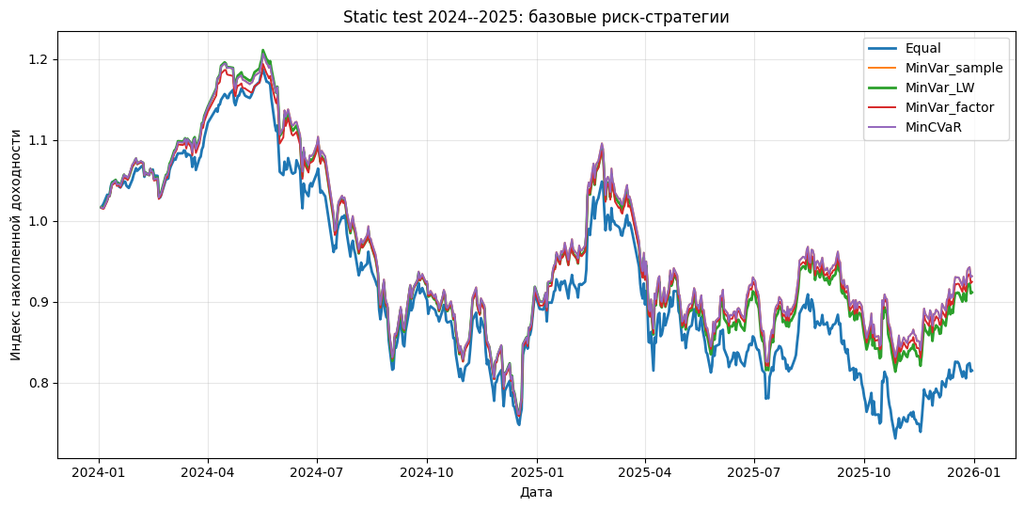

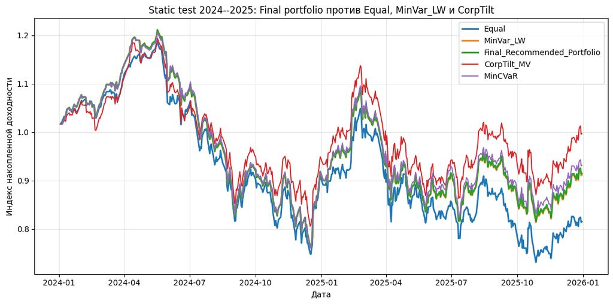

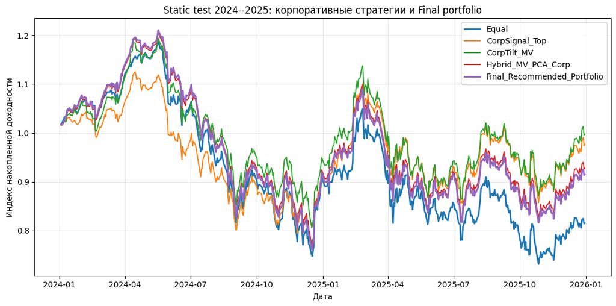

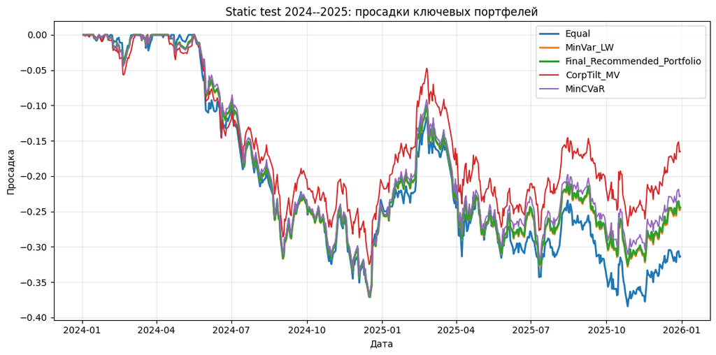

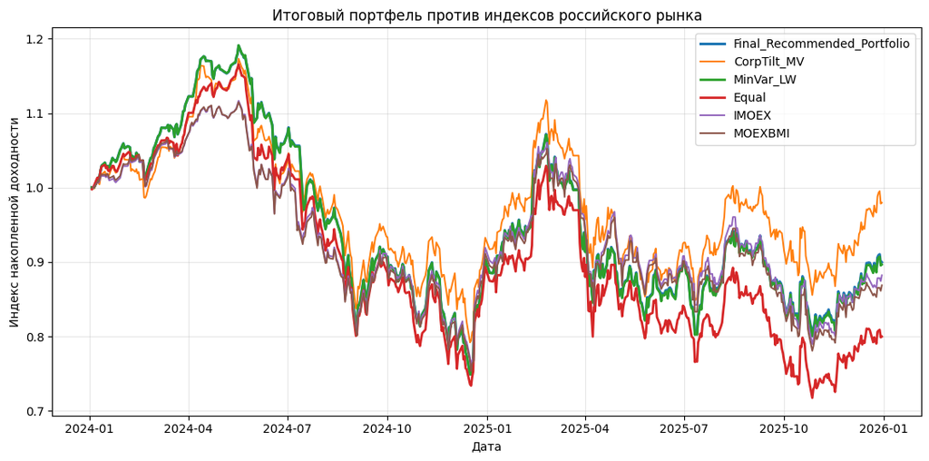

Метрики индексов российского рынка

|  | ann_return | ann_vol | sharpe | VaR95_day | ES95_day | max_drawdown | mean_day | n_obs |
| --- | --- | --- | --- | --- | --- | --- | --- | --- |
| IMOEX | -5.93% | 22.45% | -0.26 | 0.023999 | 2.99% | -32.12% | -0.000243 | 509.000000 |
| MOEXBMI | -6.59% | 22.12% | -0.30 | 0.023902 | 2.98% | -32.41% | -0.000271 | 509.000000 |

```python
def load_index_returns(index_map: Dict[str, str]) -> Tuple[pd.DataFrame, pd.DataFrame]:
    levels = []
    for code in index_map:
        df = download_moex_index_candles(code, TEST_START, TEST_END, force_download=False)
        if not df.empty:
            levels.append(df.set_index('date')[[code]])
    if not levels:
        return pd.DataFrame(), pd.DataFrame()
    level_df = pd.concat(levels, axis=1).sort_index().ffill()
    rets = np.log(level_df / level_df.shift(1)).dropna(how='all')
    return level_df, rets


index_levels, index_returns = load_index_returns(INDEX_BENCHMARKS)
if not index_returns.empty:
    index_cum = np.exp(index_returns.fillna(0).cumsum())
    key_portfolio_cum = cum_test[[c for c in [FINAL_PORTFOLIO_NAME, 'CorpTilt_MV', 'MinVar_LW', 'Equal'] if c in cum_test.columns]].copy()
    combined = pd.concat([key_portfolio_cum, index_cum], axis=1).dropna(how='all').ffill()
    combined = combined / combined.dropna().iloc[0]
    combined.to_csv(OUTPUT_DIR / 'final_portfolio_vs_moex_indices_cumulative.csv', encoding='utf-8-sig')
    plot_cumulative_subset(
        combined,
        list(combined.columns),
        'Итоговый портфель против индексов российского рынка',
        'fig_final_portfolio_vs_moex_indices_2024_2025.png'
    )
    index_metrics = pd.DataFrame({c: evaluate_return_series(index_returns[c].dropna()) for c in index_returns.columns}).T
    index_metrics.to_csv(OUTPUT_DIR / 'moex_index_metrics_2024_2025.csv', encoding='utf-8-sig')
    display(Markdown('### Метрики индексов российского рынка'))
    display(index_metrics.style.format({'ann_return': '{:.2%}', 'ann_vol': '{:.2%}', 'sharpe': '{:.2f}', 'max_drawdown': '{:.2%}', 'ES95_day': '{:.2%}'}))
else:
    print('Индексы MOEX не загружены. При запуске без интернета график сравнения с индексами будет пропущен; при обычном запуске notebook загрузит их через MOEX ISS.')
```

### Интерпретация

В статическом test 2024--2025 большинство стратегий имеют отрицательную годовую доходность, поэтому основной вывод здесь связан не с абсолютной прибылью, а со сравнением с `Equal`.

`CorpTilt_MV` показывает около -0.13% годовой доходности против -8.94% у равновесного портфеля, а `Final_Recommended_Portfolio` — около -4.00%. В этом периоде корпоративный tilt и выбранный итоговый портфель снижали потери относительно равновесной базы, но не превращали неблагоприятный рынок в устойчиво положительный результат.

## 11. Rolling-window проверка 2024--2025

Rolling-window блок показывает, как схема ведёт себя при регулярном обновлении данных. На каждом окне заново формируется train-выборка, корпоративный snapshot и портфельные веса.

На каждом шаге выполняются одни и те же действия: train берётся от 2019 года до дня перед началом текущего test-окна; корпоративная отчётность фильтруется по `available_from <= decision_date`; learning panel включает доступные строки `ticker-year`; scoring snapshot берёт последний доступный год по каждой компании; портфели пересчитываются заново; для итогового портфеля применяется умеренное turnover-сглаживание; доходность проверяется на следующем 63-дневном test-окне.

Такой режим ближе к практическому использованию модели: новые рыночные данные и опубликованная отчётность постепенно входят в расчёт, а будущая информация не используется.

```python
def run_production_rolling_window(rets: pd.DataFrame,
                                  test_start: str = TEST_START,
                                  test_end: str = TEST_END,
                                  test_days: int = ROLLING_TEST_DAYS,
                                  step_days: int = ROLLING_STEP_DAYS) -> Tuple[pd.DataFrame, pd.DataFrame, pd.DataFrame]:
    all_returns = []
    all_metrics = []
    all_weights = []

    dates = rets.index.sort_values()
    test_start = pd.to_datetime(test_start)
    test_end = pd.to_datetime(test_end)
    test_positions = np.where((dates >= test_start) & (dates <= test_end))[0]
    if len(test_positions) == 0:
        return pd.DataFrame(), pd.DataFrame(), pd.DataFrame()

    prev_weights = None
    period_id = 0
    pos = int(test_positions[0])
    last_pos = int(test_positions[-1])

    while pos <= last_pos:
        test = rets.iloc[pos:min(pos + test_days, len(rets))]
        test = test.loc[test.index <= test_end]
        if test.empty:
            break
        decision_date = pd.to_datetime(test.index.min())
        train = rets.loc[(rets.index >= pd.to_datetime(TRAIN_START)) & (rets.index < decision_date)].copy()
        if len(train) < MIN_ROLLING_TRAIN_OBS:
            pos += step_days
            continue

        period_id += 1
        try:
            w = build_portfolios(
                train,
                decision_date=decision_date,
                save_artifacts=False,
                artifact_suffix=f'rolling_{period_id:02d}',
                previous_weights_df=prev_weights
            )
        except Exception as e:
            print(f'Rolling period {period_id}: ошибка оптимизации, пропуск. {e}')
            pos += step_days
            continue

        m = evaluate_portfolios(test, w)
        m['period_id'] = period_id
        m['train_start'] = train.index.min()
        m['train_end'] = train.index.max()
        m['test_start'] = test.index.min()
        m['test_end'] = test.index.max()
        m['decision_date'] = decision_date
        m['corp_max_available_year'] = max_available_corp_year(decision_date, tickers=list(train.columns))
        m['rolling_role'] = 'production_adaptive_test'
        all_metrics.append(m.reset_index())

        for strategy in w.columns:
            rr = portfolio_return_series(test, w[strategy]).rename('return').reset_index()
            rr = rr.rename(columns={rr.columns[0]: 'date'})
            rr['strategy'] = strategy
            rr['period_id'] = period_id
            rr['train_start'] = train.index.min()
            rr['train_end'] = train.index.max()
            rr['test_start'] = test.index.min()
            rr['test_end'] = test.index.max()
            rr['decision_date'] = decision_date
            rr['corp_max_available_year'] = max_available_corp_year(decision_date, tickers=list(train.columns))
            all_returns.append(rr)

            ww = w[strategy].rename('weight').reset_index()
            ww = ww.rename(columns={ww.columns[0]: 'ticker'})
            ww['strategy'] = strategy
            ww['period_id'] = period_id
            ww['train_start'] = train.index.min()
            ww['train_end'] = train.index.max()
            ww['test_start'] = test.index.min()
            ww['test_end'] = test.index.max()
            ww['decision_date'] = decision_date
            ww['corp_max_available_year'] = max_available_corp_year(decision_date, tickers=list(train.columns))
            all_weights.append(ww)

        prev_weights = w.copy()
        pos += step_days

    returns_df = pd.concat(all_returns, ignore_index=True) if all_returns else pd.DataFrame()
    metrics_df = pd.concat(all_metrics, ignore_index=True) if all_metrics else pd.DataFrame()
    weights_df = pd.concat(all_weights, ignore_index=True) if all_weights else pd.DataFrame()
    return returns_df, metrics_df, weights_df


if USE_ROLLING_WINDOW:
    rolling_returns, rolling_metrics, rolling_weights = run_production_rolling_window(
        returns,
        TEST_START,
        TEST_END,
        ROLLING_TEST_DAYS,
        ROLLING_STEP_DAYS
    )
else:
    rolling_returns = pd.DataFrame()
    rolling_metrics = pd.DataFrame()
    rolling_weights = pd.DataFrame()

rolling_returns.to_csv(OUTPUT_DIR / 'production_rolling_returns_2024_2025.csv', index=False, encoding='utf-8-sig')
rolling_metrics.to_csv(OUTPUT_DIR / 'production_rolling_metrics_2024_2025.csv', index=False, encoding='utf-8-sig')
rolling_weights.to_csv(OUTPUT_DIR / 'production_rolling_weights_2024_2025.csv', index=False, encoding='utf-8-sig')

print(rolling_returns.shape, rolling_metrics.shape, rolling_weights.shape)
if not rolling_metrics.empty:
    first_test = pd.to_datetime(rolling_metrics['test_start']).min()
    last_test = pd.to_datetime(rolling_metrics['test_end']).max()
    print(f'Rolling-window test interval: {first_test.date()} -- {last_test.date()}')
    print('В каждом окне заново считаются train, corporate as-of и веса.')
    display(rolling_metrics.head())
```

```
(5500, 10) (90, 20) (2250, 10)
Rolling-window test interval: 2024-01-03 -- 2025-12-30
В каждом окне заново считаются train, corporate as-of и веса.
```

|  | strategy | ann_return | ann_vol | sharpe | VaR95_day | ES95_day | max_drawdown | mean_day | n_obs | max_weight | zero_weight_count | HHI | period_id | train_start | train_end | test_start | test_end | decision_date | corp_max_available_year | rolling_role |
| --- | --- | --- | --- | --- | --- | --- | --- | --- | --- | --- | --- | --- | --- | --- | --- | --- | --- | --- | --- | --- |
| 0 | Equal | 0.682744 | 0.115426 | 5.915012 | 0.011027 | 0.015146 | -0.036657 | 0.002065 | 63 | 0.040000 | 0 | 0.040000 | 1 | 2019-01-04 | 2023-12-29 | 2024-01-03 | 2024-04-08 | 2024-01-03 | 2022 | production_adaptive_test |
| 1 | MinVar_sample | 0.829733 | 0.122364 | 6.780869 | 0.009441 | 0.014815 | -0.045188 | 0.002397 | 63 | 0.225950 | 13 | 0.140579 | 1 | 2019-01-04 | 2023-12-29 | 2024-01-03 | 2024-04-08 | 2024-01-03 | 2022 | production_adaptive_test |
| 2 | MinVar_LW | 0.835558 | 0.120657 | 6.925060 | 0.009257 | 0.014699 | -0.043352 | 0.002410 | 63 | 0.197318 | 11 | 0.117221 | 1 | 2019-01-04 | 2023-12-29 | 2024-01-03 | 2024-04-08 | 2024-01-03 | 2022 | production_adaptive_test |
| 3 | MinVar_factor | 0.781276 | 0.120285 | 6.495189 | 0.009315 | 0.014659 | -0.045119 | 0.002291 | 63 | 0.223379 | 13 | 0.140741 | 1 | 2019-01-04 | 2023-12-29 | 2024-01-03 | 2024-04-08 | 2024-01-03 | 2022 | production_adaptive_test |
| 4 | MinCVaR | 0.829733 | 0.122364 | 6.780869 | 0.009441 | 0.014815 | -0.045188 | 0.002397 | 63 | 0.225950 | 13 | 0.140579 | 1 | 2019-01-04 | 2023-12-29 | 2024-01-03 | 2024-04-08 | 2024-01-03 | 2022 | production_adaptive_test |

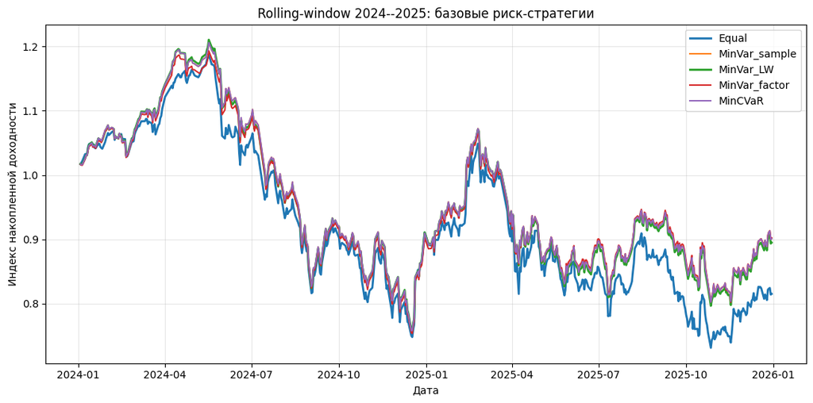

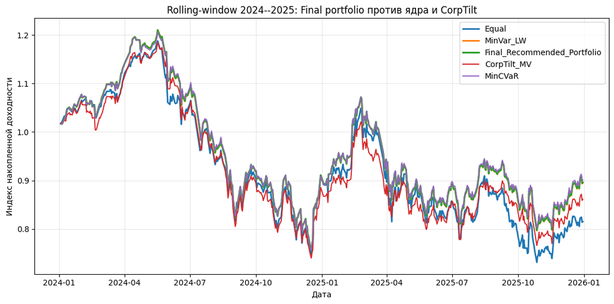

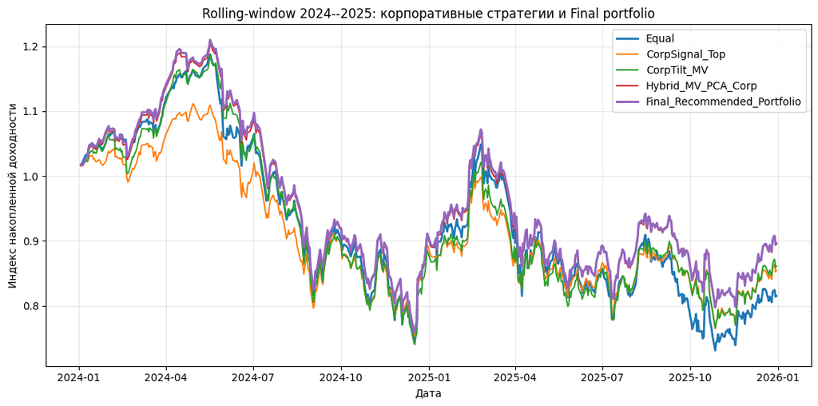

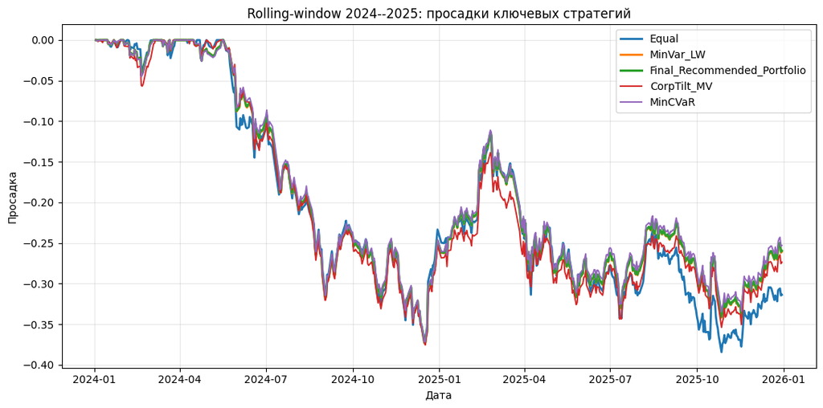

Rolling-window: сводка по окнам

| strategy | mean_sharpe | median_sharpe | mean_ann_return | mean_max_drawdown | windows |
| --- | --- | --- | --- | --- | --- |
| MinVar_LW | 0.751 | -0.134 | 5.51% | -11.94% | 9 |
| Final_Recommended_Portfolio | 0.751 | -0.136 | 5.55% | -11.93% | 9 |
| MinCVaR | 0.747 | -0.168 | 5.70% | -11.87% | 9 |
| MinVar_sample | 0.747 | -0.168 | 5.70% | -11.87% | 9 |
| MinVar_factor | 0.722 | -0.202 | 5.48% | -11.77% | 9 |
| Hybrid_MV_PCA_Corp | 0.712 | -0.154 | 5.25% | -11.87% | 9 |
| Ensemble_StatPriority | 0.669 | -0.169 | 4.92% | -11.77% | 9 |
| CorpTilt_MV | 0.511 | -0.225 | 3.02% | -12.08% | 9 |
| Equal | 0.425 | -0.108 | -0.39% | -12.12% | 9 |
| CorpSignal_Top | 0.258 | -0.140 | -0.56% | -11.16% | 9 |

```python
if not rolling_returns.empty:
    rr = rolling_returns.copy()
    if 'date' not in rr.columns:
        rr = rr.rename(columns={rr.columns[0]: 'date'})
    rr['date'] = pd.to_datetime(rr['date'])
    rolling_cum = rr.pivot_table(index='date', columns='strategy', values='return', aggfunc='sum').sort_index()
    rolling_cum = np.exp(rolling_cum.fillna(0).cumsum())
    rolling_cum.to_csv(OUTPUT_DIR / 'production_rolling_cumulative_2024_2025.csv', encoding='utf-8-sig')

    # Не строим все линии на одном графике: отдельно ядро, итоговый портфель и корпоративные стратегии.
    plot_cumulative_subset(
        rolling_cum,
        ['Equal', 'MinVar_sample', 'MinVar_LW', 'MinVar_factor', 'MinCVaR'],
        'Rolling-window 2024--2025: базовые риск-стратегии',
        'fig_production_rolling_core_risk_strategies_2024_2025.png'
    )
    plot_cumulative_subset(
        rolling_cum,
        ['Equal', 'MinVar_LW', FINAL_PORTFOLIO_NAME, 'CorpTilt_MV', 'MinCVaR'],
        'Rolling-window 2024--2025: Final portfolio против ядра и CorpTilt',
        'fig_production_rolling_final_vs_core_2024_2025.png'
    )
    plot_cumulative_subset(
        rolling_cum,
        ['Equal', 'CorpSignal_Top', 'CorpTilt_MV', 'Hybrid_MV_PCA_Corp', FINAL_PORTFOLIO_NAME],
        'Rolling-window 2024--2025: корпоративные стратегии и Final portfolio',
        'fig_production_rolling_corporate_strategies_2024_2025.png'
    )
    plot_drawdown_subset(
        rolling_cum,
        ['Equal', 'MinVar_LW', FINAL_PORTFOLIO_NAME, 'CorpTilt_MV', 'MinCVaR'],
        'Rolling-window 2024--2025: просадки ключевых стратегий',
        'fig_production_rolling_drawdowns_2024_2025.png'
    )

    if not rolling_metrics.empty:
        rolling_summary = rolling_metrics.groupby('strategy').agg(
            mean_sharpe=('sharpe', 'mean'),
            median_sharpe=('sharpe', 'median'),
            mean_ann_return=('ann_return', 'mean'),
            mean_max_drawdown=('max_drawdown', 'mean'),
            windows=('sharpe', 'count')
        ).sort_values('mean_sharpe', ascending=False)
        rolling_summary.to_csv(OUTPUT_DIR / 'production_rolling_strategy_summary_2024_2025.csv', encoding='utf-8-sig')
        display(Markdown('### Rolling-window: сводка по окнам'))
        display(rolling_summary.style.format({
            'mean_sharpe': '{:.3f}', 'median_sharpe': '{:.3f}',
            'mean_ann_return': '{:.2%}', 'mean_max_drawdown': '{:.2%}', 'windows': '{:.0f}'
        }))
else:
    print('Rolling-window не построен: USE_ROLLING_WINDOW = False или недостаточно наблюдений.')
```

### Интерпретация

Rolling-window проверка показывает более устойчивую роль риск-ядра. По средним метрикам `MinVar_LW` и `Final_Recommended_Portfolio` находятся в верхней части таблицы, а средняя годовая доходность равновесного портфеля остаётся около -0.39%.

Это поддерживает основную логику проекта: регулярное обновление ковариационной структуры и as-of корпоративного snapshot важно для режима, который ближе к практическому применению.

## 12. Автоматическая сборка чисел и формулировок для текста

Этот блок печатает компактные формулировки, которые можно перенести в текст курсовой после проверки. Они связывают результаты расчётов с экономической интерпретацией: размер выборки, параметры train/test, PCA-структуру, корпоративные веса и итоги статической и rolling-проверки.

Текст ниже лучше использовать как черновик. Если ноутбук пересчитывается, этот блок помогает обновить численные значения, но итоговые формулировки всё равно нужно сверять с таблицами выше.

```python
def pct(x):
    try:
        if pd.isna(x):
            return 'н/д'
        return f'{100 * float(x):.2f}%'
    except Exception:
        return 'н/д'


def num(x, digits=3):
    try:
        if pd.isna(x):
            return 'н/д'
        return f'{float(x):.{digits}f}'
    except Exception:
        return 'н/д'

lines = []
lines.append('В итоговой схеме MinVar_LW используется как риск-ядро, CorpTilt_MV рассматривается как отдельный кандидат, а Final_Recommended_Portfolio выбирается через multi-window validation внутри train.')
lines.append(f'После фильтра покрытия не ниже {COVERAGE_THRESHOLD:.0%} в рабочей выборке осталось {returns.shape[1]} бумаг из {len(CANDIDATE_TICKERS)} кандидатных тикеров.')
lines.append(f'Матрица цен закрытия имеет размер {close.shape[0]} x {close.shape[1]}, матрица лог-доходностей — {returns.shape[0]} x {returns.shape[1]}.')
lines.append(f'Основное обучающее окно: {TRAIN_START}--{TRAIN_END}, {train_returns.shape[0]} дневных наблюдений.')
lines.append(f'Основное проверочное окно: {TEST_START}--{TEST_END}, {test_returns.shape[0]} дневных наблюдений.')
lines.append(f'Статический портфель формируется на дату {PORTFOLIO_FORMATION_DATE}; корпоративные данные фильтруются строго по available_from <= decision date.')
lines.append(f'В PCA/МГК на обучающем окне выбрано K={K_FACTORS}; первые K компонент объясняют {pca_explained.loc[K_FACTORS-1, "cumulative_share"]:.2%} дисперсии.')
lines.append(f'Оценка Ledoit--Wolf дала shrinkage={lw_shrinkage:.3f}; факторная ковариация имеет относительную ошибку Фробениуса {err_factor:.3f} относительно выборочной матрицы.')

if not corp_panel_Z.empty:
    lines.append(f'Корпоративная панель Z, доступная на дату формирования, имеет размер {corp_panel_Z.shape[0]} наблюдений ticker-year x {corp_panel_Z.shape[1]} признаков. Доступные годы: {CORP_TRAIN_YEARS_AVAILABLE_MAIN}.')
else:
    lines.append('Корпоративная панель Z пуста; проверьте corporate_features_annual_2019_2024_asof.csv и available_from.')

if not Z.empty:
    if not corp_feature_weights.empty:
        top_feature = corp_feature_weights.index[0]
        top_weight = corp_feature_weights.iloc[0]['final_feature_weight']
        lines.append(f'As-of snapshot имеет размер {Z.shape[0]} компаний x {Z.shape[1]} признаков. Наибольший итоговый вес признака: {top_feature} ({pct(top_weight)}).')
    else:
        lines.append(f'As-of snapshot имеет размер {Z.shape[0]} компаний x {Z.shape[1]} признаков, но веса признаков не рассчитаны.')
else:
    lines.append('Snapshot Z пуст; корпоративные стратегии не интерпретируются.')

if not metrics_test_eff.empty:
    best_sharpe = metrics_test_eff['sharpe'].idxmax()
    best_eff = metrics_test_eff['efficiency_score_vs_Equal'].idxmax() if 'efficiency_score_vs_Equal' in metrics_test_eff.columns else best_sharpe
    lines.append(f'На static test 2024--2025 лучший Sharpe у стратегии {best_sharpe}: {num(metrics_test_eff.loc[best_sharpe, "sharpe"], 3)}.')
    if FINAL_PORTFOLIO_NAME in metrics_test_eff.index:
        f = metrics_test_eff.loc[FINAL_PORTFOLIO_NAME]
        lines.append(f'Итоговый Final_Recommended_Portfolio: Sharpe={num(f["sharpe"], 3)}, годовая доходность={pct(f["ann_return"])}, max drawdown={pct(f["max_drawdown"])}, нулевых весов={int(f["zero_weight_count"])}.')
        if 'final_selector_selected_mix_static_train_2019_2023' in globals() and not final_selector_selected_mix_static_train_2019_2023.empty:
            sm = final_selector_selected_mix_static_train_2019_2023.iloc[0]
            lines.append(f'Итоговый кандидат портфеля: {sm.get("selected_candidate", final_selector_selected_mix_static_train_2019_2023.index[0])}. Решение принято на multi-window validation внутри train, без доступа к test.')
    if 'sharpe_delta_vs_Equal' in metrics_test_eff.columns:
        lines.append(
            f'Интегрально наиболее эффективная стратегия относительно Equal: {best_eff}; '
            f'ΔSharpe={metrics_test_eff.loc[best_eff, "sharpe_delta_vs_Equal"]:+.3f}, '
            f'Δгодовой доходности={metrics_test_eff.loc[best_eff, "excess_ann_return_vs_Equal"]:+.2%}, '
            f'efficiency_score={metrics_test_eff.loc[best_eff, "efficiency_score_vs_Equal"]:.3f}.'
        )

if not ranking_metrics.empty:
    lines.append('ИПС-качество ранжирования оценено через HitRate@K и Return@K: top-K выдача сравнивается с медианной бумагой и равновесным universe.')

if 'corporate_feature_set_diagnostics' in globals() and isinstance(corporate_feature_set_diagnostics, pd.DataFrame) and not corporate_feature_set_diagnostics.empty:
    try:
        best_feat = corporate_feature_set_diagnostics.sort_values('delta_sharpe_vs_MinVar_LW', ascending=False).iloc[0]
        lines.append(f'Проверка корпоративных характеристик: лучший feature-set по ΔSharpe к MinVar_LW — {best_feat["feature_set"]}; использованные признаки: {best_feat["used_features"]}.')
    except Exception:
        pass

if not rolling_metrics.empty:
    rm_summary = rolling_metrics.groupby('strategy')['sharpe'].agg(['mean', 'median', 'count']).sort_values('mean', ascending=False)
    rolling_first = pd.to_datetime(rolling_metrics['test_start']).min().date()
    rolling_last = pd.to_datetime(rolling_metrics['test_end']).max().date()
    lines.append(f'Rolling-window проверка покрывает test-окна {rolling_first}--{rolling_last}; train и corporate as-of обновляются на каждом окне.')
    lines.append(f'В rolling-window проверке лучший средний Sharpe у {rm_summary.index[0]}: {rm_summary.iloc[0]["mean"]:.3f} по {int(rm_summary.iloc[0]["count"])} окнам.')

summary_text = '\n'.join(lines)
for line in lines:
    print(line)

(OUTPUT_DIR / 'technical_summary.txt').write_text(summary_text, encoding='utf-8')
```

```
В итоговой схеме MinVar_LW используется как риск-ядро, CorpTilt_MV рассматривается как отдельный кандидат, а Final_Recommended_Portfolio выбирается через multi-window validation внутри train.
После фильтра покрытия не ниже 95% в рабочей выборке осталось 25 бумаг из 25 кандидатных тикеров.
Матрица цен закрытия имеет размер 1777 x 25, матрица лог-доходностей — 1776 x 25.
Основное обучающее окно: 2019-01-03--2023-12-29, 1226 дневных наблюдений.
Основное проверочное окно: 2024-01-03--2025-12-30, 550 дневных наблюдений.
Статический портфель формируется на дату 2024-01-03; корпоративные данные фильтруются строго по available_from <= decision date.
В PCA/МГК на обучающем окне выбрано K=6; первые K компонент объясняют 71.29% дисперсии.
Оценка Ledoit--Wolf дала shrinkage=0.100; факторная ковариация имеет относительную ошибку Фробениуса 0.064 относительно выборочной матрицы.
Корпоративная панель Z, доступная на дату формирования, имеет размер 100 наблюдений ticker-year x 7 признаков. Доступные годы: [2019, 2020, 2021, 2022].
As-of snapshot имеет размер 25 компаний x 7 признаков. Наибольший итоговый вес признака: pb (20.99%).
На static test 2024--2025 лучший Sharpe у стратегии CorpTilt_MV: -0.006.
Итоговый Final_Recommended_Portfolio: Sharpe=-0.176, годовая доходность=-4.00%, max drawdown=-37.10%, нулевых весов=11.
Итоговый кандидат портфеля: LW85_CVaR15. Решение принято на multi-window validation внутри train, без доступа к test.
Интегрально наиболее эффективная стратегия относительно Equal: CorpTilt_MV; ΔSharpe=+0.370, Δгодовой доходности=+8.81%, efficiency_score=0.865.
ИПС-качество ранжирования оценено через HitRate@K и Return@K: top-K выдача сравнивается с медианной бумагой и равновесным universe.
Проверка корпоративных характеристик: лучший feature-set по ΔSharpe к MinVar_LW — base_7_without_debt_equity; использованные признаки: log_market_cap, pe, pb, roe, netdebt_ebitda, dividend_yield, free_float.
Rolling-window проверка покрывает test-окна 2024-01-03--2025-12-30; train и corporate as-of обновляются на каждом окне.
В rolling-window проверке лучший средний Sharpe у MinVar_LW: 0.751 по 9 окнам.
```

```
2126
```

## 13. Что должно попасть в финальный текст

Минимальный набор артефактов из этого ноутбука:

- `data_summary.csv` — размер выборки и разбиение `train 2019--2023 / test 2024--2025`;
- `coverage_by_ticker.csv` — список бумаг после фильтра покрытия;
- `descriptive_stats_all.csv` — первичная статистика доходностей;
- `correlation_summary.csv`, `correlation_train.csv` — корреляционная структура;
- `pca_explained_train.csv`, `factor_loadings_B_train.csv` — рыночная PCA/МГК и факторные нагрузки;
- `covariance_estimators_summary.csv` — сравнение sample, PCA-factor и Ledoit--Wolf ковариаций;
- `corporate_features_annual_loaded_asof.csv` — annual-таблица корпоративных характеристик с датами доступности;
- `corporate_missing_cells_asof.csv`, `corporate_missing_by_column_asof.csv` — контроль пропусков в корпоративных данных;
- `corporate_Z_panel_standardized_available_at_static_formation.csv` — корпоративная панель, доступная на дату статического формирования;
- `corporate_Z_snapshot_asof_<date>.csv` — snapshot корпоративных признаков на дату формирования портфеля;
- `corporate_feature_weights_final.csv` — веса корпоративных признаков по Ridge, PCA и устойчивости;
- `portfolio_weights_static_train_2019_2023.csv` — веса статических стратегий, включая `Final_Recommended_Portfolio`;
- `final_selector_validation_candidates_static_train_2019_2023.csv`, `final_selector_selected_mix_static_train_2019_2023.csv` — результаты внутренней validation-процедуры;
- `portfolio_metrics_test_2024_2025_static.csv`, `portfolio_efficiency_vs_equal_test_2024_2025_static.csv` — static out-of-sample;
- `ranking_quality_at_k_2024_2025_static.csv` — ИПС-метрики `HitRate@K` и `Return@K`;
- `production_rolling_returns_2024_2025.csv`, `production_rolling_metrics_2024_2025.csv`, `production_rolling_weights_2024_2025.csv` — результаты rolling-режима;
- `technical_summary.txt` — автоматически собранные численные формулировки для текста.

Итоговая логика работы такая: ИПС для акций MOEX соединяет риск-ядро, корпоративную релевантность и validation-процедуру. Статический test 2024--2025 показывает поведение портфеля при фиксированных весах, а rolling-window проверка показывает эффект регулярного обновления ковариационной структуры и корпоративного snapshot. Эти два режима лучше обсуждать отдельно.